# RWE MIBC Clinical analysis_Final Output 01232024

library(swimplot) library(grid) library(gtable) library(readr) library(mosaic) library(dplyr) library(survival) library(survminer) library(ggplot2) library(scales) library(coxphf) library(ggthemes) library(tidyverse) library(gtsummary) library(flextable) library(parameters) library(car) library(ComplexHeatmap) library(tidyverse) library(readxl) library(survival) library(janitor) library(DT) library(rms)

#ctDNA positivity by stage and window

```r
#Number of Pts at the pre-cystectomy - percentage positivity by stage
rm(list=ls())
setwd("~/Downloads")
circ_data <- read.csv("RWE_MIBC Combined.csv")
circ_datadf <- as.data.frame(circ_data)
circ_data <- circ_data[circ_data$ctDNA.Available=="TRUE",]
circ_data <- circ_data[circ_data$FU_months>=3,]
circ_data <- subset(circ_data, !is.na(MRD_anytimepreSx))
circ_datadf <- as.data.frame(circ_data)

total_preop <- sum(!is.na(circ_data$MRD_anytimepreSx))
print(total_preop)
```

```
[1] 65
```

```r
circ_data$MRD_anytimepreSx <- as.factor(circ_data$MRD_anytimepreSx)
cont_table_preop <- table(circ_data$cStage.Group, circ_data$MRD_anytimepreSx)
print(cont_table_preop)
```

```
     0  1
  1  5  3
  2 25 11
  3  9 12
```

```r
#Positivity Statistics for pre-cystectomy timepoints
rm(list=ls())
setwd("~/Downloads")
circ_data <- read.csv("RWE_MIBC Combined.csv")
circ_data <- circ_data[circ_data$ctDNA.Available=="TRUE",]
circ_data <- circ_data[circ_data$FU_months>=3,]
circ_data <- subset(circ_data, !is.na(MRD_anytimepreSx))
circ_data$MRD_anytimepreSx <- factor(circ_data$MRD_anytimepreSx, levels = c("0", "1"), labels = c("ctDNA(-)", "ctDNA(+)"))
circ_data$cStage.Group <- factor(circ_data$cStage.Group, levels = c("1", "2", "3"), labels = c("CIS/I", "II", "III"))
contingency_table <- table(circ_data$MRD_anytimepreSx, circ_data$cStage.Group)
chi_square_test <- chisq.test(contingency_table)
print(chi_square_test)
```

```
    Pearson's Chi-squared test

data:  contingency_table
X-squared = 3.9302, df = 2, p-value = 0.1401
```

```r
fisher_exact_test <- fisher.test(contingency_table)
print(fisher_exact_test)
```

```
    Fisher's Exact Test for Count Data

data:  contingency_table
p-value = 0.1313
alternative hypothesis: two.sided
```

```r
print(contingency_table)
```

```
           CIS/I II III
  ctDNA(-)     5 25   9
  ctDNA(+)     3 11  12
```

```r
table_df <- as.data.frame(contingency_table)
table_df$Total <- ave(table_df$Freq, table_df$Var1, FUN = sum)
table_df$Percentage <- table_df$Freq / table_df$Total
table_df$MiddlePercentage <- table_df$Percentage / 2
ggplot(table_df, aes(x = Var1, y = Percentage, fill = Var2)) +
  geom_bar(stat = "identity") +
  geom_text(aes(y = MiddlePercentage, label = Freq), position = "stack", color = "black", vjust = 1.5, size = 7) +
  theme_minimal() +
  labs(title = "ctDNA pre-RC (n = 65)", x = "ctDNA", y = "Patients (%)", fill = "Stage") +
  scale_y_continuous(labels = scales::percent_format()) +
  scale_fill_manual(values = c("CIS/I" = "lightblue3", "II" = "orange", "III" = "red")) + # define custom colors
  theme(axis.text.x = element_text(angle = 0, hjust = 1.5, size = 14), # increase x-axis text size
        axis.text.y = element_text(size = 14, color = "black"), # increase y-axis text size
        axis.title.x = element_text(size = 14, color = "black"), # increase x-axis label size
        axis.title.y = element_text(size = 14, color = "black"), # increase y-axis label size
        legend.text = element_text(size = 12, color = "black"))  # increase Recurrence label size

rm(list=ls())
setwd("~/Downloads")
circ_data <- read.csv("RWE_MIBC Combined.csv")
circ_data <- circ_data[circ_data$ctDNA.Available=="TRUE",]
circ_data <- circ_data[circ_data$FU_months>=3,]
circ_data <- subset(circ_data, !is.na(MRD_anytimepreSx))
circ_data$MRD_anytimepreSx <- factor(circ_data$MRD_anytimepreSx, levels = c("0", "1"), labels = c("ctDNA(-)", "ctDNA(+)"))
circ_data$cStage.Group <- factor(circ_data$cStage.Group, levels = c("1", "2", "3"), labels = c("CIS/I", "II", "III"))
contingency_table <- table(circ_data$cStage.Group, circ_data$MRD_anytimepreSx)
chi_square_test <- chisq.test(contingency_table)
print(chi_square_test)
```

```
    Pearson's Chi-squared test

data:  contingency_table
X-squared = 3.9302, df = 2, p-value = 0.1401
```

```r
fisher_exact_test <- fisher.test(contingency_table)
print(fisher_exact_test)
```

```
    Fisher's Exact Test for Count Data

data:  contingency_table
p-value = 0.1313
alternative hypothesis: two.sided
```

```r
print(contingency_table)
```

```
        ctDNA(-) ctDNA(+)
  CIS/I        5        3
  II          25       11
  III          9       12
```

```r
table_df <- as.data.frame(contingency_table)
table_df$Total <- ave(table_df$Freq, table_df$Var1, FUN = sum)
table_df$Percentage <- table_df$Freq / table_df$Total
table_df$MiddlePercentage <- table_df$Percentage / 2
ggplot(table_df, aes(x = Var1, y = Percentage, fill = Var2)) +
  geom_bar(stat = "identity") +
  geom_text(aes(y = MiddlePercentage, label = Freq), position = "stack", color = "black", vjust = 1.5, size = 7) +
  theme_minimal() +
  labs(title = "ctDNA pre-RC (n = 65)", x = "ctDNA", y = "Patients (%)", fill = "Stage") +
  scale_y_continuous(labels = scales::percent_format()) +
  scale_fill_manual(values = c("ctDNA(-)" = "lightblue3", "ctDNA(+)" = "red")) + # define custom colors
  theme(axis.text.x = element_text(angle = 0, hjust = 1.5, size = 14), # increase x-axis text size
        axis.text.y = element_text(size = 14, color = "black"), # increase y-axis text size
        axis.title.x = element_text(size = 14, color = "black"), # increase x-axis label size
        axis.title.y = element_text(size = 14, color = "black"), # increase y-axis label size
        legend.text = element_text(size = 12, color = "black"))  # increase Recurrence label size
```

```r
rm(list=ls())
setwd("~/Downloads")
circ_data <- read.csv("RWE_MIBC Combined.csv")
circ_data <- circ_data[circ_data$ctDNA.Available=="TRUE",]
circ_data <- circ_data[circ_data$FU_months>=3,]
circ_data <- subset(circ_data, !is.na(MRD_anytimepreSx))
circ_data <- circ_data[circ_data$cStage.Group!="3",]
circ_data$MRD_anytimepreSx <- factor(circ_data$MRD_anytimepreSx, levels = c("0", "1"), labels = c("ctDNA(-)", "ctDNA(+)"))
circ_data$cStage.Group <- factor(circ_data$cStage.Group, levels = c("1", "2"), labels = c("CIS/I", "II"))
contingency_table <- table(circ_data$cStage.Group, circ_data$MRD_anytimepreSx)
chi_square_test <- chisq.test(contingency_table)
print(chi_square_test)
```

```
    Pearson's Chi-squared test with Yates' continuity correction

data:  contingency_table
X-squared = 1.1174e-30, df = 1, p-value = 1
```

```r
fisher_exact_test <- fisher.test(contingency_table)
print(fisher_exact_test)
```

```
    Fisher's Exact Test for Count Data

data:  contingency_table
p-value = 0.6951
alternative hypothesis: true odds ratio is not equal to 1
95 percent confidence interval:
 0.117753 5.600272
sample estimates:
odds ratio
 0.7386822
```

```r
print(contingency_table)
```

```
        ctDNA(-) ctDNA(+)
  CIS/I        5        3
  II          25       11
```

```r
rm(list=ls())
setwd("~/Downloads")
circ_data <- read.csv("RWE_MIBC Combined.csv")
circ_data <- circ_data[circ_data$ctDNA.Available=="TRUE",]
circ_data <- circ_data[circ_data$FU_months>=3,]
circ_data <- subset(circ_data, !is.na(MRD_anytimepreSx))
circ_data <- circ_data[circ_data$cStage.Group!="2",]
circ_data$MRD_anytimepreSx <- factor(circ_data$MRD_anytimepreSx, levels = c("0", "1"), labels = c("ctDNA(-)", "ctDNA(+)"))
circ_data$cStage.Group <- factor(circ_data$cStage.Group, levels = c("1", "3"), labels = c("CIS/I", "III"))
contingency_table <- table(circ_data$cStage.Group, circ_data$MRD_anytimepreSx)
chi_square_test <- chisq.test(contingency_table)
print(chi_square_test)
```

```
    Pearson's Chi-squared test with Yates' continuity correction

data:  contingency_table
X-squared = 0.28133, df = 1, p-value = 0.5958
```

```r
fisher_exact_test <- fisher.test(contingency_table)
print(fisher_exact_test)
```

```
    Fisher's Exact Test for Count Data

data:  contingency_table
p-value = 0.427
alternative hypothesis: true odds ratio is not equal to 1
95 percent confidence interval:
  0.3191459 17.7561178
sample estimates:
odds ratio
  2.160962
```

```r
print(contingency_table)
```

```
        ctDNA(-) ctDNA(+)
  CIS/I        5        3
  III          9       12
```

```r
rm(list=ls())
setwd("~/Downloads")
circ_data <- read.csv("RWE_MIBC Combined.csv")
circ_data <- circ_data[circ_data$ctDNA.Available=="TRUE",]
circ_data <- circ_data[circ_data$FU_months>=3,]
circ_data <- subset(circ_data, !is.na(MRD_anytimepreSx))
circ_data <- circ_data[circ_data$cStage.Group!="1",]
circ_data$MRD_anytimepreSx <- factor(circ_data$MRD_anytimepreSx, levels = c("0", "1"), labels = c("ctDNA(-)", "ctDNA(+)"))
circ_data$cStage.Group <- factor(circ_data$cStage.Group, levels = c("2", "3"), labels = c("II", "III"))
contingency_table <- table(circ_data$cStage.Group, circ_data$MRD_anytimepreSx)
chi_square_test <- chisq.test(contingency_table)
print(chi_square_test)
```

```
    Pearson's Chi-squared test with Yates' continuity correction

data:  contingency_table
X-squared = 2.869, df = 1, p-value = 0.0903
```

```r
fisher_exact_test <- fisher.test(contingency_table)
print(fisher_exact_test)
```

```
    Fisher's Exact Test for Count Data

data:  contingency_table
p-value = 0.05716
alternative hypothesis: true odds ratio is not equal to 1
95 percent confidence interval:
  0.8635405 10.7479707
sample estimates:
odds ratio
  2.967902
```

```r
print(contingency_table)
```

```
      ctDNA(-) ctDNA(+)
  II        25       11
  III        9       12
```

```r
#Number of Pts at the MRD Window - percentage positivity by stage
rm(list=ls())
setwd("~/Downloads")
circ_data <- read.csv("RWE_MIBC Combined.csv")
circ_datadf <- as.data.frame(circ_data)
circ_data <- circ_data[circ_data$ctDNA.Available=="TRUE",]
circ_data <- circ_data[circ_data$FU_months>=3,]
circ_data <- subset(circ_data, !is.na(MRD_postSx.MRD.Window))
circ_datadf <- as.data.frame(circ_data)

total_mrd <- sum(!is.na(circ_data$MRD_postSx.MRD.Window))
print(total_mrd)
```

```
[1] 100
```

```r
circ_data$MRD_postSx.MRD.Window <- as.factor(circ_data$MRD_postSx.MRD.Window)
cont_table_mrd <- table(circ_data$pStage.Group, circ_data$MRD_postSx.MRD.Window)
print(cont_table_mrd)
```

```
     0  1
  1 29  1
  2 14  1
  3 33 22
```

```r
#Positivity Statistics for MRD Window timepoints
rm(list=ls())
setwd("~/Downloads")
circ_data <- read.csv("RWE_MIBC Combined.csv")
circ_data <- circ_data[circ_data$ctDNA.Available=="TRUE",]
circ_data <- circ_data[circ_data$FU_months>=3,]
circ_data <- subset(circ_data, !is.na(MRD_postSx.MRD.Window))
circ_data$MRD_postSx.MRD.Window <- factor(circ_data$MRD_postSx.MRD.Window, levels = c("0", "1"), labels = c("ctDNA(-)", "ctDNA(+)"))
circ_data$pStage.Group <- factor(circ_data$pStage.Group, levels = c("1", "2", "3"), labels = c("CIS/I", "II", "III"))
contingency_table <- table(circ_data$MRD_postSx.MRD.Window, circ_data$pStage.Group)
chi_square_test <- chisq.test(contingency_table)
print(chi_square_test)
```

```
    Pearson's Chi-squared test

data:  contingency_table
X-squared = 17.215, df = 2, p-value = 0.0001827
```

```r
fisher_exact_test <- fisher.test(contingency_table)
print(fisher_exact_test)
```

```
    Fisher's Exact Test for Count Data

data:  contingency_table
p-value = 0.0001005
alternative hypothesis: two.sided
```

```r
print(contingency_table)
```

```
           CIS/I II III
  ctDNA(-)    29 14  33
  ctDNA(+)     1  1  22
```

```r
table_df <- as.data.frame(contingency_table)
table_df$Total <- ave(table_df$Freq, table_df$Var1, FUN = sum)
table_df$Percentage <- table_df$Freq / table_df$Total
table_df$MiddlePercentage <- table_df$Percentage / 2
ggplot(table_df, aes(x = Var1, y = Percentage, fill = Var2)) +
  geom_bar(stat = "identity") +
  geom_text(aes(y = MiddlePercentage, label = Freq), position = "stack", color = "black", vjust = 1.5, size = 7) +
  theme_minimal() +
  labs(title = "ctDNA MRD Window (n = 100)", x = "ctDNA", y = "Patients (%)", fill = "Stage") +
  scale_y_continuous(labels = scales::percent_format()) +
  scale_fill_manual(values = c("CIS/I" = "lightblue3", "II" = "orange", "III" = "red")) + # define custom colors
  theme(axis.text.x = element_text(angle = 0, hjust = 1.5, size = 14), # increase x-axis text size
        axis.text.y = element_text(size = 14, color = "black"), # increase y-axis text size
        axis.title.x = element_text(size = 14, color = "black"), # increase x-axis label size
        axis.title.y = element_text(size = 14, color = "black"), # increase y-axis label size
        legend.text = element_text(size = 12, color = "black"))  # increase Recurrence label size

rm(list=ls())
setwd("~/Downloads")
circ_data <- read.csv("RWE_MIBC Combined.csv")
circ_data <- circ_data[circ_data$ctDNA.Available=="TRUE",]
circ_data <- circ_data[circ_data$FU_months>=3,]
circ_data <- subset(circ_data, !is.na(MRD_postSx.MRD.Window))
circ_data$MRD_postSx.MRD.Window <- factor(circ_data$MRD_postSx.MRD.Window, levels = c("0", "1"), labels = c("ctDNA(-)", "ctDNA(+)"))
circ_data$pStage.Group <- factor(circ_data$pStage.Group, levels = c("1", "2", "3"), labels = c("CIS/I", "II", "III"))
contingency_table <- table(circ_data$pStage.Group, circ_data$MRD_postSx.MRD.Window)
chi_square_test <- chisq.test(contingency_table)
print(chi_square_test)
```

```
    Pearson's Chi-squared test

data:  contingency_table
X-squared = 17.215, df = 2, p-value = 0.0001827
```

```r
fisher_exact_test <- fisher.test(contingency_table)
print(fisher_exact_test)
```

```
    Fisher's Exact Test for Count Data

data:  contingency_table
p-value = 0.0001005
alternative hypothesis: two.sided
```

```r
print(contingency_table)
```

```
        ctDNA(-) ctDNA(+)
  CIS/I       29        1
  II          14        1
  III         33       22
```

```r
table_df <- as.data.frame(contingency_table)
table_df$Total <- ave(table_df$Freq, table_df$Var1, FUN = sum)
table_df$Percentage <- table_df$Freq / table_df$Total
table_df$MiddlePercentage <- table_df$Percentage / 2
ggplot(table_df, aes(x = Var1, y = Percentage, fill = Var2)) +
  geom_bar(stat = "identity") +
  geom_text(aes(y = MiddlePercentage, label = Freq), position = "stack", color = "black", vjust = 1.5, size = 7) +
  theme_minimal() +
  labs(title = "ctDNA MRD Window (n = 100)", x = "ctDNA", y = "Patients (%)", fill = "Stage") +
  scale_y_continuous(labels = scales::percent_format()) +
  scale_fill_manual(values = c("ctDNA(-)" = "lightblue3", "ctDNA(+)" = "red")) + # define custom colors
  theme(axis.text.x = element_text(angle = 0, hjust = 1.5, size = 14), # increase x-axis text size
        axis.text.y = element_text(size = 14, color = "black"), # increase y-axis text size
        axis.title.x = element_text(size = 14, color = "black"), # increase x-axis label size
        axis.title.y = element_text(size = 14, color = "black"), # increase y-axis label size
        legend.text = element_text(size = 12, color = "black"))  # increase Recurrence label size
```

```r
rm(list=ls())
setwd("~/Downloads")
circ_data <- read.csv("RWE_MIBC Combined.csv")
circ_data <- circ_data[circ_data$ctDNA.Available=="TRUE",]
circ_data <- circ_data[circ_data$FU_months>=3,]
circ_data <- subset(circ_data, !is.na(MRD_postSx.MRD.Window))
circ_data <- circ_data[circ_data$pStage.Group!="3",]
circ_data$MRD_postSx.MRD.Window <- factor(circ_data$MRD_postSx.MRD.Window, levels = c("0", "1"), labels = c("ctDNA(-)", "ctDNA(+)"))
circ_data$pStage.Group <- factor(circ_data$pStage.Group, levels = c("1", "2"), labels = c("CIS/I", "II"))
contingency_table <- table(circ_data$pStage.Group, circ_data$MRD_postSx.MRD.Window)
chi_square_test <- chisq.test(contingency_table)
print(chi_square_test)
```

```
    Pearson's Chi-squared test with Yates' continuity correction

data:  contingency_table
X-squared = 3.3818e-30, df = 1, p-value = 1
```

```r
fisher_exact_test <- fisher.test(contingency_table)
print(fisher_exact_test)
```

```
    Fisher's Exact Test for Count Data

data:  contingency_table
p-value = 1
alternative hypothesis: true odds ratio is not equal to 1
95 percent confidence interval:
   0.02464448 167.86812329
sample estimates:
odds ratio
  2.035455
```

```r
print(contingency_table)
```

```
        ctDNA(-) ctDNA(+)
  CIS/I       29        1
  II          14        1
```

```r
rm(list=ls())
setwd("~/Downloads")
circ_data <- read.csv("RWE_MIBC Combined.csv")
circ_data <- circ_data[circ_data$ctDNA.Available=="TRUE",]
circ_data <- circ_data[circ_data$FU_months>=3,]
circ_data <- subset(circ_data, !is.na(MRD_postSx.MRD.Window))
circ_data <- circ_data[circ_data$pStage.Group!="2",]
circ_data$MRD_postSx.MRD.Window <- factor(circ_data$MRD_postSx.MRD.Window, levels = c("0", "1"), labels = c("ctDNA(-)", "ctDNA(+)"))
circ_data$pStage.Group <- factor(circ_data$pStage.Group, levels = c("1", "3"), labels = c("CIS/I", "III"))
contingency_table <- table(circ_data$pStage.Group, circ_data$MRD_postSx.MRD.Window)
chi_square_test <- chisq.test(contingency_table)
print(chi_square_test)
```

```
    Pearson's Chi-squared test with Yates' continuity correction

data:  contingency_table
X-squared = 11.43, df = 1, p-value = 0.0007225
```

```r
fisher_exact_test <- fisher.test(contingency_table)
print(fisher_exact_test)
```

```
    Fisher's Exact Test for Count Data

data:  contingency_table
p-value = 0.0002143
alternative hypothesis: true odds ratio is not equal to 1
95 percent confidence interval:
   2.704127 821.464608
sample estimates:
odds ratio
  18.84432
```

```r
print(contingency_table)
```

```
        ctDNA(-) ctDNA(+)
  CIS/I       29        1
  III         33       22
```

```r
rm(list=ls())
setwd("~/Downloads")
circ_data <- read.csv("RWE_MIBC Combined.csv")
circ_data <- circ_data[circ_data$ctDNA.Available=="TRUE",]
circ_data <- circ_data[circ_data$FU_months>=3,]
circ_data <- subset(circ_data, !is.na(MRD_postSx.MRD.Window))
circ_data <- circ_data[circ_data$pStage.Group!="1",]
circ_data$MRD_postSx.MRD.Window <- factor(circ_data$MRD_postSx.MRD.Window, levels = c("0", "1"), labels = c("ctDNA(-)", "ctDNA(+)"))
circ_data$pStage.Group <- factor(circ_data$pStage.Group, levels = c("2", "3"), labels = c("II", "III"))
contingency_table <- table(circ_data$pStage.Group, circ_data$MRD_postSx.MRD.Window)
chi_square_test <- chisq.test(contingency_table)
print(chi_square_test)
```

```
    Pearson's Chi-squared test with Yates' continuity correction

data:  contingency_table
X-squared = 4.5211, df = 1, p-value = 0.03348
```

```r
fisher_exact_test <- fisher.test(contingency_table)
print(fisher_exact_test)
```

```
    Fisher's Exact Test for Count Data

data:  contingency_table
p-value = 0.01473
alternative hypothesis: true odds ratio is not equal to 1
95 percent confidence interval:
   1.216804 411.429288
sample estimates:
odds ratio
  9.117509
```

```r
print(contingency_table)
```

```
      ctDNA(-) ctDNA(+)
  II        14        1
  III       33       22
```

```r
#Number of Pts at the Surveillance Window - percentage positivity by stage
rm(list=ls())
setwd("~/Downloads")
circ_data <- read.csv("RWE_MIBC Combined.csv")
circ_datadf <- as.data.frame(circ_data)
circ_data <- circ_data[circ_data$ctDNA.Available=="TRUE",]
circ_data <- circ_data[circ_data$FU_months>=3,]
circ_data <- subset(circ_data, !is.na(MRD.Surveillance.Window))
circ_datadf <- as.data.frame(circ_data)

total_surv <- sum(!is.na(circ_data$MRD.Surveillance.Window))
print(total_surv)
```

```
[1] 117
```

```r
circ_data$MRD.Surveillance.Window <- as.factor(circ_data$MRD.Surveillance.Window)
cont_table_surv <- table(circ_data$pStage.Group, circ_data$MRD.Surveillance.Window)
print(cont_table_surv)
```

```
     0  1
  1 24  4
  2  9  6
  3 32 42
```

```r
#Positivity Statistics for Surveillance Window timepoints
rm(list=ls())
setwd("~/Downloads")
circ_data <- read.csv("RWE_MIBC Combined.csv")
circ_data <- circ_data[circ_data$ctDNA.Available=="TRUE",]
circ_data <- circ_data[circ_data$FU_months>=3,]
circ_data <- subset(circ_data, !is.na(MRD.Surveillance.Window))
circ_data$MRD.Surveillance.Window <- factor(circ_data$MRD.Surveillance.Window, levels = c("0", "1"), labels = c("ctDNA(-)", "ctDNA(+)"))
circ_data$pStage.Group <- factor(circ_data$pStage.Group, levels = c("1", "2", "3"), labels = c("CIS/I", "II", "III"))
contingency_table <- table(circ_data$MRD.Surveillance.Window, circ_data$pStage.Group)
chi_square_test <- chisq.test(contingency_table)
print(chi_square_test)
```

```
    Pearson's Chi-squared test

data:  contingency_table
X-squared = 14.978, df = 2, p-value = 0.0005593
```

```r
fisher_exact_test <- fisher.test(contingency_table)
print(fisher_exact_test)
```

```
    Fisher's Exact Test for Count Data

data:  contingency_table
p-value = 0.0003337
alternative hypothesis: two.sided
```

```r
print(contingency_table)
```

```
           CIS/I II III
  ctDNA(-)    24  9  32
  ctDNA(+)     4  6  42
```

```r
table_df <- as.data.frame(contingency_table)
table_df$Total <- ave(table_df$Freq, table_df$Var1, FUN = sum)
table_df$Percentage <- table_df$Freq / table_df$Total
table_df$MiddlePercentage <- table_df$Percentage / 2
ggplot(table_df, aes(x = Var1, y = Percentage, fill = Var2)) +
  geom_bar(stat = "identity") +
  geom_text(aes(y = MiddlePercentage, label = Freq), position = "stack", color = "black", vjust = 1.5, size = 7) +
  theme_minimal() +
  labs(title = "ctDNA Surveillance Window (n = 117)", x = "ctDNA", y = "Patients (%)", fill = "Stage") +
  scale_y_continuous(labels = scales::percent_format()) +
  scale_fill_manual(values = c("CIS/I" = "lightblue3", "II" = "orange", "III" = "red")) + # define custom colors
  theme(axis.text.x = element_text(angle = 0, hjust = 1.5, size = 14), # increase x-axis text size
        axis.text.y = element_text(size = 14, color = "black"), # increase y-axis text size
        axis.title.x = element_text(size = 14, color = "black"), # increase x-axis label size
        axis.title.y = element_text(size = 14, color = "black"), # increase y-axis label size
        legend.text = element_text(size = 12, color = "black"))  # increase Recurrence label size

rm(list=ls())
setwd("~/Downloads")
circ_data <- read.csv("RWE_MIBC Combined.csv")
circ_data <- circ_data[circ_data$ctDNA.Available=="TRUE",]
circ_data <- circ_data[circ_data$FU_months>=3,]
circ_data <- subset(circ_data, !is.na(MRD.Surveillance.Window))
circ_data$MRD.Surveillance.Window <- factor(circ_data$MRD.Surveillance.Window, levels = c("0", "1"), labels = c("ctDNA(-)", "ctDNA(+)"))
circ_data$pStage.Group <- factor(circ_data$pStage.Group, levels = c("1", "2", "3"), labels = c("CIS/I", "II", "III"))
contingency_table <- table(circ_data$pStage.Group, circ_data$MRD.Surveillance.Window)
chi_square_test <- chisq.test(contingency_table)
print(chi_square_test)
```

```
    Pearson's Chi-squared test

data:  contingency_table
X-squared = 14.978, df = 2, p-value = 0.0005593
```

```r
fisher_exact_test <- fisher.test(contingency_table)
print(fisher_exact_test)
```

```
    Fisher's Exact Test for Count Data

data:  contingency_table
p-value = 0.0003337
alternative hypothesis: two.sided
```

```r
print(contingency_table)
```

```
        ctDNA(-) ctDNA(+)
  CIS/I       24        4
  II           9        6
  III         32       42
```

```r
table_df <- as.data.frame(contingency_table)
table_df$Total <- ave(table_df$Freq, table_df$Var1, FUN = sum)
table_df$Percentage <- table_df$Freq / table_df$Total
table_df$MiddlePercentage <- table_df$Percentage / 2
ggplot(table_df, aes(x = Var1, y = Percentage, fill = Var2)) +
  geom_bar(stat = "identity") +
  geom_text(aes(y = MiddlePercentage, label = Freq), position = "stack", color = "black", vjust = 1.5, size = 7) +
  theme_minimal() +
  labs(title = "ctDNA Surveillance Window (n = 117)", x = "ctDNA", y = "Patients (%)", fill = "Stage") +
  scale_y_continuous(labels = scales::percent_format()) +
  scale_fill_manual(values = c("ctDNA(-)" = "lightblue3", "ctDNA(+)" = "red")) + # define custom colors
  theme(axis.text.x = element_text(angle = 0, hjust = 1.5, size = 14), # increase x-axis text size
        axis.text.y = element_text(size = 14, color = "black"), # increase y-axis text size
        axis.title.x = element_text(size = 14, color = "black"), # increase x-axis label size
        axis.title.y = element_text(size = 14, color = "black"), # increase y-axis label size
        legend.text = element_text(size = 12, color = "black"))  # increase Recurrence label size
```

```r
rm(list=ls())
setwd("~/Downloads")
circ_data <- read.csv("RWE_MIBC Combined.csv")
circ_data <- circ_data[circ_data$ctDNA.Available=="TRUE",]
circ_data <- circ_data[circ_data$FU_months>=3,]
circ_data <- subset(circ_data, !is.na(MRD.Surveillance.Window))
circ_data <- circ_data[circ_data$pStage.Group!="3",]
circ_data$MRD.Surveillance.Window <- factor(circ_data$MRD.Surveillance.Window, levels = c("0", "1"), labels = c("ctDNA(-)", "ctDNA(+)"))
circ_data$pStage.Group <- factor(circ_data$pStage.Group, levels = c("1", "2"), labels = c("CIS/I", "II"))
contingency_table <- table(circ_data$pStage.Group, circ_data$MRD.Surveillance.Window)
chi_square_test <- chisq.test(contingency_table)
print(chi_square_test)
```

```
    Pearson's Chi-squared test with Yates' continuity correction

data:  contingency_table
X-squared = 2.3213, df = 1, p-value = 0.1276
```

```r
fisher_exact_test <- fisher.test(contingency_table)
print(fisher_exact_test)
```

```
    Fisher's Exact Test for Count Data

data:  contingency_table
p-value = 0.07263
alternative hypothesis: true odds ratio is not equal to 1
95 percent confidence interval:
  0.7223043 23.4097242
sample estimates:
odds ratio
  3.856114
```

```r
print(contingency_table)
```

```
        ctDNA(-) ctDNA(+)
  CIS/I       24        4
  II           9        6
```

```r
rm(list=ls())
setwd("~/Downloads")
circ_data <- read.csv("RWE_MIBC Combined.csv")
circ_data <- circ_data[circ_data$ctDNA.Available=="TRUE",]
circ_data <- circ_data[circ_data$FU_months>=3,]
circ_data <- subset(circ_data, !is.na(MRD.Surveillance.Window))
circ_data <- circ_data[circ_data$pStage.Group!="2",]
circ_data$MRD.Surveillance.Window <- factor(circ_data$MRD.Surveillance.Window, levels = c("0", "1"), labels = c("ctDNA(-)", "ctDNA(+)"))
circ_data$pStage.Group <- factor(circ_data$pStage.Group, levels = c("1", "3"), labels = c("CIS/I", "III"))
contingency_table <- table(circ_data$pStage.Group, circ_data$MRD.Surveillance.Window)
chi_square_test <- chisq.test(contingency_table)
print(chi_square_test)
```

```
    Pearson's Chi-squared test with Yates' continuity correction

data:  contingency_table
X-squared = 13.133, df = 1, p-value = 0.0002901
```

```r
fisher_exact_test <- fisher.test(contingency_table)
print(fisher_exact_test)
```

```
    Fisher's Exact Test for Count Data

data:  contingency_table
p-value = 0.0001147
alternative hypothesis: true odds ratio is not equal to 1
95 percent confidence interval:
  2.329891 33.694051
sample estimates:
odds ratio
  7.722144
```

```r
print(contingency_table)
```

```
        ctDNA(-) ctDNA(+)
  CIS/I       24        4
  III         32       42
```

```r
rm(list=ls())
setwd("~/Downloads")
circ_data <- read.csv("RWE_MIBC Combined.csv")
circ_data <- circ_data[circ_data$ctDNA.Available=="TRUE",]
circ_data <- circ_data[circ_data$FU_months>=3,]
circ_data <- subset(circ_data, !is.na(MRD.Surveillance.Window))
circ_data <- circ_data[circ_data$pStage.Group!="1",]
circ_data$MRD.Surveillance.Window <- factor(circ_data$MRD.Surveillance.Window, levels = c("0", "1"), labels = c("ctDNA(-)", "ctDNA(+)"))
circ_data$pStage.Group <- factor(circ_data$pStage.Group, levels = c("2", "3"), labels = c("II", "III"))
contingency_table <- table(circ_data$pStage.Group, circ_data$MRD.Surveillance.Window)
chi_square_test <- chisq.test(contingency_table)
print(chi_square_test)
```

```
    Pearson's Chi-squared test with Yates' continuity correction

data:  contingency_table
X-squared = 0.81575, df = 1, p-value = 0.3664
```

```r
fisher_exact_test <- fisher.test(contingency_table)
print(fisher_exact_test)
```

```
    Fisher's Exact Test for Count Data

data:  contingency_table
p-value = 0.2673
alternative hypothesis: true odds ratio is not equal to 1
95 percent confidence interval:
 0.554632 7.407513
sample estimates:
odds ratio
  1.953682
```

```r
print(contingency_table)
```

```
      ctDNA(-) ctDNA(+)
  II         9        6
  III       32       42
```

```r
#Number of Pts with ctDNA anytime post-op - percentage positivity by stage
rm(list=ls())
setwd("~/Downloads")
circ_data <- read.csv("RWE_MIBC Combined.csv")
circ_data <- circ_data[circ_data$ctDNA.Available=="TRUE",]
circ_data <- circ_data[circ_data$FU_months>=3,]
circ_data <- subset(circ_data, !is.na(MRD_anytimeSx))
circ_datadf <- as.data.frame(circ_data)

total_anytime <- sum(!is.na(circ_data$MRD_anytimeSx))
print(total_anytime)
```

```
[1] 157
```

```r
circ_data$MRD_anytimeSx <- as.factor(circ_data$MRD_anytimeSx)
cont_table_anytime <- table(circ_data$pStage.Group, circ_data$MRD_anytimeSx)
print(cont_table_anytime)
```

```
     0  1
  1 38  5
  2 17  6
  3 42 49
```

```r
#Positivity Statistics for anytime post-cystectomy timepoints
rm(list=ls())
setwd("~/Downloads")
circ_data <- read.csv("RWE_MIBC Combined.csv")
circ_data <- circ_data[circ_data$ctDNA.Available=="TRUE",]
circ_data <- circ_data[circ_data$FU_months>=3,]
circ_data <- subset(circ_data, !is.na(MRD_anytimeSx))
circ_data$MRD_anytimeSx <- factor(circ_data$MRD_anytimeSx, levels = c("0", "1"), labels = c("ctDNA(-)", "ctDNA(+)"))
circ_data$pStage.Group <- factor(circ_data$pStage.Group, levels = c("1", "2", "3"), labels = c("CIS/I", "II", "III"))
contingency_table <- table(circ_data$MRD_anytimeSx, circ_data$pStage.Group)
chi_square_test <- chisq.test(contingency_table)
print(chi_square_test)
```

```
    Pearson's Chi-squared test

data:  contingency_table
X-squared = 23.723, df = 2, p-value = 7.058e-06
```

```r
fisher_exact_test <- fisher.test(contingency_table)
print(fisher_exact_test)
```

```
    Fisher's Exact Test for Count Data

data:  contingency_table
p-value = 2.532e-06
alternative hypothesis: two.sided
```

```r
print(contingency_table)
```

```
           CIS/I II III
  ctDNA(-)    38 17  42
  ctDNA(+)     5  6  49
```

```r
table_df <- as.data.frame(contingency_table)
table_df$Total <- ave(table_df$Freq, table_df$Var1, FUN = sum)
table_df$Percentage <- table_df$Freq / table_df$Total
table_df$MiddlePercentage <- table_df$Percentage / 2
ggplot(table_df, aes(x = Var1, y = Percentage, fill = Var2)) +
  geom_bar(stat = "identity") +
  geom_text(aes(y = MiddlePercentage, label = Freq), position = "stack", color = "black", vjust = 1.5, size = 7) +
  theme_minimal() +
  labs(title = "ctDNA anytime post-cystectomy (n = 167)", x = "ctDNA", y = "Patients (%)", fill = "Stage") +
  scale_y_continuous(labels = scales::percent_format()) +
  scale_fill_manual(values = c("CIS/I" = "lightblue3", "II" = "orange", "III" = "red")) + # define custom colors
  theme(axis.text.x = element_text(angle = 0, hjust = 1.5, size = 14), # increase x-axis text size
        axis.text.y = element_text(size = 14, color = "black"), # increase y-axis text size
        axis.title.x = element_text(size = 14, color = "black"), # increase x-axis label size
        axis.title.y = element_text(size = 14, color = "black"), # increase y-axis label size
        legend.text = element_text(size = 12, color = "black"))  # increase Recurrence label size

rm(list=ls())
setwd("~/Downloads")
circ_data <- read.csv("RWE_MIBC Combined.csv")
circ_data <- circ_data[circ_data$ctDNA.Available=="TRUE",]
circ_data <- circ_data[circ_data$FU_months>=3,]
circ_data <- subset(circ_data, !is.na(MRD_anytimeSx))
circ_data$MRD_anytimeSx <- factor(circ_data$MRD_anytimeSx, levels = c("0", "1"), labels = c("ctDNA(-)", "ctDNA(+)"))
circ_data$pStage.Group <- factor(circ_data$pStage.Group, levels = c("1", "2", "3"), labels = c("CIS/I", "II", "III"))
contingency_table <- table(circ_data$pStage.Group, circ_data$MRD_anytimeSx)
chi_square_test <- chisq.test(contingency_table)
print(chi_square_test)
```

```
    Pearson's Chi-squared test

data:  contingency_table
X-squared = 23.723, df = 2, p-value = 7.058e-06
```

```r
fisher_exact_test <- fisher.test(contingency_table)
print(fisher_exact_test)
```

```
    Fisher's Exact Test for Count Data

data:  contingency_table
p-value = 2.532e-06
alternative hypothesis: two.sided
```

```r
print(contingency_table)
```

```
        ctDNA(-) ctDNA(+)
  CIS/I       38        5
  II          17        6
  III         42       49
```

```r
table_df <- as.data.frame(contingency_table)
table_df$Total <- ave(table_df$Freq, table_df$Var1, FUN = sum)
table_df$Percentage <- table_df$Freq / table_df$Total
table_df$MiddlePercentage <- table_df$Percentage / 2
ggplot(table_df, aes(x = Var1, y = Percentage, fill = Var2)) +
  geom_bar(stat = "identity") +
  geom_text(aes(y = MiddlePercentage, label = Freq), position = "stack", color = "black", vjust = 1.5, size = 7) +
  theme_minimal() +
  labs(title = "ctDNA anytime post-cystectomy (n = 167)", x = "ctDNA", y = "Patients (%)", fill = "Stage") +
  scale_y_continuous(labels = scales::percent_format()) +
  scale_fill_manual(values = c("ctDNA(-)" = "lightblue3", "ctDNA(+)" = "red")) + # define custom colors
  theme(axis.text.x = element_text(angle = 0, hjust = 1.5, size = 14), # increase x-axis text size
        axis.text.y = element_text(size = 14, color = "black"), # increase y-axis text size
        axis.title.x = element_text(size = 14, color = "black"), # increase x-axis label size
        axis.title.y = element_text(size = 14, color = "black"), # increase y-axis label size
        legend.text = element_text(size = 12, color = "black"))  # increase Recurrence label size
```

```r
rm(list=ls())
setwd("~/Downloads")
circ_data <- read.csv("RWE_MIBC Combined.csv")
circ_data <- circ_data[circ_data$ctDNA.Available=="TRUE",]
circ_data <- circ_data[circ_data$FU_months>=3,]
circ_data <- subset(circ_data, !is.na(MRD_anytimeSx))
circ_data <- circ_data[circ_data$pStage.Group!="3",]
circ_data$MRD_anytimeSx <- factor(circ_data$MRD_anytimeSx, levels = c("0", "1"), labels = c("ctDNA(-)", "ctDNA(+)"))
circ_data$pStage.Group <- factor(circ_data$pStage.Group, levels = c("1", "2"), labels = c("CIS/I", "II"))
contingency_table <- table(circ_data$pStage.Group, circ_data$MRD_anytimeSx)
chi_square_test <- chisq.test(contingency_table)
print(chi_square_test)
```

```
    Pearson's Chi-squared test with Yates' continuity correction

data:  contingency_table
X-squared = 1.3347, df = 1, p-value = 0.248
```

```r
fisher_exact_test <- fisher.test(contingency_table)
print(fisher_exact_test)
```

```
    Fisher's Exact Test for Count Data

data:  contingency_table
p-value = 0.1714
alternative hypothesis: true odds ratio is not equal to 1
95 percent confidence interval:
  0.5815157 12.6092216
sample estimates:
odds ratio
  2.638903
```

```r
print(contingency_table)
```

```
        ctDNA(-) ctDNA(+)
  CIS/I       38        5
  II          17        6
```

```r
rm(list=ls())
setwd("~/Downloads")
circ_data <- read.csv("RWE_MIBC Combined.csv")
circ_data <- circ_data[circ_data$ctDNA.Available=="TRUE",]
circ_data <- circ_data[circ_data$FU_months>=3,]
circ_data <- subset(circ_data, !is.na(MRD_anytimeSx))
circ_data <- circ_data[circ_data$pStage.Group!="2",]
circ_data$MRD_anytimeSx <- factor(circ_data$MRD_anytimeSx, levels = c("0", "1"), labels = c("ctDNA(-)", "ctDNA(+)"))
circ_data$pStage.Group <- factor(circ_data$pStage.Group, levels = c("1", "3"), labels = c("CIS/I", "III"))
contingency_table <- table(circ_data$pStage.Group, circ_data$MRD_anytimeSx)
chi_square_test <- chisq.test(contingency_table)
print(chi_square_test)
```

```
    Pearson's Chi-squared test with Yates' continuity correction

data:  contingency_table
X-squared = 19.915, df = 1, p-value = 8.098e-06
```

```r
fisher_exact_test <- fisher.test(contingency_table)
print(fisher_exact_test)
```

```
    Fisher's Exact Test for Count Data

data:  contingency_table
p-value = 1.715e-06
alternative hypothesis: true odds ratio is not equal to 1
95 percent confidence interval:
  3.048797 31.020385
sample estimates:
odds ratio
  8.729685
```

```r
print(contingency_table)
```

```
        ctDNA(-) ctDNA(+)
  CIS/I       38        5
  III         42       49
```

```r
rm(list=ls())
setwd("~/Downloads")
circ_data <- read.csv("RWE_MIBC Combined.csv")
circ_data <- circ_data[circ_data$ctDNA.Available=="TRUE",]
circ_data <- circ_data[circ_data$FU_months>=3,]
circ_data <- subset(circ_data, !is.na(MRD_anytimeSx))
circ_data <- circ_data[circ_data$pStage.Group!="1",]
circ_data$MRD_anytimeSx <- factor(circ_data$MRD_anytimeSx, levels = c("0", "1"), labels = c("ctDNA(-)", "ctDNA(+)"))
circ_data$pStage.Group <- factor(circ_data$pStage.Group, levels = c("2", "3"), labels = c("II", "III"))
contingency_table <- table(circ_data$pStage.Group, circ_data$MRD_anytimeSx)
chi_square_test <- chisq.test(contingency_table)
print(chi_square_test)
```

```
    Pearson's Chi-squared test with Yates' continuity correction

data:  contingency_table
X-squared = 4.6088, df = 1, p-value = 0.03181
```

```r
fisher_exact_test <- fisher.test(contingency_table)
print(fisher_exact_test)
```

```
    Fisher's Exact Test for Count Data

data:  contingency_table
p-value = 0.02033
alternative hypothesis: true odds ratio is not equal to 1
95 percent confidence interval:
  1.10431 11.09153
sample estimates:
odds ratio
  3.271854
```

```r
print(contingency_table)
```

```
      ctDNA(-) ctDNA(+)
  II        17        6
  III       42       49
```

#Radiological Recurrence rates by stage and window

```r
#Number of Pts at the Post-TURBT - percentage of radiological recurrence by stage
rm(list=ls())
setwd("~/Downloads")
circ_data <- read.csv("RWE_MIBC Combined.csv")
circ_datadf <- as.data.frame(circ_data)
circ_data <- circ_data[circ_data$ctDNA.Available=="TRUE",]
circ_data <- circ_data[circ_data$FU_months>=3,]
circ_data <- subset(circ_data, !is.na(MRD_anytimepreSx))
circ_datadf <- as.data.frame(circ_data)

total_preop <- sum(!is.na(circ_data$RecStatus))
print(total_preop)
```

```
[1] 65
```

```r
circ_data$RecStatus <- as.factor(circ_data$RecStatus)
cont_table_preop <- table(circ_data$cStage.Group, circ_data$RecStatus)
print(cont_table_preop)
```

```
     0  1
  1  8  0
  2 32  4
  3 16  5
```

```r
#Number of Pts at the MRD Window - percentage of radiological recurrence by stage
rm(list=ls())
setwd("~/Downloads")
circ_data <- read.csv("RWE_MIBC Combined.csv")
circ_datadf <- as.data.frame(circ_data)
circ_data <- circ_data[circ_data$ctDNA.Available=="TRUE",]
circ_data <- circ_data[circ_data$FU_months>=3,]
circ_data <- subset(circ_data, !is.na(MRD_postSx.MRD.Window))
circ_datadf <- as.data.frame(circ_data)

total_mrd <- sum(!is.na(circ_data$RecStatus))
print(total_mrd)
```

```
[1] 100
```

```r
circ_data$RecStatus <- as.factor(circ_data$RecStatus)
cont_table_mrd <- table(circ_data$pStage.Group, circ_data$RecStatus)
print(cont_table_mrd)
```

```
     0  1
  1 29  1
  2 13  2
  3 38 17
```

```r
#Number of Pts at the Surveillance Window - percentage of radiological recurrence by stage
rm(list=ls())
setwd("~/Downloads")
circ_data <- read.csv("RWE_MIBC Combined.csv")
circ_datadf <- as.data.frame(circ_data)
circ_data <- circ_data[circ_data$ctDNA.Available=="TRUE",]
circ_data <- circ_data[circ_data$FU_months>=3,]
circ_data <- subset(circ_data, !is.na(MRD.Surveillance.Window))
circ_datadf <- as.data.frame(circ_data)

total_surv <- sum(!is.na(circ_data$RecStatus))
print(total_surv)
```

```
[1] 117
```

```r
circ_data$RecStatus <- as.factor(circ_data$RecStatus)
cont_table_surv <- table(circ_data$pStage.Group, circ_data$RecStatus)
print(cont_table_surv)
```

```
     0  1
  1 26  2
  2  9  6
  3 47 27
```

```r
#Number of Pts with ctDNA anytime post-op - percentage of radiological recurrence by stage
rm(list=ls())
setwd("~/Downloads")
circ_data <- read.csv("RWE_MIBC Combined.csv")
circ_datadf <- as.data.frame(circ_data)
circ_data <- circ_data[circ_data$ctDNA.Available=="TRUE",]
circ_data <- circ_data[circ_data$FU_months>=3,]
circ_data <- subset(circ_data, !is.na(MRD_anytimeSx))
circ_datadf <- as.data.frame(circ_data)

total_anytime <- sum(!is.na(circ_data$RecStatus))
print(total_anytime)
```

```
[1] 157
```

```r
circ_data$RecStatus <- as.factor(circ_data$RecStatus)
cont_table_anytime <- table(circ_data$pStage.Group, circ_data$RecStatus)
print(cont_table_anytime)
```

```
     0  1
  1 41  2
  2 17  6
  3 62 29
```

#Summary Table

```r
rm(list=ls())
setwd("~/Downloads")
circ_data <- read.csv("RWE_MIBC Combined.csv")
circ_datadf <- as.data.frame(circ_data)
circ_data <- circ_data[circ_data$ctDNA.Available=="TRUE",]
circ_data <- circ_data[circ_data$FU_months>=3,]

##Create a summary table for specific variables
circ_data_subset <- circ_data %>%
  select(
    Gender,
    Age,
    cStage.Group,
    MSI.status,
    TMB.status,
    histology_subtype,
    TNM.Detailed,
    NAC,
    NAC.Details,
    pStage.Group,
    pN.Group,
    Downstaging,
    ACT.Details,
    RC.ctDNA.weeks,
    LeadTimeInterval,
    RecStatus,
    VitalStatus,
    RFS_months,
    OS_months,
    FU_months) %>%
  mutate(
    Gender = factor(Gender, levels = c("Male", "Female"), labels = c("Male", "Female")),
    Age = as.numeric(Age),
    cStage.Group = factor(cStage.Group, levels = c(1, 2, 3, 4), labels = c("0/I", "II", "III", "IV")),
    MSI.status = factor(MSI.status, levels = c("MSS", "MSI-Hi"),   ),
    TMB.status = factor(TMB.status, levels = c("TMB-Low", "TMB-High"), labels = c("TMB Low", "TMB High")),
    histology_subtype = factor(histology_subtype, levels = c("Pure", "VH"), labels = c("Pure Urothelial", "Variant Hisgtology")),
    TNM.Detailed = factor(TNM.Detailed),
    NAC = factor(NAC, levels = c(0, 1), labels = c("No", "Yes")),
    NAC.Details = factor(NAC.Details),
    pStage.Group = factor(pStage.Group, levels = c(1, 2, 3), labels = c("0/0is/I", "II", "III")),
    pN.Group = factor(pN.Group, levels = c(0, 1), labels = c("N0 (no nodal involvement)", "Nn" = "Nn (nodal involvement)")),
    Downstaging = factor(Downstaging, levels = c(0, 1), labels = c("Downstage", "Stable/Upstage")),
    ACT.Details = factor(ACT.Details),
    RC.ctDNA.weeks = as.numeric(RC.ctDNA.weeks),
    LeadTimeInterval = as.numeric(LeadTimeInterval),
    RecStatus = factor(RecStatus, levels = c(0, 1), labels = c("No Recurrence", "Recurrence")),
    VitalStatus = factor(VitalStatus, levels = c(0, 1), labels = c("Alive", "Deceased")),
    RFS_months = as.numeric(RFS_months),
    OS_months = as.numeric(OS_months),
    FU_months = as.numeric(FU_months))
table1 <- circ_data_subset %>%
  tbl_summary(
    statistic = list(
      all_continuous() ~ "{median} ({min} - {max})",
      all_categorical() ~ "{n} ({p}%)"),
    label = list(
      Gender ~ "Gender",
      Age ~ "Age",
      cStage.Group ~ "Clinical stage - TURBT")) %>%
  bold_labels()
table1
```

| **Characteristic** | **N = 167**<sup>1</sup> |
| --- | --- |
| Gender |  |
| Male | 124 (74%) |
| Female | 43 (26%) |
| Age | 70 (33 - 89) |
| Clinical stage - TURBT |  |
| 0/I | 25 (15%) |
| II | 83 (50%) |
| III | 57 (34%) |
| IV | 2 (1.2%) |
| MSI.status |  |
| MSS | 166 (99%) |
| MSI-Hi | 1 (0.6%) |
| TMB.status |  |
| TMB Low | 107 (64%) |
| TMB High | 60 (36%) |
| histology_subtype |  |
| Pure Urothelial | 121 (72%) |
| Variant Hisgtology | 46 (28%) |
| TNM.Detailed |  |
| T2-T4N0M0 | 100 (60%) |
| Tis/T1N0M0 | 35 (21%) |
| TxN1/N2M0/M1 | 32 (19%) |
| NAC | 74 (44%) |
| NAC.Details |  |
|  | 93 (56%) |
| Chemo | 63 (38%) |
| ChemoIO | 8 (4.8%) |
| ChemoRT | 3 (1.8%) |
| pStage.Group |  |
| 0/0is/I | 48 (29%) |
| II | 25 (15%) |
| III | 94 (56%) |
| pN.Group |  |
| N0 (no nodal involvement) | 110 (68%) |
| Nn (nodal involvement) | 51 (32%) |
| Unknown | 6 |
| Downstaging |  |
| Downstage | 115 (69%) |
| Stable/Upstage | 52 (31%) |
| ACT.Details |  |
| Chemo | 22 (13%) |
| ChemoIO | 3 (1.8%) |
| IO | 39 (23%) |
| Surveillance | 103 (62%) |
| RC.ctDNA.weeks | 7 (0 - 322) |
| Unknown | 11 |
| LeadTimeInterval | 102 (12 - 381) |
| Unknown | 141 |
| RecStatus |  |
| No Recurrence | 130 (78%) |
| Recurrence | 37 (22%) |
| VitalStatus |  |
| Alive | 146 (87%) |
| Deceased | 21 (13%) |
| RFS_months | 10 (2 - 71) |
| OS_months | 10 (2 - 71) |
| FU_months | 10 (3 - 82) |

<sup>1</sup> n (%); Median (Range)

```r
fit1 <- as_flex_table(
  table1,
  include = everything(),
  return_calls = FALSE,
  strip_md_bold = TRUE)
fit1
```

| Characteristic | N = 1671 |
| --- | --- |
| Gender |  |
| Male | 124 (74%) |
| Female | 43 (26%) |
| Age | 70 (33 - 89) |
| Clinical stage - TURBT |  |
| 0/I | 25 (15%) |
| II | 83 (50%) |
| III | 57 (34%) |
| IV | 2 (1.2%) |
| MSI.status |  |
| MSS | 166 (99%) |
| MSI-Hi | 1 (0.6%) |
| TMB.status |  |
| TMB Low | 107 (64%) |
| TMB High | 60 (36%) |
| histology_subtype |  |
| Pure Urothelial | 121 (72%) |
| Variant Hisgtology | 46 (28%) |
| TNM.Detailed |  |
| T2-T4N0M0 | 100 (60%) |
| Tis/T1N0M0 | 35 (21%) |
| TxN1/N2M0/M1 | 32 (19%) |
| NAC | 74 (44%) |
| NAC.Details |  |
|  | 93 (56%) |
| Chemo | 63 (38%) |
| ChemoIO | 8 (4.8%) |
| ChemoRT | 3 (1.8%) |
| pStage.Group |  |
| 0/0is/I | 48 (29%) |
| II | 25 (15%) |
| III | 94 (56%) |
| pN.Group |  |
| N0 (no nodal involvement) | 110 (68%) |
| Nn (nodal involvement) | 51 (32%) |
| Unknown | 6 |
| Downstaging |  |
| Downstage | 115 (69%) |
| Stable/Upstage | 52 (31%) |
| ACT.Details |  |
| Chemo | 22 (13%) |
| ChemoIO | 3 (1.8%) |
| IO | 39 (23%) |
| Surveillance | 103 (62%) |
| RC.ctDNA.weeks | 7 (0 - 322) |
| Unknown | 11 |
| LeadTimeInterval | 102 (12 - 381) |
| Unknown | 141 |
| RecStatus |  |
| No Recurrence | 130 (78%) |
| Recurrence | 37 (22%) |
| VitalStatus |  |
| Alive | 146 (87%) |
| Deceased | 21 (13%) |
| RFS_months | 10 (2 - 71) |
| OS_months | 10 (2 - 71) |
| FU_months | 10 (3 - 82) |

1n (%); Median (Range)

```r
save_as_docx(fit1, path= "~/Downloads/table1.docx")
```

#Overview plot

```r
library(swimplot)
library(ggplot2)
library(grid)
library(gtable)

#Overview plot - Stage I
rm(list=ls())
setwd("~/Downloads")
clinstage<- read.csv("CLIA_MIBC_OP.csv")
clinstage_df<- as.data.frame(clinstage)
clinstage_df <- clinstage_df[clinstage_df$Stage==1,]

oplot_stratify <-swimmer_plot(df=clinstage_df,
                              id='PatientName',
                              end='fu.diff.months',
                              #name_fill='Arm',
                              col="gray",
                              alpha=0.75,
                              width=.01,
                              base_size = 14,
                              stratify= c('Stage'))
oplot_stratify <- oplot_stratify + theme(panel.border = element_blank())
oplot_stratify <- oplot_stratify + scale_y_continuous(breaks = seq(-24, 108, by = 6))
oplot_stratify <- oplot_stratify + labs(x ="Patients" , y="Months from Surgery")
oplot_stratify

#plot events
oplot_ev3 <- oplot_stratify + swimmer_points(df_points=clinstage_df,
                                    id='PatientName',
                                    time='date.diff.months',
                                    name_shape ='Event_type',
                                    name_col = 'Event',
                                    size=3.5,fill='black',
                                    #col='darkgreen'
)
oplot_ev3

#Shape customization to Event_type

oplot_ev3.1 <- oplot_ev3 + ggplot2::scale_shape_manual(name="Event_type",values=c(1,16,6,18,18,4),breaks=c('ctDNA_neg','ctDNA_pos', 'Imaging','Cystectomy','TURBT', 'Death'))

oplot_ev3.1

#plot treatment

oplot_ev4 <- oplot_ev3.1 + swimmer_lines(df_lines=clinstage_df,
                                         id='PatientName',
                                         start='Tx_start.months',
                                         end='Tx_end.months',
                                         name_col='Tx_type',
                                         size=3.5,
                                         name_alpha = 1.0)
oplot_ev4 <- oplot_ev4 + guides(linetype = guide_legend(override.aes = list(size = 5, color = "black")))
oplot_ev4


#colour customization
oplot_ev4.2 <- oplot_ev4 + ggplot2::scale_color_manual(name="Event",values=c( "purple", "lightblue", "deepskyblue3", "black", "blue", "black", "orange", "green", "red", "gray"))
oplot_ev4.2

#Overview Plot - Stage II
rm(list=ls())
setwd("~/Downloads")
clinstage<- read.csv("CLIA_MIBC_OP.csv")
clinstage_df<- as.data.frame(clinstage)
clinstage_df <- clinstage_df[clinstage_df$Stage==2,]

oplot_stratify <-swimmer_plot(df=clinstage_df,
                              id='PatientName',
                              end='fu.diff.months',
                              #name_fill='Arm',
                              col="gray",
                              alpha=0.75,
                              width=.01,
                              base_size = 14,
                              stratify= c('Stage'))
oplot_stratify <- oplot_stratify + theme(panel.border = element_blank())
oplot_stratify <- oplot_stratify + scale_y_continuous(breaks = seq(-24, 108, by = 6))
oplot_stratify <- oplot_stratify + labs(x ="Patients" , y="Months from Surgery")
oplot_stratify

##plot events
oplot_ev3 <- oplot_stratify + swimmer_points(df_points=clinstage_df,
                                    id='PatientName',
                                    time='date.diff.months',
                                    name_shape ='Event_type',
                                    name_col = 'Event',
                                    size=3.5,fill='black',
                                    #col='darkgreen'
)
oplot_ev3

#Shape customization to Event_type

oplot_ev3.1 <- oplot_ev3 + ggplot2::scale_shape_manual(name="Event_type",values=c(1,16,6,18,18,4),breaks=c('ctDNA_neg','ctDNA_pos', 'Imaging','Cystectomy','TURBT', 'Death'))

oplot_ev3.1

#plot treatment

oplot_ev4 <- oplot_ev3.1 + swimmer_lines(df_lines=clinstage_df,
                                         id='PatientName',
                                         start='Tx_start.months',
                                         end='Tx_end.months',
                                         name_col='Tx_type',
                                         size=3.5,
                                         name_alpha = 1.0)
oplot_ev4 <- oplot_ev4 + guides(linetype = guide_legend(override.aes = list(size = 5, color = "black")))
oplot_ev4


#colour customization
oplot_ev4.2 <- oplot_ev4 + ggplot2::scale_color_manual(name="Event",values=c( "purple", "lightblue", "deepskyblue3", "black", "blue", "black", "orange", "orangered", "brown", "khaki", "green", "green", "red", "gray"))
oplot_ev4.2

#Overview Plot - Stage III
rm(list=ls())
setwd("~/Downloads")
clinstage<- read.csv("CLIA_MIBC_OP.csv")
clinstage_df<- as.data.frame(clinstage)
clinstage_df <- clinstage_df[clinstage_df$Stage==3,]

oplot_stratify <-swimmer_plot(df=clinstage_df,
                              id='PatientName',
                              end='fu.diff.months',
                              #name_fill='Arm',
                              col="gray",
                              alpha=0.75,
                              width=.01,
                              base_size = 14,
                              stratify= c('Stage'))
oplot_stratify <- oplot_stratify + theme(panel.border = element_blank())
oplot_stratify <- oplot_stratify + scale_y_continuous(breaks = seq(-24, 108, by = 6))
oplot_stratify <- oplot_stratify + labs(x ="Patients" , y="Months from Surgery")
oplot_stratify

##plot events
oplot_ev3 <- oplot_stratify + swimmer_points(df_points=clinstage_df,
                                    id='PatientName',
                                    time='date.diff.months',
                                    name_shape ='Event_type',
                                    name_col = 'Event',
                                    size=3.5,fill='black',
                                    #col='darkgreen'
)
oplot_ev3

#Shape customization to Event_type

oplot_ev3.1 <- oplot_ev3 + ggplot2::scale_shape_manual(name="Event_type",values=c(1,16,6,18,18,4),breaks=c('ctDNA_neg','ctDNA_pos', 'Imaging','Cystectomy','TURBT', 'Death'))

oplot_ev3.1

#plot treatment

oplot_ev4 <- oplot_ev3.1 + swimmer_lines(df_lines=clinstage_df,
                                         id='PatientName',
                                         start='Tx_start.months',
                                         end='Tx_end.months',
                                         name_col='Tx_type',
                                         size=3.5,
                                         name_alpha = 1.0)
oplot_ev4 <- oplot_ev4 + guides(linetype = guide_legend(override.aes = list(size = 5, color = "black")))
oplot_ev4


#colour customization
oplot_ev4.2 <- oplot_ev4 + ggplot2::scale_color_manual(name="Event",values=c( "purple", "lightblue", "black", "blue", "black", "orange", "green", "green", "red", "gray"))
oplot_ev4.2

#Overview Plot - Stage IV
rm(list=ls())
setwd("~/Downloads")
clinstage<- read.csv("CLIA_MIBC_OP.csv")
clinstage_df<- as.data.frame(clinstage)
clinstage_df <- clinstage_df[clinstage_df$Stage==4,]

oplot_stratify <-swimmer_plot(df=clinstage_df,
                              id='PatientName',
                              end='fu.diff.months',
                              #name_fill='Arm',
                              col="gray",
                              alpha=0.75,
                              width=.01,
                              base_size = 14,
                              stratify= c('Stage'))
oplot_stratify <- oplot_stratify + theme(panel.border = element_blank())
oplot_stratify <- oplot_stratify + scale_y_continuous(breaks = seq(-36, 108, by = 6))
oplot_stratify <- oplot_stratify + labs(x ="Patients" , y="Months from Surgery")
oplot_stratify

##plot events
oplot_ev3 <- oplot_stratify + swimmer_points(df_points=clinstage_df,
                                    id='PatientName',
                                    time='date.diff.months',
                                    name_shape ='Event_type',
                                    name_col = 'Event',
                                    size=3.5,fill='black',
                                    #col='darkgreen'
)
oplot_ev3

#Shape customization to Event_type

oplot_ev3.1 <- oplot_ev3 + ggplot2::scale_shape_manual(name="Event_type",values=c(1,16,6,18,18,4),breaks=c('ctDNA_neg','ctDNA_pos', 'Imaging','Cystectomy','TURBT', 'Death'))

oplot_ev3.1

#plot treatment

oplot_ev4 <- oplot_ev3.1 + swimmer_lines(df_lines=clinstage_df,
                                         id='PatientName',
                                         start='Tx_start.months',
                                         end='Tx_end.months',
                                         name_col='Tx_type',
                                         size=3.5,
                                         name_alpha = 1.0)
oplot_ev4 <- oplot_ev4 + guides(linetype = guide_legend(override.aes = list(size = 5, color = "black")))
oplot_ev4


#colour customization
#purple=ACT, Black=Death, Red=PD, ctDNA negative=white, ctDNA positive=black, cystectomy=blue, TURBT=gray, ACT Chemo=purple, ACT IO=lightblue
oplot_ev4.2 <- oplot_ev4 + ggplot2::scale_color_manual(name="Event",values=c("black", "blue", "orange", "orangered", "green", "gray"))
oplot_ev4.2
```

#Heatmap for the clinical factors

```r
rm(list=ls())
setwd("~/Downloads")
circ_data <- read.csv("RWE_MIBC Combined.csv")
circ_data <- circ_data[circ_data$ctDNA.Available=="TRUE",]
circ_data <- circ_data[circ_data$FU_months>=3,]
circ_data <- circ_data %>% arrange(cStage.Group)
circ_datadf <- as.data.frame(circ_data)

ha <- HeatmapAnnotation(
  cStage.Group = circ_data$cStage.Group,
  Gender = circ_data$Gender,
  Age.Group = circ_data$Age.Group,
  NAC = circ_data$NAC,
  NAC.Details = circ_data$NAC.Details,
  pStage.Group = circ_data$pStage.Group,
  TNM.Detailed = circ_data$TNM.Detailed,
  pN.Group = circ_data$pN.Group,
  ACT.Details = circ_data$ACT.Details,
  MSI.status = circ_data$MSI.status,
  TMB.status = circ_data$TMB.status,
  histology_subtype = circ_data$histology_subtype,
  Urothelial = circ_data$Urothelial,
  Squamous = circ_data$Squamous,
  Adenocarcinoma = circ_data$Adenocarcinoma,
  Lipoid = circ_data$Lipoid,
  Sarcomatoid = circ_data$Sarcomatoid,
  GiantCell = circ_data$GiantCell,
  Nested = circ_data$Nested,
  Micropapillary = circ_data$Micropapillary,
  Neuroendocrine = circ_data$Neuroendocrine,
  Plasmacytoid = circ_data$Plasmacytoid,
  Mucinous = circ_data$Mucinous,
  Microcystic = circ_data$Microcystic,
  Glandular = circ_data$Glandular,
  ClearCell = circ_data$ClearCell,
  TP53 = circ_data$TP53,
  ARID1A = circ_data$ARID1A,
  KDM6A = circ_data$KDM6A,
  ERBB2 = circ_data$ERBB2,
  PIK3CA = circ_data$PIK3CA,
  RB1 = circ_data$RB1,
  RYR2 = circ_data$RYR2,
  ANK2 = circ_data$ANK2,
  ERCC2 = circ_data$ERCC2,
  AKAP9 = circ_data$AKAP9,
  CREBBP = circ_data$CREBBP,
  MUC4 = circ_data$MUC4,
  KIAA2026 = circ_data$KIAA2026,
  NSD1 = circ_data$NSD1,
  ZNF469 = circ_data$ZNF469,
  APC2 = circ_data$APC2,
  COL6A5 = circ_data$COL6A5,
  DMD = circ_data$DMD,
  DNAH14 = circ_data$DNAH14,
  EP300 = circ_data$EP300,
  FSIP2 = circ_data$FSIP2,
  MYCBP2 = circ_data$MYCBP2,
  SPTAN1 = circ_data$SPTAN1,
  DYNC1H1 = circ_data$DYNC1H1,
  ZFHX4 = circ_data$ZFHX4,
  MRD_anytimepreSx = circ_data$MRD_anytimepreSx,
  MRD_postSx.MRD.Window = circ_data$MRD_postSx.MRD.Window,
  MRD.Surveillance.Window = circ_data$MRD.Surveillance.Window,
  MRD_anytimeSx = circ_data$MRD_anytimeSx,
  RecStatus = circ_data$RecStatus,
  VitalStatus = circ_data$VitalStatus,

    col = list(cStage.Group = c("1" = "seagreen1", "2" = "khaki", "3" = "orange", "4" = "purple"),
    Gender = c("Female" = "goldenrod" , "Male" = "blue4"),
    Age.Group = c("1" = "#C1211A", "0" ="#008BCE"),
    NAC = c("1" = "darkmagenta", "0" = "gray"),
    NAC.Details = c("ChemoRT" = "coral", "Chemo" ="darkgreen", "ChemoIO" = "yellow3"),
    pStage.Group = c("1" = "seagreen2", "2" = "cornflowerblue", "3" ="darkmagenta"),
    TNM.Detailed = c("Tis/T1N0M0" = "lightblue", "T2-T4N0M0" ="orange", "TxN1/N2M0/M1" = "brown" ),
    pN.Group = c("0" = "yellow", "1" ="brown"),
    ACT.Details = c("Surveillance" = "lightblue", "Chemo" = "orange2", "IO" ="khaki", "ChemoIO" = "brown2"),
    MSI.status = c("MSS" = "grey", "MSI-Hi" ="black"),
    TMB.status = c("TMB-Low" = "darkgreen", "TMB-High" ="darkmagenta"),
    histology_subtype = c("VH" = "coral", "Pure" ="darkgreen"),
    Urothelial = c("FALSE" = "grey", "TRUE" ="black"),
             Squamous = c("FALSE" = "grey", "TRUE" ="black"),
             Adenocarcinoma = c("FALSE" = "grey", "TRUE" ="black"),
             Lipoid = c("FALSE" = "grey", "TRUE" ="black"),
             Sarcomatoid = c("FALSE" = "grey", "TRUE" ="black"),
             GiantCell = c("FALSE" = "grey", "TRUE" ="black"),
             Nested = c("FALSE" = "grey", "TRUE" ="black"),
             Micropapillary = c("FALSE" = "grey", "TRUE" ="black"),
             Neuroendocrine = c("FALSE" = "grey", "TRUE" ="black"),
             Plasmacytoid = c("FALSE" = "grey", "TRUE" ="black"),
             Mucinous = c("FALSE" = "grey", "TRUE" ="black"),
             Microcystic = c("FALSE" = "grey", "TRUE" ="black"),
             Glandular = c("FALSE" = "grey", "TRUE" ="black"),
             ClearCell = c("FALSE" = "grey", "TRUE" ="black"),
    TP53 = c("WT" = "grey", "Mut" ="black"),
    ARID1A = c("WT" = "grey", "Mut" ="black"),
    KDM6A = c("WT" = "grey", "Mut" ="black"),
    ERBB2 = c("WT" = "grey", "Mut" ="black"),
    PIK3CA = c("WT" = "grey", "Mut" ="black"),
    RB1 = c("WT" = "grey", "Mut" ="black"),
    RYR2 = c("WT" = "grey", "Mut" ="black"),
    ANK2 = c("WT" = "grey", "Mut" ="black"),
    ERCC2 = c("WT" = "grey", "Mut" ="black"),
    AKAP9 = c("WT" = "grey", "Mut" ="black"),
    CREBBP = c("WT" = "grey", "Mut" ="black"),
    MUC4 = c("WT" = "grey", "Mut" ="black"),
    KIAA2026 = c("WT" = "grey", "Mut" ="black"),
    NSD1 = c("WT" = "grey", "Mut" ="black"),
    ZNF469 = c("WT" = "grey", "Mut" ="black"),
    APC2 = c("WT" = "grey", "Mut" ="black"),
    COL6A5 = c("WT" = "grey", "Mut" ="black"),
    DMD = c("WT" = "grey", "Mut" ="black"),
    DNAH14 = c("WT" = "grey", "Mut" ="black"),
    EP300 = c("WT" = "grey", "Mut" ="black"),
    FSIP2 = c("WT" = "grey", "Mut" ="black"),
    MYCBP2 = c("WT" = "grey", "Mut" ="black"),
    SPTAN1 = c("WT" = "grey", "Mut" ="black"),
    DYNC1H1 = c("WT" = "grey", "Mut" ="black"),
    ZFHX4 = c("WT" = "grey", "Mut" ="black"),
    MRD_anytimepreSx = c("1" = "red3", "0" ="blue"),
    MRD_postSx.MRD.Window = c("1" = "red3", "0" ="blue"),
    MRD.Surveillance.Window = c("1" = "red3", "0" ="blue"),
    MRD_anytimeSx = c("1" = "red3", "0" ="blue"),
    RecStatus = c("1" = "red3", "0" ="blue"),
    VitalStatus = c("1" = "black", "0" ="grey")
)
)
ht <- Heatmap(matrix(nrow = 0, ncol = length(circ_data$Gender)),show_row_names = FALSE,cluster_rows = F,cluster_columns = FALSE, top_annotation = ha)
pdf("heatmap.pdf",width = 7, height = 7)
draw(ht, annotation_legend_side = "bottom")
dev.off()
```

#Prognostic role of ctDNA in the pre-RC setting (non-NAC treated)

```r
rm(list=ls())
setwd("~/Downloads")
circ_data <- read.csv("RWE_MIBC Combined.csv")
circ_data <- circ_data[circ_data$ctDNA.Available=="TRUE",]
circ_data <- circ_data[circ_data$NAC=="0",]
circ_data <- subset(circ_data, !is.na(MRD_anytimepreSx))
circ_data <- circ_data[circ_data$FU_months>=3,]
circ_datadf <- as.data.frame(circ_data)


survfit(Surv(time = circ_data$RFS_TURBT, event = circ_data$RecStatus)~MRD_anytimepreSx, data = circ_data)
```

```
Call: survfit(formula = Surv(time = circ_data$RFS_TURBT, event = circ_data$RecStatus) ~
    MRD_anytimepreSx, data = circ_data)

                    n events median 0.95LCL 0.95UCL
MRD_anytimepreSx=0 17      0     NA      NA      NA
MRD_anytimepreSx=1 15      3   13.6      NA      NA
```

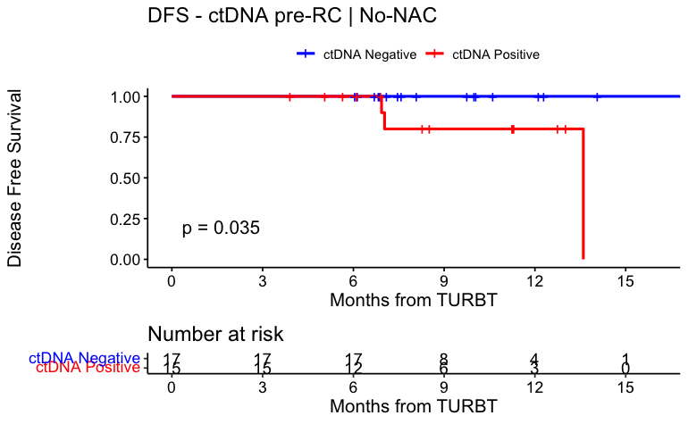

```r
surv_object <-Surv(time = circ_data$RFS_TURBT, event = circ_data$RecStatus)
KM_curve <- survfit(surv_object ~ MRD_anytimepreSx, data = circ_data,conf.int=0.95,conf.type="log-log")
ggsurvplot(KM_curve, data = circ_data, pval = TRUE, conf.int = FALSE, risk.table = TRUE, break.time.by=3, palette=c("blue","red"), title="DFS - ctDNA pre-RC | No-NAC", ylab= "Disease Free Survival", xlab="Months from TURBT", legend.labs=c("ctDNA Negative", "ctDNA Positive"), legend.title="")
```

```r
summary(KM_curve, times= c(12))
```

```
Call: survfit(formula = surv_object ~ MRD_anytimepreSx, data = circ_data,
    conf.int = 0.95, conf.type = "log-log")

                MRD_anytimepreSx=0
        time       n.risk      n.event     survival      std.err lower 95% CI upper 95% CI
          12            4            0            1            0           NA           NA

                MRD_anytimepreSx=1
        time       n.risk      n.event     survival      std.err lower 95% CI upper 95% CI
      12.000        3.000        2.000        0.800        0.126        0.409        0.946
```

```r
circ_data$MRD_anytimepreSx <- factor(circ_data$MRD_anytimepreSx, levels=c("0","1"))
cox_fit <- coxphf(surv_object ~ MRD_anytimepreSx, data=circ_data)
summary(cox_fit)
```

```
coxphf(formula = surv_object ~ MRD_anytimepreSx, data = circ_data)

Model fitted by Penalized ML
Confidence intervals and p-values by Profile Likelihood

                      coef se(coef) exp(coef) lower 0.95 upper 0.95  Chisq          p
MRD_anytimepreSx1 2.361826 1.757088  10.61031   1.010463   1433.837 3.8804 0.04885292

Likelihood ratio test=3.8804 on 1 df, p=0.04885292, n=32
Wald test = 1.806795 on 1 df, p = 0.1788932

Covariance-Matrix:
                  MRD_anytimepreSx1
MRD_anytimepreSx1          3.087358
```

```r
# Fisher plot for pre-RC ctDNA and Rec Status
rm(list=ls())
setwd("~/Downloads")
circ_data <- read.csv("RWE_MIBC Combined.csv")
circ_datadf <- as.data.frame(circ_data)
circ_data <- circ_data[circ_data$FU_months>=3,]
circ_data$MRD_anytimepreSx <- factor(circ_data$MRD_anytimepreSx, levels = c("0", "1"), labels = c("ctDNA(-)", "ctDNA(+)"))
circ_data$RecStatus <- factor(circ_data$RecStatus, levels = c("0", "1"), labels = c("No Recurrence", "Recurrence"))
contingency_table <- table(circ_data$MRD_anytimepreSx, circ_data$RecStatus)
chi_square_test <- chisq.test(contingency_table)
print(chi_square_test)
```

```
    Pearson's Chi-squared test with Yates' continuity correction

data:  contingency_table
X-squared = 1.9399, df = 1, p-value = 0.1637
```

```r
fisher_exact_test <- fisher.test(contingency_table)
print(fisher_exact_test)
```

```
    Fisher's Exact Test for Count Data

data:  contingency_table
p-value = 0.1397
alternative hypothesis: true odds ratio is not equal to 1
95 percent confidence interval:
  0.6669841 24.1583419
sample estimates:
odds ratio
  3.525735
```

```r
print(contingency_table)
```

```
           No Recurrence Recurrence
  ctDNA(-)            36          3
  ctDNA(+)            20          6
```

[figure not shown]

```r
table_df <- as.data.frame(contingency_table)
table_df$Total <- ave(table_df$Freq, table_df$Var1, FUN = sum)
table_df$Percentage <- table_df$Freq / table_df$Total
table_df$MiddlePercentage <- table_df$Percentage / 2
ggplot(table_df, aes(x = Var1, y = Percentage, fill = Var2)) +
  geom_bar(stat = "identity") +
  geom_text(aes(y = MiddlePercentage, label = Freq), position = "stack", color = "black", vjust = 1.5, size = 7) +
  theme_minimal() +
  labs(title = "ctDNA pre-RC - no NAC (n = 32)", x = "ctDNA", y = "Patients (%)", fill = "Recurrence") +
  scale_y_continuous(labels = scales::percent_format()) +
  scale_fill_manual(values = c("No Recurrence" = "lightblue3", "Recurrence" = "red")) + # define custom colors
  theme(axis.text.x = element_text(angle = 0, hjust = 1.5, size = 14), # increase x-axis text size
        axis.text.y = element_text(size = 14, color = "black"), # increase y-axis text size
        axis.title.x = element_text(size = 14, color = "black"), # increase x-axis label size
        axis.title.y = element_text(size = 14, color = "black"), # increase y-axis label size
        legend.text = element_text(size = 12, color = "black"))  # increase Recurrence label size
```

```r
# Median of FU_months
median_value <- median(circ_data$FU_months, na.rm = TRUE)

# Range of FU_months (Min and Max)
min_value <- min(circ_data$FU_months, na.rm = TRUE)
max_value <- max(circ_data$FU_months, na.rm = TRUE)

# Print the results
cat("Median of FU_months:", median_value, "\n")
```

```
Median of FU_months: 10.21783
```

```r
cat("Range of FU_months:", min_value, "to", max_value)
```

```
Range of FU_months: 3.06 to 81.51263
```

#ctDNA pre-RC association with pathological factors after RC (Non-NAC treated)

```r
# Fisher plot pre-RC ctDNA and Pathological Stage after RC
rm(list=ls())
setwd("~/Downloads")
circ_data <- read.csv("RWE_MIBC Combined.csv")
circ_data <- circ_data[circ_data$ctDNA.Available=="TRUE",]
circ_data <- circ_data[circ_data$NAC=="0",]
circ_data <- circ_data[circ_data$FU_months>=3,]
circ_data <- subset(circ_data, !is.na(MRD_anytimepreSx))
circ_datadf <- as.data.frame(circ_data)

circ_data$MRD_anytimepreSx <- factor(circ_data$MRD_anytimepreSx, levels = c("0", "1"), labels = c("ctDNA(-)", "ctDNA(+)"))
circ_data$pStage.Group2 <- factor(circ_data$pStage.Group2, levels = c("1", "2"), labels = c("O/I", "II/III"))
contingency_table <- table(circ_data$MRD_anytimepreSx, circ_data$pStage.Group2)
chi_square_test <- chisq.test(contingency_table)
print(chi_square_test)
```

```
    Pearson's Chi-squared test with Yates' continuity correction

data:  contingency_table
X-squared = 6.7191, df = 1, p-value = 0.009539
```

```r
fisher_exact_test <- fisher.test(contingency_table)
print(fisher_exact_test)
```

```
    Fisher's Exact Test for Count Data

data:  contingency_table
p-value = 0.004572
alternative hypothesis: true odds ratio is not equal to 1
95 percent confidence interval:
   1.640409 131.639149
sample estimates:
odds ratio
   10.8828
```

```r
print(contingency_table)
```

```
           O/I II/III
  ctDNA(-)  11      6
  ctDNA(+)   2     13
```

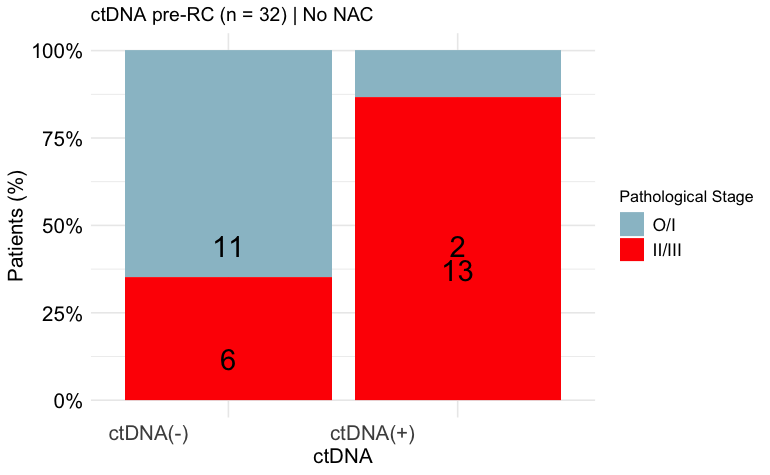

```r
table_df <- as.data.frame(contingency_table)
table_df$Total <- ave(table_df$Freq, table_df$Var1, FUN = sum)
table_df$Percentage <- table_df$Freq / table_df$Total
table_df$MiddlePercentage <- table_df$Percentage / 2
ggplot(table_df, aes(x = Var1, y = Percentage, fill = Var2)) +
  geom_bar(stat = "identity") +
  geom_text(aes(y = MiddlePercentage, label = Freq), position = "stack", color = "black", vjust = 1.5, size = 7) +
  theme_minimal() +
  labs(title = "ctDNA pre-RC (n = 32) | No NAC", x = "ctDNA", y = "Patients (%)", fill = "Pathological Stage") +
  scale_y_continuous(labels = scales::percent_format()) +
  scale_fill_manual(values = c("O/I" = "lightblue3", "II/III" = "red")) + # define custom colors
  theme(axis.text.x = element_text(angle = 0, hjust = 1.5, size = 14), # increase x-axis text size
        axis.text.y = element_text(size = 14, color = "black"), # increase y-axis text size
        axis.title.x = element_text(size = 14, color = "black"), # increase x-axis label size
        axis.title.y = element_text(size = 14, color = "black"), # increase y-axis label size
        legend.text = element_text(size = 12, color = "black"))  # increase Recurrence label size
```

#Multivariate regression model for DFS at the pre-RC setting (NAC & Non-NAC treated)

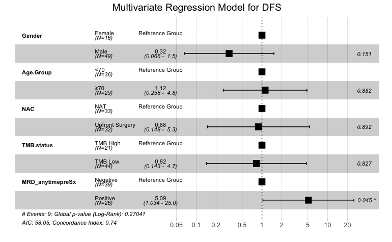

```r
rm(list=ls())
setwd("~/Downloads")
circ_data <- read.csv("RWE_MIBC Combined.csv")
circ_data <- circ_data[circ_data$ctDNA.Available=="TRUE",]
circ_data <- subset(circ_data, !is.na(MRD_anytimepreSx))
circ_data <- circ_data[circ_data$FU_months>=3,]
circ_datadf <- as.data.frame(circ_data)

circ_datadf$Gender <- factor(circ_datadf$Gender, levels = c("Female", "Male"), labels = c("Female", "Male"))
circ_datadf$Age.Group <- factor(circ_datadf$Age.Group, levels = c("0", "1"), labels = c("<70", "≥70"))
circ_datadf$NAC <- factor(circ_datadf$NAC, levels = c("1", "0"), labels = c("NAT", "Upfront Surgery"))
circ_datadf$TMB.status <- factor(circ_datadf$TMB.status, levels = c("TMB-High", "TMB-Low"), labels = c("TMB High", "TMB Low"))
circ_datadf$histology_subtype <- factor(circ_datadf$histology_subtype, levels = c("Pure", "VH"), labels = c("Pure Urothelial", "Variant Histology"))
circ_datadf$MRD_anytimepreSx <- factor(circ_datadf$MRD_anytimepreSx, levels=c("0","1"), labels = c("Negative", "Positive"))
surv_object<-Surv(time = circ_datadf$RFS_TURBT, event = circ_datadf$RecStatus)
cox_fit <- coxph(surv_object ~ Gender + Age.Group + NAC + TMB.status + MRD_anytimepreSx, data=circ_datadf)
ggforest(cox_fit, data = circ_datadf, main = "Multivariate Regression Model for DFS", refLabel = "Reference Group")
```

```r
test.ph <- cox.zph(cox_fit)
```

#Univariate regression models for DFS for the factors used in the MVA

```r
rm(list=ls())
setwd("~/Downloads")
circ_data <- read.csv("RWE_MIBC Combined.csv")
circ_data <- circ_data[circ_data$ctDNA.Available=="TRUE",]
circ_data <- subset(circ_data, !is.na(MRD_anytimepreSx))
circ_data <- circ_data[circ_data$FU_months>=3,]
circ_datadf <- as.data.frame(circ_data)
surv_object <-Surv(time = circ_data$RFS_TURBT, event = circ_data$RecStatus)
circ_datadf$Gender <- factor(circ_datadf$Gender, levels = c("Female", "Male"), labels = c("Female", "Male")) #univariate for gender
cox_fit <- coxph(surv_object ~ Gender, data=circ_data)
summary(cox_fit)
```

```
Call:
coxph(formula = surv_object ~ Gender, data = circ_data)

  n= 65, number of events= 9

              coef exp(coef) se(coef)     z Pr(>|z|)
GenderMale -0.8235    0.4389   0.7160 -1.15     0.25

           exp(coef) exp(-coef) lower .95 upper .95
GenderMale    0.4389      2.278    0.1079     1.786

Concordance= 0.464  (se = 0.063 )
Likelihood ratio test= 1.29  on 1 df,   p=0.3
Wald test            = 1.32  on 1 df,   p=0.3
Score (logrank) test = 1.39  on 1 df,   p=0.2
```

```r
cox_fit_summary <- summary(cox_fit)
HR <- cox_fit_summary$coefficients[2]
lower_CI <- cox_fit_summary$conf.int[3]
upper_CI <- cox_fit_summary$conf.int[4]
p_value <- cox_fit_summary$coefficients[5]
label_text <- paste0("HR = ", round(HR, 2), " (", round(lower_CI, 2), "-", round(upper_CI, 2), "); p = ", round(p_value, 3))
print(label_text)
```

```
[1] "HR = 0.44 (0.11-1.79); p = 0.25"
```

```r
rm(list=ls())
setwd("~/Downloads")
circ_data <- read.csv("RWE_MIBC Combined.csv")
circ_data <- circ_data[circ_data$ctDNA.Available=="TRUE",]
circ_data <- subset(circ_data, !is.na(MRD_anytimepreSx))
circ_data <- circ_data[circ_data$FU_months>=3,]
circ_datadf <- as.data.frame(circ_data)
surv_object <-Surv(time = circ_data$RFS_TURBT, event = circ_data$RecStatus)
circ_datadf$Age.Group <- factor(circ_datadf$Age.Group, levels = c("0", "1"), labels = c("<70", "≥70")) #univariate for age group
cox_fit <- coxph(surv_object ~ Age.Group, data=circ_data)
summary(cox_fit)
```

```
Call:
coxph(formula = surv_object ~ Age.Group, data = circ_data)

  n= 65, number of events= 9

            coef exp(coef) se(coef)     z Pr(>|z|)
Age.Group 0.2848    1.3294   0.6808 0.418    0.676

          exp(coef) exp(-coef) lower .95 upper .95
Age.Group     1.329     0.7522    0.3501     5.049

Concordance= 0.608  (se = 0.095 )
Likelihood ratio test= 0.18  on 1 df,   p=0.7
Wald test            = 0.17  on 1 df,   p=0.7
Score (logrank) test = 0.18  on 1 df,   p=0.7
```

```r
cox_fit_summary <- summary(cox_fit)
HR <- cox_fit_summary$coefficients[2]
lower_CI <- cox_fit_summary$conf.int[3]
upper_CI <- cox_fit_summary$conf.int[4]
p_value <- cox_fit_summary$coefficients[5]
label_text <- paste0("HR = ", round(HR, 2), " (", round(lower_CI, 2), "-", round(upper_CI, 2), "); p = ", round(p_value, 3))
print(label_text)
```

```
[1] "HR = 1.33 (0.35-5.05); p = 0.676"
```

```r
rm(list=ls())
setwd("~/Downloads")
circ_data <- read.csv("RWE_MIBC Combined.csv")
circ_data <- circ_data[circ_data$ctDNA.Available=="TRUE",]
circ_data <- subset(circ_data, !is.na(MRD_anytimepreSx))
circ_data <- circ_data[circ_data$FU_months>=3,]
circ_datadf <- as.data.frame(circ_data)
surv_object <-Surv(time = circ_data$RFS_TURBT, event = circ_data$RecStatus)
circ_datadf$NAC <- factor(circ_datadf$NAC, levels = c("1", "0"), labels = c("NAT", "Upfront Surgery")) #univariate for NAT
cox_fit <- coxph(surv_object ~ NAC, data=circ_data)
summary(cox_fit)
```

```
Call:
coxph(formula = surv_object ~ NAC, data = circ_data)

  n= 65, number of events= 9

       coef exp(coef) se(coef)      z Pr(>|z|)
NAC -0.4380    0.6453   0.7839 -0.559    0.576

    exp(coef) exp(-coef) lower .95 upper .95
NAC    0.6453       1.55    0.1388         3

Concordance= 0.536  (se = 0.105 )
Likelihood ratio test= 0.3  on 1 df,   p=0.6
Wald test            = 0.31  on 1 df,   p=0.6
Score (logrank) test = 0.32  on 1 df,   p=0.6
```

```r
cox_fit_summary <- summary(cox_fit)
HR <- cox_fit_summary$coefficients[2]
lower_CI <- cox_fit_summary$conf.int[3]
upper_CI <- cox_fit_summary$conf.int[4]
p_value <- cox_fit_summary$coefficients[5]
label_text <- paste0("HR = ", round(HR, 2), " (", round(lower_CI, 2), "-", round(upper_CI, 2), "); p = ", round(p_value, 3))
print(label_text)
```

```
[1] "HR = 0.65 (0.14-3); p = 0.576"
```

```r
rm(list=ls())
setwd("~/Downloads")
circ_data <- read.csv("RWE_MIBC Combined.csv")
circ_data <- circ_data[circ_data$ctDNA.Available=="TRUE",]
circ_data <- subset(circ_data, !is.na(MRD_anytimepreSx))
circ_data <- circ_data[circ_data$FU_months>=3,]
circ_datadf <- as.data.frame(circ_data)
surv_object <-Surv(time = circ_data$RFS_TURBT, event = circ_data$RecStatus)
circ_datadf$TMB.status <- factor(circ_datadf$TMB.status, levels = c("TMB-High", "TMB-Low"), labels = c("TMB High", "TMB Low")) #univariate for TMB
cox_fit <- coxph(surv_object ~ TMB.status, data=circ_data)
summary(cox_fit)
```

```
Call:
coxph(formula = surv_object ~ TMB.status, data = circ_data)

  n= 65, number of events= 9

                    coef exp(coef) se(coef)     z Pr(>|z|)
TMB.statusTMB-Low 0.4847    1.6237   0.8436 0.575    0.566

                  exp(coef) exp(-coef) lower .95 upper .95
TMB.statusTMB-Low     1.624     0.6159    0.3107     8.485

Concordance= 0.441  (se = 0.103 )
Likelihood ratio test= 0.36  on 1 df,   p=0.6
Wald test            = 0.33  on 1 df,   p=0.6
Score (logrank) test = 0.33  on 1 df,   p=0.6
```

```r
cox_fit_summary <- summary(cox_fit)
HR <- cox_fit_summary$coefficients[2]
lower_CI <- cox_fit_summary$conf.int[3]
upper_CI <- cox_fit_summary$conf.int[4]
p_value <- cox_fit_summary$coefficients[5]
label_text <- paste0("HR = ", round(HR, 2), " (", round(lower_CI, 2), "-", round(upper_CI, 2), "); p = ", round(p_value, 3))
print(label_text)
```

```
[1] "HR = 1.62 (0.31-8.48); p = 0.566"
```

```r
rm(list=ls())
setwd("~/Downloads")
circ_data <- read.csv("RWE_MIBC Combined.csv")
circ_data <- circ_data[circ_data$ctDNA.Available=="TRUE",]
circ_data <- subset(circ_data, !is.na(MRD_anytimepreSx))
circ_data <- circ_data[circ_data$FU_months>=3,]
circ_datadf <- as.data.frame(circ_data)
surv_object <-Surv(time = circ_data$RFS_TURBT, event = circ_data$RecStatus)
circ_data$MRD_anytimepreSx <- factor(circ_data$MRD_anytimepreSx, levels=c("0","1")) #univariate for ctDNA pre-op
cox_fit <- coxph(surv_object ~ MRD_anytimepreSx, data=circ_data)
summary(cox_fit)
```

```
Call:
coxph(formula = surv_object ~ MRD_anytimepreSx, data = circ_data)

  n= 65, number of events= 9

                    coef exp(coef) se(coef)     z Pr(>|z|)
MRD_anytimepreSx1 1.3950    4.0348   0.7112 1.961   0.0498 *
---
Signif. codes:  0 ‘***’ 0.001 ‘**’ 0.01 ‘*’ 0.05 ‘.’ 0.1 ‘ ’ 1

                  exp(coef) exp(-coef) lower .95 upper .95
MRD_anytimepreSx1     4.035     0.2478     1.001     16.26

Concordance= 0.713  (se = 0.075 )
Likelihood ratio test= 4.16  on 1 df,   p=0.04
Wald test            = 3.85  on 1 df,   p=0.05
Score (logrank) test = 4.49  on 1 df,   p=0.03
```

```r
cox_fit_summary <- summary(cox_fit)
HR <- cox_fit_summary$coefficients[2]
lower_CI <- cox_fit_summary$conf.int[3]
upper_CI <- cox_fit_summary$conf.int[4]
p_value <- cox_fit_summary$coefficients[5]
label_text <- paste0("HR = ", round(HR, 2), " (", round(lower_CI, 2), "-", round(upper_CI, 2), "); p = ", round(p_value, 3))
print(label_text)
```

```
[1] "HR = 4.03 (1-16.26); p = 0.05"
```

#Prognostic role of ctDNA at the MRD Window (1-12 week post-RC)

```r
rm(list=ls())
setwd("~/Downloads")
circ_data <- read.csv("RWE_MIBC Combined.csv")
circ_data <- circ_data[circ_data$ctDNA.Available=="TRUE",]
circ_data <- circ_data[circ_data$FU_months>=3,]
circ_data$RFS_months=circ_data$RFS_months-3
circ_data <- circ_data[circ_data$RFS_months>=0,]
circ_datadf <- as.data.frame(circ_data)

survfit(Surv(time = circ_data$RFS_months, event = circ_data$RecStatus)~MRD_postSx.MRD.Window, data = circ_data)
```

```
Call: survfit(formula = Surv(time = circ_data$RFS_months, event = circ_data$RecStatus) ~
    MRD_postSx.MRD.Window, data = circ_data)

   66 observations deleted due to missingness
                         n events median 0.95LCL 0.95UCL
MRD_postSx.MRD.Window=0 76      6     NA      NA      NA
MRD_postSx.MRD.Window=1 18      8   7.94    4.36      NA
```

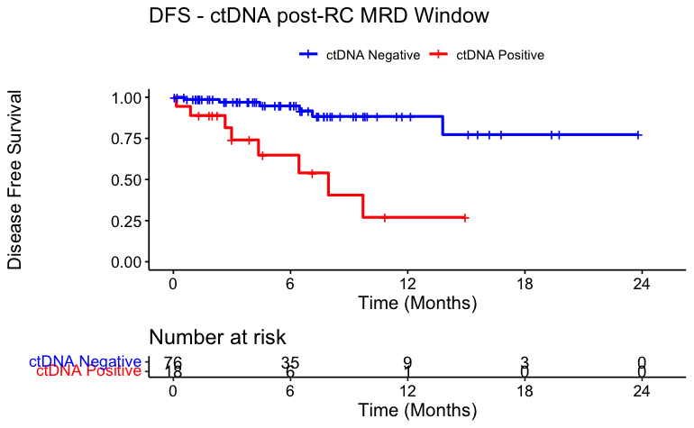

```r
surv_object <-Surv(time = circ_data$RFS_months, event = circ_data$RecStatus)
KM_curve <- survfit(surv_object ~ MRD_postSx.MRD.Window, data = circ_data,conf.int=0.95,conf.type="log-log")
ggsurvplot(KM_curve, data = circ_data, pval = FALSE, conf.int = FALSE, risk.table = TRUE, break.time.by=6, palette=c("blue","red"), title="DFS - ctDNA post-RC MRD Window", ylab= "Disease Free Survival", xlab="Time (Months)", legend.labs=c("ctDNA Negative", "ctDNA Positive"), legend.title="")
```

```r
summary(KM_curve, times= c(12))
```

```
Call: survfit(formula = surv_object ~ MRD_postSx.MRD.Window, data = circ_data,
    conf.int = 0.95, conf.type = "log-log")

66 observations deleted due to missingness
                MRD_postSx.MRD.Window=0
        time       n.risk      n.event     survival      std.err lower 95% CI upper 95% CI
      12.000        9.000        5.000        0.883        0.052        0.730        0.952

                MRD_postSx.MRD.Window=1
        time       n.risk      n.event     survival      std.err lower 95% CI upper 95% CI
     12.0000       1.0000       8.0000       0.2701       0.1539       0.0463       0.5725
```

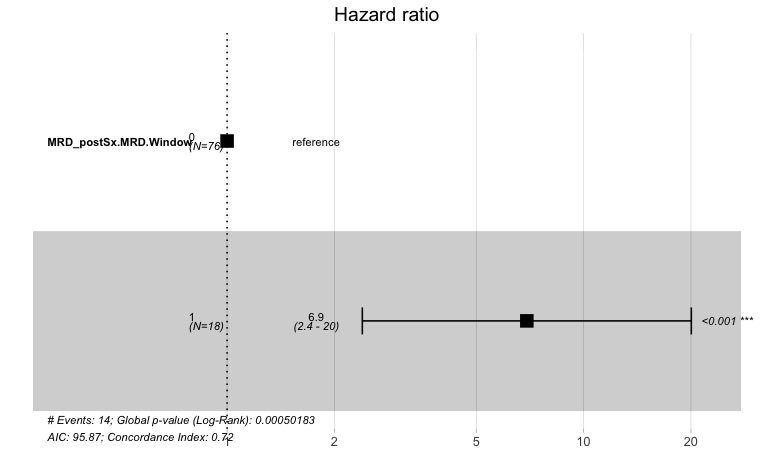

```r
circ_data$MRD_postSx.MRD.Window <- factor(circ_data$MRD_postSx.MRD.Window, levels=c("0","1"))
cox_fit <- coxph(surv_object ~ MRD_postSx.MRD.Window, data=circ_data)
ggforest(cox_fit,data = circ_data)
```

```r
summary(cox_fit)
```

```
Call:
coxph(formula = surv_object ~ MRD_postSx.MRD.Window, data = circ_data)

  n= 94, number of events= 14
   (66 observations deleted due to missingness)

                        coef exp(coef) se(coef)     z Pr(>|z|)
MRD_postSx.MRD.Window1 1.936     6.930    0.542 3.571 0.000355 ***
---
Signif. codes:  0 ‘***’ 0.001 ‘**’ 0.01 ‘*’ 0.05 ‘.’ 0.1 ‘ ’ 1

                       exp(coef) exp(-coef) lower .95 upper .95
MRD_postSx.MRD.Window1      6.93     0.1443     2.395     20.05

Concordance= 0.722  (se = 0.071 )
Likelihood ratio test= 12.11  on 1 df,   p=5e-04
Wald test            = 12.75  on 1 df,   p=4e-04
Score (logrank) test = 17.19  on 1 df,   p=3e-05
```

```r
cox_fit_summary <- summary(cox_fit)

# Extract values for HR, 95% CI, and p-value
HR <- cox_fit_summary$coefficients[2]
lower_CI <- cox_fit_summary$conf.int[3]
upper_CI <- cox_fit_summary$conf.int[4]
p_value <- cox_fit_summary$coefficients[5]
label_text <- paste0("HR = ", round(HR, 2), " (", round(lower_CI, 2), "-", round(upper_CI, 2), "); p = ", round(p_value, 3))
print(label_text)
```

```
[1] "HR = 6.93 (2.4-20.05); p = 0"
```

```r
# Fisher plot for ctDNA at the MRD Window (1-12 weeks post-RC) and Rec Status
circ_data$MRD_postSx.MRD.Window <- factor(circ_data$MRD_postSx.MRD.Window, levels = c("0", "1"), labels = c("ctDNA(-)", "ctDNA(+)"))
circ_data$RecStatus <- factor(circ_data$RecStatus, levels = c("0", "1"), labels = c("No Recurrence", "Recurrence"))
contingency_table <- table(circ_data$MRD_postSx.MRD.Window, circ_data$RecStatus)
chi_square_test <- chisq.test(contingency_table)
print(chi_square_test)
```

```
    Pearson's Chi-squared test with Yates' continuity correction

data:  contingency_table
X-squared = 12.59, df = 1, p-value = 0.0003878
```

```r
fisher_exact_test <- fisher.test(contingency_table)
print(fisher_exact_test)
```

```
    Fisher's Exact Test for Count Data

data:  contingency_table
p-value = 0.0006038
alternative hypothesis: true odds ratio is not equal to 1
95 percent confidence interval:
  2.231365 39.224577
sample estimates:
odds ratio
  8.996418
```

```r
print(contingency_table)
```

```
           No Recurrence Recurrence
  ctDNA(-)            70          6
  ctDNA(+)            10          8
```

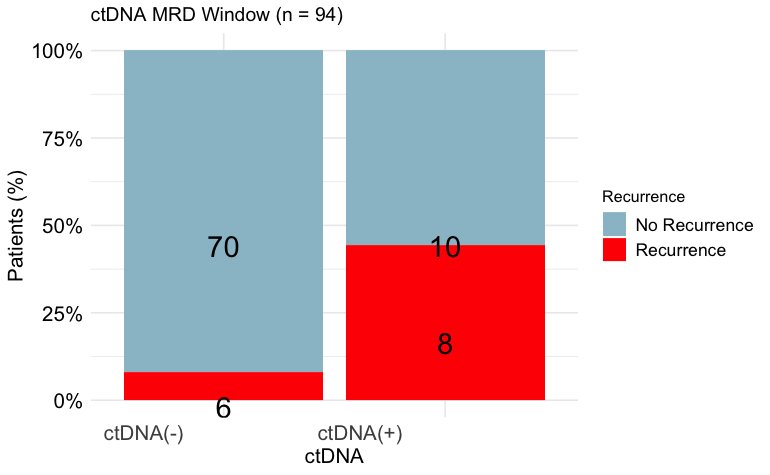

```r
table_df <- as.data.frame(contingency_table)
table_df$Total <- ave(table_df$Freq, table_df$Var1, FUN = sum)
table_df$Percentage <- table_df$Freq / table_df$Total
table_df$MiddlePercentage <- table_df$Percentage / 2
ggplot(table_df, aes(x = Var1, y = Percentage, fill = Var2)) +
  geom_bar(stat = "identity") +
  geom_text(aes(y = MiddlePercentage, label = Freq), position = "stack", color = "black", vjust = 1.5, size = 7) +
  theme_minimal() +
  labs(title = "ctDNA MRD Window (n = 94)", x = "ctDNA", y = "Patients (%)", fill = "Recurrence") +
  scale_y_continuous(labels = scales::percent_format()) +
  scale_fill_manual(values = c("No Recurrence" = "lightblue3", "Recurrence" = "red")) + # define custom colors
  theme(axis.text.x = element_text(angle = 0, hjust = 1.5, size = 14), # increase x-axis text size
        axis.text.y = element_text(size = 14, color = "black"), # increase y-axis text size
        axis.title.x = element_text(size = 14, color = "black"), # increase x-axis label size
        axis.title.y = element_text(size = 14, color = "black"), # increase y-axis label size
        legend.text = element_text(size = 12, color = "black"))  # increase Recurrence label size
```

#ctDNA positivity rate at the MRD window in NAT vs upfront surgery

```r
rm(list=ls())
setwd("~/Downloads")
circ_data <- read.csv("RWE_MIBC Combined.csv")
circ_data <- circ_data[circ_data$ctDNA.Available=="TRUE",]
circ_data <- circ_data[circ_data$FU_months>=3,]
circ_data$RFS_months=circ_data$RFS_months-3
circ_data <- circ_data[circ_data$RFS_months>=0,]
circ_datadf <- as.data.frame(circ_data)

# Fisher plot for ctDNA at the MRD Window (1-12 weeks post-RC) and NAT
circ_data$MRD_postSx.MRD.Window <- factor(circ_data$MRD_postSx.MRD.Window, levels = c("0", "1"), labels = c("ctDNA(-)", "ctDNA(+)"))
circ_datadf$NAC <- factor(circ_datadf$NAC, levels = c("1", "0"), labels = c("NAT", "Upfront Surgery"))
contingency_table <- table(circ_data$NAC, circ_data$MRD_postSx.MRD.Window)
chi_square_test <- chisq.test(contingency_table)
print(chi_square_test)
```

```
    Pearson's Chi-squared test with Yates' continuity correction

data:  contingency_table
X-squared = 1.5444, df = 1, p-value = 0.214
```

```r
fisher_exact_test <- fisher.test(contingency_table)
print(fisher_exact_test)
```

```
    Fisher's Exact Test for Count Data

data:  contingency_table
p-value = 0.1871
alternative hypothesis: true odds ratio is not equal to 1
95 percent confidence interval:
 0.1092306 1.4497495
sample estimates:
odds ratio
 0.4310719
```

```r
print(contingency_table)
```

```
    ctDNA(-) ctDNA(+)
  0       40       13
  1       36        5
```

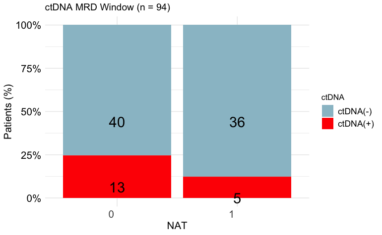

```r
table_df <- as.data.frame(contingency_table)
table_df$Total <- ave(table_df$Freq, table_df$Var1, FUN = sum)
table_df$Percentage <- table_df$Freq / table_df$Total
table_df$MiddlePercentage <- table_df$Percentage / 2
ggplot(table_df, aes(x = Var1, y = Percentage, fill = Var2)) +
  geom_bar(stat = "identity") +
  geom_text(aes(y = MiddlePercentage, label = Freq), position = "stack", color = "black", vjust = 1.5, size = 7) +
  theme_minimal() +
  labs(title = "ctDNA MRD Window (n = 94)", x = "NAT", y = "Patients (%)", fill = "ctDNA") +
  scale_y_continuous(labels = scales::percent_format()) +
  scale_fill_manual(values = c("ctDNA(-)" = "lightblue3", "ctDNA(+)" = "red")) + # define custom colors
  theme(axis.text.x = element_text(angle = 0, hjust = 1.5, size = 14), # increase x-axis text size
        axis.text.y = element_text(size = 14, color = "black"), # increase y-axis text size
        axis.title.x = element_text(size = 14, color = "black"), # increase x-axis label size
        axis.title.y = element_text(size = 14, color = "black"), # increase y-axis label size
        legend.text = element_text(size = 12, color = "black"))  # increase Recurrence label size
```

#Multivariate regression model for DFS at the MRD Window

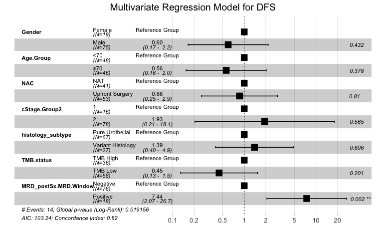

```r
rm(list=ls())
setwd("~/Downloads")
circ_data <- read.csv("RWE_MIBC Combined.csv")
circ_data <- circ_data[circ_data$ctDNA.Available=="TRUE",]
circ_data <- circ_data[circ_data$FU_months>=3,]
circ_data <- subset(circ_data, !is.na(MRD_postSx.MRD.Window))
circ_data$RFS_months=circ_data$RFS_months-3
circ_data <- circ_data[circ_data$RFS_months>=0,]
circ_datadf <- as.data.frame(circ_data)

circ_datadf$Gender <- factor(circ_datadf$Gender, levels = c("Female", "Male"), labels = c("Female", "Male"))
circ_datadf$Age.Group <- factor(circ_datadf$Age.Group, levels = c("0", "1"), labels = c("<70", "≥70"))
circ_datadf$NAC <- factor(circ_datadf$NAC, levels = c("1", "0"), labels = c("NAT", "Upfront Surgery"))
circ_datadf$cStage.Group2 <- factor(circ_datadf$cStage.Group2, levels = c("1", "2"))
circ_datadf$histology_subtype <- factor(circ_datadf$histology_subtype, levels = c("Pure", "VH"), labels = c("Pure Urothelial", "Variant Histology"))
circ_datadf$TMB.status <- factor(circ_datadf$TMB.status, levels = c("TMB-High", "TMB-Low"), labels = c("TMB High", "TMB Low"))
circ_datadf$MRD_postSx.MRD.Window <- factor(circ_datadf$MRD_postSx.MRD.Window, levels=c("0","1"), labels = c("Negative", "Positive"))
surv_object<-Surv(time = circ_datadf$RFS_months, event = circ_datadf$RecStatus)
cox_fit <- coxph(surv_object ~ Gender + Age.Group + NAC + cStage.Group2 + histology_subtype + TMB.status + MRD_postSx.MRD.Window, data=circ_datadf)
ggforest(cox_fit, data = circ_datadf, main = "Multivariate Regression Model for DFS", refLabel = "Reference Group")
```

```r
test.ph <- cox.zph(cox_fit)
```

#Univariate regression models for DFS for the factors used in the MVA

```r
rm(list=ls())
setwd("~/Downloads")
circ_data <- read.csv("RWE_MIBC Combined.csv")
circ_data <- circ_data[circ_data$ctDNA.Available=="TRUE",]
circ_data <- circ_data[circ_data$FU_months>=3,]
circ_data <- subset(circ_data, !is.na(MRD_postSx.MRD.Window))
circ_data$RFS_months=circ_data$RFS_months-3
circ_data <- circ_data[circ_data$RFS_months>=0,]
circ_datadf <- as.data.frame(circ_data)
surv_object <-Surv(time = circ_data$RFS_months, event = circ_data$RecStatus)
circ_datadf$Gender <- factor(circ_datadf$Gender, levels = c("Female", "Male"), labels = c("Female", "Male")) #univariate for gender
cox_fit <- coxph(surv_object ~ Gender, data=circ_data)
summary(cox_fit)
```

```
Call:
coxph(formula = surv_object ~ Gender, data = circ_data)

  n= 94, number of events= 14

              coef exp(coef) se(coef)      z Pr(>|z|)
GenderMale -0.8961    0.4082   0.5421 -1.653   0.0983 .
---
Signif. codes:  0 ‘***’ 0.001 ‘**’ 0.01 ‘*’ 0.05 ‘.’ 0.1 ‘ ’ 1

           exp(coef) exp(-coef) lower .95 upper .95
GenderMale    0.4082       2.45    0.1411     1.181

Concordance= 0.556  (se = 0.069 )
Likelihood ratio test= 2.55  on 1 df,   p=0.1
Wald test            = 2.73  on 1 df,   p=0.1
Score (logrank) test = 2.92  on 1 df,   p=0.09
```

```r
cox_fit_summary <- summary(cox_fit)
HR <- cox_fit_summary$coefficients[2]
lower_CI <- cox_fit_summary$conf.int[3]
upper_CI <- cox_fit_summary$conf.int[4]
p_value <- cox_fit_summary$coefficients[5]
label_text <- paste0("HR = ", round(HR, 2), " (", round(lower_CI, 2), "-", round(upper_CI, 2), "); p = ", round(p_value, 3))
print(label_text)
```

```
[1] "HR = 0.41 (0.14-1.18); p = 0.098"
```

```r
rm(list=ls())
setwd("~/Downloads")
circ_data <- read.csv("RWE_MIBC Combined.csv")
circ_data <- circ_data[circ_data$ctDNA.Available=="TRUE",]
circ_data <- circ_data[circ_data$FU_months>=3,]
circ_data <- subset(circ_data, !is.na(MRD_postSx.MRD.Window))
circ_data$RFS_months=circ_data$RFS_months-3
circ_data <- circ_data[circ_data$RFS_months>=0,]
circ_datadf <- as.data.frame(circ_data)
surv_object <-Surv(time = circ_data$RFS_months, event = circ_data$RecStatus)
circ_datadf$Age.Group <- factor(circ_datadf$Age.Group, levels = c("0", "1"), labels = c("<70", "≥70")) #univariate for age group
cox_fit <- coxph(surv_object ~ Age.Group, data=circ_data)
summary(cox_fit)
```

```
Call:
coxph(formula = surv_object ~ Age.Group, data = circ_data)

  n= 94, number of events= 14

            coef exp(coef) se(coef)     z Pr(>|z|)
Age.Group 0.1549    1.1675   0.5423 0.286    0.775

          exp(coef) exp(-coef) lower .95 upper .95
Age.Group     1.168     0.8565    0.4033      3.38

Concordance= 0.491  (se = 0.077 )
Likelihood ratio test= 0.08  on 1 df,   p=0.8
Wald test            = 0.08  on 1 df,   p=0.8
Score (logrank) test = 0.08  on 1 df,   p=0.8
```

```r
cox_fit_summary <- summary(cox_fit)
HR <- cox_fit_summary$coefficients[2]
lower_CI <- cox_fit_summary$conf.int[3]
upper_CI <- cox_fit_summary$conf.int[4]
p_value <- cox_fit_summary$coefficients[5]
label_text <- paste0("HR = ", round(HR, 2), " (", round(lower_CI, 2), "-", round(upper_CI, 2), "); p = ", round(p_value, 3))
print(label_text)
```

```
[1] "HR = 1.17 (0.4-3.38); p = 0.775"
```

```r
rm(list=ls())
setwd("~/Downloads")
circ_data <- read.csv("RWE_MIBC Combined.csv")
circ_data <- circ_data[circ_data$ctDNA.Available=="TRUE",]
circ_data <- circ_data[circ_data$FU_months>=3,]
circ_data <- subset(circ_data, !is.na(MRD_postSx.MRD.Window))
circ_data$RFS_months=circ_data$RFS_months-3
circ_data <- circ_data[circ_data$RFS_months>=0,]
circ_datadf <- as.data.frame(circ_data)
surv_object <-Surv(time = circ_data$RFS_months, event = circ_data$RecStatus)
circ_datadf$NAC <- factor(circ_datadf$NAC, levels = c("1", "0"), labels = c("NAT", "Upfront Surgery")) #univariate for NAT
cox_fit <- coxph(surv_object ~ NAC, data=circ_data)
summary(cox_fit)
```

```
Call:
coxph(formula = surv_object ~ NAC, data = circ_data)

  n= 94, number of events= 14

        coef exp(coef) se(coef)      z Pr(>|z|)
NAC -0.06924   0.93310  0.54485 -0.127    0.899

    exp(coef) exp(-coef) lower .95 upper .95
NAC    0.9331      1.072    0.3207     2.715

Concordance= 0.483  (se = 0.076 )
Likelihood ratio test= 0.02  on 1 df,   p=0.9
Wald test            = 0.02  on 1 df,   p=0.9
Score (logrank) test = 0.02  on 1 df,   p=0.9
```

```r
cox_fit_summary <- summary(cox_fit)
HR <- cox_fit_summary$coefficients[2]
lower_CI <- cox_fit_summary$conf.int[3]
upper_CI <- cox_fit_summary$conf.int[4]
p_value <- cox_fit_summary$coefficients[5]
label_text <- paste0("HR = ", round(HR, 2), " (", round(lower_CI, 2), "-", round(upper_CI, 2), "); p = ", round(p_value, 3))
print(label_text)
```

```
[1] "HR = 0.93 (0.32-2.71); p = 0.899"
```

```r
rm(list=ls())
setwd("~/Downloads")
circ_data <- read.csv("RWE_MIBC Combined.csv")
circ_data <- circ_data[circ_data$ctDNA.Available=="TRUE",]
circ_data <- circ_data[circ_data$FU_months>=3,]
circ_data <- subset(circ_data, !is.na(MRD_postSx.MRD.Window))
circ_data$RFS_months=circ_data$RFS_months-3
circ_data <- circ_data[circ_data$RFS_months>=0,]
circ_datadf <- as.data.frame(circ_data)
surv_object <-Surv(time = circ_data$RFS_months, event = circ_data$RecStatus)
circ_datadf$cStage.Group2 <- factor(circ_datadf$cStage.Group2, levels = c("1", "2")) #univariate for overall stage
cox_fit <- coxph(surv_object ~ cStage.Group2, data=circ_data)
summary(cox_fit)
```

```
Call:
coxph(formula = surv_object ~ cStage.Group2, data = circ_data)

  n= 94, number of events= 14

               coef exp(coef) se(coef)     z Pr(>|z|)
cStage.Group2 1.235     3.440    1.040 1.188    0.235

              exp(coef) exp(-coef) lower .95 upper .95
cStage.Group2      3.44     0.2907    0.4479     26.41

Concordance= 0.566  (se = 0.037 )
Likelihood ratio test= 2.01  on 1 df,   p=0.2
Wald test            = 1.41  on 1 df,   p=0.2
Score (logrank) test = 1.6  on 1 df,   p=0.2
```

```r
cox_fit_summary <- summary(cox_fit)
HR <- cox_fit_summary$coefficients[2]
lower_CI <- cox_fit_summary$conf.int[3]
upper_CI <- cox_fit_summary$conf.int[4]
p_value <- cox_fit_summary$coefficients[5]
label_text <- paste0("HR = ", round(HR, 2), " (", round(lower_CI, 2), "-", round(upper_CI, 2), "); p = ", round(p_value, 3))
print(label_text)
```

```
[1] "HR = 3.44 (0.45-26.41); p = 0.235"
```

```r
rm(list=ls())
setwd("~/Downloads")
circ_data <- read.csv("RWE_MIBC Combined.csv")
circ_data <- circ_data[circ_data$ctDNA.Available=="TRUE",]
circ_data <- circ_data[circ_data$FU_months>=3,]
circ_data <- subset(circ_data, !is.na(MRD_postSx.MRD.Window))
circ_data$RFS_months=circ_data$RFS_months-3
circ_data <- circ_data[circ_data$RFS_months>=0,]
circ_datadf <- as.data.frame(circ_data)
surv_object <-Surv(time = circ_data$RFS_months, event = circ_data$RecStatus)
circ_datadf$histology_subtype <- factor(circ_datadf$histology_subtype, levels = c("Pure", "VH"), labels = c("Pure Urothelial", "Variant Histology")) #univariate for histology subtype
cox_fit <- coxph(surv_object ~ histology_subtype, data=circ_data)
summary(cox_fit)
```

```
Call:
coxph(formula = surv_object ~ histology_subtype, data = circ_data)

  n= 94, number of events= 14

                      coef exp(coef) se(coef)     z Pr(>|z|)
histology_subtypeVH 0.7618    2.1421   0.5446 1.399    0.162

                    exp(coef) exp(-coef) lower .95 upper .95
histology_subtypeVH     2.142     0.4668    0.7367     6.229

Concordance= 0.608  (se = 0.074 )
Likelihood ratio test= 1.85  on 1 df,   p=0.2
Wald test            = 1.96  on 1 df,   p=0.2
Score (logrank) test = 2.05  on 1 df,   p=0.2
```

```r
cox_fit_summary <- summary(cox_fit)
HR <- cox_fit_summary$coefficients[2]
lower_CI <- cox_fit_summary$conf.int[3]
upper_CI <- cox_fit_summary$conf.int[4]
p_value <- cox_fit_summary$coefficients[5]
label_text <- paste0("HR = ", round(HR, 2), " (", round(lower_CI, 2), "-", round(upper_CI, 2), "); p = ", round(p_value, 3))
print(label_text)
```

```
[1] "HR = 2.14 (0.74-6.23); p = 0.162"
```

```r
rm(list=ls())
setwd("~/Downloads")
circ_data <- read.csv("RWE_MIBC Combined.csv")
circ_data <- circ_data[circ_data$ctDNA.Available=="TRUE",]
circ_data <- circ_data[circ_data$FU_months>=3,]
circ_data <- subset(circ_data, !is.na(MRD_postSx.MRD.Window))
circ_data$RFS_months=circ_data$RFS_months-3
circ_data <- circ_data[circ_data$RFS_months>=0,]
circ_datadf <- as.data.frame(circ_data)
surv_object <-Surv(time = circ_data$RFS_months, event = circ_data$RecStatus)
circ_datadf$TMB.status <- factor(circ_datadf$TMB.status, levels = c("TMB-High", "TMB-Low"), labels = c("TMB High", "TMB Low")) #univariate for TMB
cox_fit <- coxph(surv_object ~ TMB.status, data=circ_data)
summary(cox_fit)
```

```
Call:
coxph(formula = surv_object ~ TMB.status, data = circ_data)

  n= 94, number of events= 14

                     coef exp(coef) se(coef)      z Pr(>|z|)
TMB.statusTMB-Low -0.4240    0.6544   0.5360 -0.791    0.429

                  exp(coef) exp(-coef) lower .95 upper .95
TMB.statusTMB-Low    0.6544      1.528    0.2289     1.871

Concordance= 0.555  (se = 0.076 )
Likelihood ratio test= 0.62  on 1 df,   p=0.4
Wald test            = 0.63  on 1 df,   p=0.4
Score (logrank) test = 0.64  on 1 df,   p=0.4
```

```r
cox_fit_summary <- summary(cox_fit)
HR <- cox_fit_summary$coefficients[2]
lower_CI <- cox_fit_summary$conf.int[3]
upper_CI <- cox_fit_summary$conf.int[4]
p_value <- cox_fit_summary$coefficients[5]
label_text <- paste0("HR = ", round(HR, 2), " (", round(lower_CI, 2), "-", round(upper_CI, 2), "); p = ", round(p_value, 3))
print(label_text)
```

```
[1] "HR = 0.65 (0.23-1.87); p = 0.429"
```

```r
rm(list=ls())
setwd("~/Downloads")
circ_data <- read.csv("RWE_MIBC Combined.csv")
circ_data <- circ_data[circ_data$ctDNA.Available=="TRUE",]
circ_data <- circ_data[circ_data$FU_months>=3,]
circ_data <- subset(circ_data, !is.na(MRD_postSx.MRD.Window))
circ_data$RFS_months=circ_data$RFS_months-3
circ_data <- circ_data[circ_data$RFS_months>=0,]
circ_datadf <- as.data.frame(circ_data)
surv_object <-Surv(time = circ_data$RFS_months, event = circ_data$RecStatus)
circ_data$MRD_postSx.MRD.Window <- factor(circ_data$MRD_postSx.MRD.Window, levels=c("0","1")) #univariate for ctDNA MRD window
cox_fit <- coxph(surv_object ~ MRD_postSx.MRD.Window, data=circ_data)
summary(cox_fit)
```

```
Call:
coxph(formula = surv_object ~ MRD_postSx.MRD.Window, data = circ_data)

  n= 94, number of events= 14

                        coef exp(coef) se(coef)     z Pr(>|z|)
MRD_postSx.MRD.Window1 1.936     6.930    0.542 3.571 0.000355 ***
---
Signif. codes:  0 ‘***’ 0.001 ‘**’ 0.01 ‘*’ 0.05 ‘.’ 0.1 ‘ ’ 1

                       exp(coef) exp(-coef) lower .95 upper .95
MRD_postSx.MRD.Window1      6.93     0.1443     2.395     20.05

Concordance= 0.722  (se = 0.071 )
Likelihood ratio test= 12.11  on 1 df,   p=5e-04
Wald test            = 12.75  on 1 df,   p=4e-04
Score (logrank) test = 17.19  on 1 df,   p=3e-05
```

```r
cox_fit_summary <- summary(cox_fit)
HR <- cox_fit_summary$coefficients[2]
lower_CI <- cox_fit_summary$conf.int[3]
upper_CI <- cox_fit_summary$conf.int[4]
p_value <- cox_fit_summary$coefficients[5]
label_text <- paste0("HR = ", round(HR, 2), " (", round(lower_CI, 2), "-", round(upper_CI, 2), "); p = ", round(p_value, 3))
print(label_text)
```

```
[1] "HR = 6.93 (2.4-20.05); p = 0"
```

#Prognostic role of ctDNA at the MRD Window - by stage

```r
#DFS in Stage 0/I
rm(list=ls())
setwd("~/Downloads")
circ_data <- read.csv("RWE_MIBC Combined.csv")
circ_data <- circ_data[circ_data$ctDNA.Available=="TRUE",]
circ_data <- circ_data[circ_data$FU_months>=3,]
circ_data <- circ_data[circ_data$pStage.Group2==1,]
circ_data <- subset(circ_data, !is.na(MRD_postSx.MRD.Window))
circ_data$RFS_months=circ_data$RFS_months-3
circ_data <- circ_data[circ_data$RFS_months>=0,]
circ_datadf <- as.data.frame(circ_data)

survfit(Surv(time = circ_data$RFS_months, event = circ_data$RecStatus)~MRD_postSx.MRD.Window, data = circ_data)
```

```
Call: survfit(formula = Surv(time = circ_data$RFS_months, event = circ_data$RecStatus) ~
    MRD_postSx.MRD.Window, data = circ_data)

                         n events median 0.95LCL 0.95UCL
MRD_postSx.MRD.Window=0 29      0     NA      NA      NA
MRD_postSx.MRD.Window=1  1      1   2.98      NA      NA
```

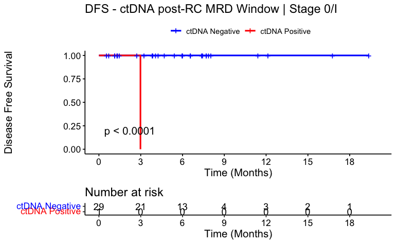

```r
surv_object <-Surv(time = circ_data$RFS_months, event = circ_data$RecStatus)
KM_curve <- survfit(surv_object ~ MRD_postSx.MRD.Window, data = circ_data,conf.int=0.95,conf.type="log-log")
ggsurvplot(KM_curve, data = circ_data, pval = TRUE, conf.int = FALSE, risk.table = TRUE, break.time.by=3, palette=c("blue","red"), title="DFS - ctDNA post-RC MRD Window | Stage 0/I", ylab= "Disease Free Survival", xlab="Time (Months)", legend.labs=c("ctDNA Negative", "ctDNA Positive"), legend.title="")
```

```r
summary(KM_curve, times= c(0,12))
```

```
Call: survfit(formula = surv_object ~ MRD_postSx.MRD.Window, data = circ_data,
    conf.int = 0.95, conf.type = "log-log")

                MRD_postSx.MRD.Window=0
 time n.risk n.event survival std.err lower 95% CI upper 95% CI
    0     29       0        1       0            1            1
   12      3       0        1       0           NA           NA

                MRD_postSx.MRD.Window=1
        time       n.risk      n.event     survival      std.err lower 95% CI upper 95% CI
           0            1            0            1            0            1            1
```

```r
circ_data$MRD_postSx.MRD.Window <- factor(circ_data$MRD_postSx.MRD.Window, levels=c("0","1"))
cox_fit <- coxphf(surv_object ~ MRD_postSx.MRD.Window, data=circ_data)
summary(cox_fit)
```

```
coxphf(formula = surv_object ~ MRD_postSx.MRD.Window, data = circ_data)

Model fitted by Penalized ML
Confidence intervals and p-values by Profile Likelihood

                           coef se(coef) exp(coef) lower 0.95 upper 0.95    Chisq           p
MRD_postSx.MRD.Window1 4.143137 2.309402  63.00011   3.360857   9192.976 7.070307 0.007837183

Likelihood ratio test=7.070307 on 1 df, p=0.007837183, n=30
Wald test = 3.218543 on 1 df, p = 0.07280839

Covariance-Matrix:
                       MRD_postSx.MRD.Window1
MRD_postSx.MRD.Window1               5.333338
```

```r
# Fisher plot for ctDNA at the MRD Window (1-12 weeks post-RC) and Rec Status
circ_data$MRD_postSx.MRD.Window <- factor(circ_data$MRD_postSx.MRD.Window, levels = c("0", "1"), labels = c("ctDNA(-)", "ctDNA(+)"))
circ_data$RecStatus <- factor(circ_data$RecStatus, levels = c("0", "1"), labels = c("No Recurrence", "Recurrence"))
contingency_table <- table(circ_data$MRD_postSx.MRD.Window, circ_data$RecStatus)
chi_square_test <- chisq.test(contingency_table)
print(chi_square_test)
```

```
    Pearson's Chi-squared test with Yates' continuity correction

data:  contingency_table
X-squared = 6.9917, df = 1, p-value = 0.008189
```

```r
fisher_exact_test <- fisher.test(contingency_table)
print(fisher_exact_test)
```

```
    Fisher's Exact Test for Count Data

data:  contingency_table
p-value = 0.03333
alternative hypothesis: true odds ratio is not equal to 1
95 percent confidence interval:
 0.7435884       Inf
sample estimates:
odds ratio
       Inf
```

```r
print(contingency_table)
```

```
           No Recurrence Recurrence
  ctDNA(-)            29          0
  ctDNA(+)             0          1
```

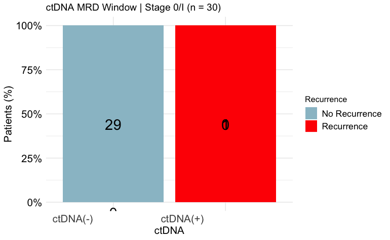

```r
table_df <- as.data.frame(contingency_table)
table_df$Total <- ave(table_df$Freq, table_df$Var1, FUN = sum)
table_df$Percentage <- table_df$Freq / table_df$Total
table_df$MiddlePercentage <- table_df$Percentage / 2
ggplot(table_df, aes(x = Var1, y = Percentage, fill = Var2)) +
  geom_bar(stat = "identity") +
  geom_text(aes(y = MiddlePercentage, label = Freq), position = "stack", color = "black", vjust = 1.5, size = 7) +
  theme_minimal() +
  labs(title = "ctDNA MRD Window | Stage 0/I (n = 30)", x = "ctDNA", y = "Patients (%)", fill = "Recurrence") +
  scale_y_continuous(labels = scales::percent_format()) +
  scale_fill_manual(values = c("No Recurrence" = "lightblue3", "Recurrence" = "red")) + # define custom colors
  theme(axis.text.x = element_text(angle = 0, hjust = 1.5, size = 14), # increase x-axis text size
        axis.text.y = element_text(size = 14, color = "black"), # increase y-axis text size
        axis.title.x = element_text(size = 14, color = "black"), # increase x-axis label size
        axis.title.y = element_text(size = 14, color = "black"), # increase y-axis label size
        legend.text = element_text(size = 12, color = "black"))  # increase Recurrence label size
```

```r
#DFS in Stage II/III
rm(list=ls())
setwd("~/Downloads")
circ_data <- read.csv("RWE_MIBC Combined.csv")
circ_data <- circ_data[circ_data$ctDNA.Available=="TRUE",]
circ_data <- circ_data[circ_data$FU_months>=3,]
circ_data <- circ_data[circ_data$pStage.Group2==2,]
circ_data$RFS_months=circ_data$RFS_months-3
circ_data <- circ_data[circ_data$RFS_months>=0,]
circ_datadf <- as.data.frame(circ_data)

survfit(Surv(time = circ_data$RFS_months, event = circ_data$RecStatus)~MRD_postSx.MRD.Window, data = circ_data)
```

```
Call: survfit(formula = Surv(time = circ_data$RFS_months, event = circ_data$RecStatus) ~
    MRD_postSx.MRD.Window, data = circ_data)

   48 observations deleted due to missingness
                         n events median 0.95LCL 0.95UCL
MRD_postSx.MRD.Window=0 47      6     NA   13.79      NA
MRD_postSx.MRD.Window=1 17      7   7.94    4.36      NA
```

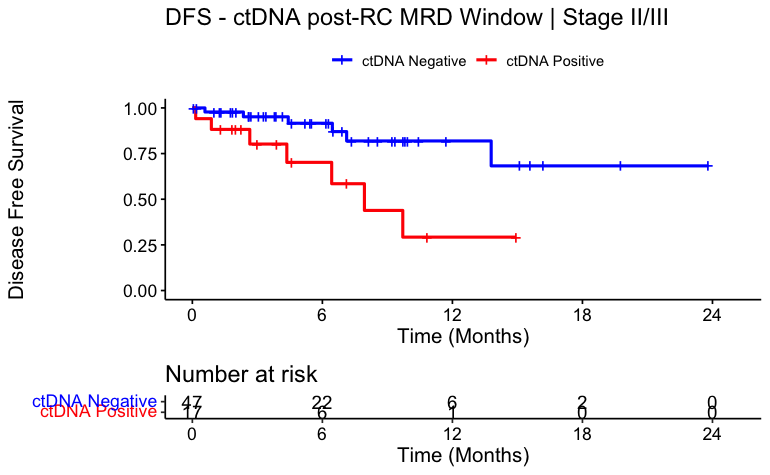

```r
surv_object <-Surv(time = circ_data$RFS_months, event = circ_data$RecStatus)
KM_curve <- survfit(surv_object ~ MRD_postSx.MRD.Window, data = circ_data,conf.int=0.95,conf.type="log-log")
ggsurvplot(KM_curve, data = circ_data, pval = FALSE, conf.int = FALSE, risk.table = TRUE, break.time.by=6, palette=c("blue","red"), title="DFS - ctDNA post-RC MRD Window | Stage II/III", ylab= "Disease Free Survival", xlab="Time (Months)", legend.labs=c("ctDNA Negative", "ctDNA Positive"), legend.title="")
```

```r
summary(KM_curve, times= c(0,12))
```

```
Call: survfit(formula = surv_object ~ MRD_postSx.MRD.Window, data = circ_data,
    conf.int = 0.95, conf.type = "log-log")

48 observations deleted due to missingness
                MRD_postSx.MRD.Window=0
 time n.risk n.event survival std.err lower 95% CI upper 95% CI
    0     47       0    1.000  0.0000        1.000        1.000
   12      6       5    0.819  0.0777        0.603        0.924

                MRD_postSx.MRD.Window=1
 time n.risk n.event survival std.err lower 95% CI upper 95% CI
    0     17       0    1.000   0.000       1.0000        1.000
   12      1       7    0.292   0.165       0.0487        0.606
```

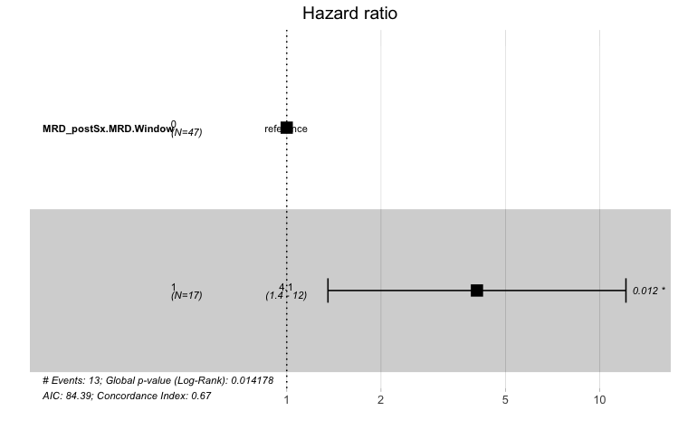

```r
circ_data$MRD_postSx.MRD.Window <- factor(circ_data$MRD_postSx.MRD.Window, levels=c("0","1"))
cox_fit <- coxph(surv_object ~ MRD_postSx.MRD.Window, data=circ_data)
ggforest(cox_fit,data = circ_data)
```

```r
summary(cox_fit)
```

```
Call:
coxph(formula = surv_object ~ MRD_postSx.MRD.Window, data = circ_data)

  n= 64, number of events= 13
   (48 observations deleted due to missingness)

                         coef exp(coef) se(coef)     z Pr(>|z|)
MRD_postSx.MRD.Window1 1.3991    4.0517   0.5591 2.503   0.0123 *
---
Signif. codes:  0 ‘***’ 0.001 ‘**’ 0.01 ‘*’ 0.05 ‘.’ 0.1 ‘ ’ 1

                       exp(coef) exp(-coef) lower .95 upper .95
MRD_postSx.MRD.Window1     4.052     0.2468     1.354     12.12

Concordance= 0.67  (se = 0.075 )
Likelihood ratio test= 6.02  on 1 df,   p=0.01
Wald test            = 6.26  on 1 df,   p=0.01
Score (logrank) test = 7.33  on 1 df,   p=0.007
```

```r
cox_fit_summary <- summary(cox_fit)

# Extract values for HR, 95% CI, and p-value
HR <- cox_fit_summary$coefficients[2]
lower_CI <- cox_fit_summary$conf.int[3]
upper_CI <- cox_fit_summary$conf.int[4]
p_value <- cox_fit_summary$coefficients[5]
label_text <- paste0("HR = ", round(HR, 2), " (", round(lower_CI, 2), "-", round(upper_CI, 2), "); p = ", round(p_value, 3))
print(label_text)
```

```
[1] "HR = 4.05 (1.35-12.12); p = 0.012"
```

```r
# Fisher plot for ctDNA at the MRD Window (1-12 weeks post-RC) and Rec Status
circ_data$MRD_postSx.MRD.Window <- factor(circ_data$MRD_postSx.MRD.Window, levels = c("0", "1"), labels = c("ctDNA(-)", "ctDNA(+)"))
circ_data$RecStatus <- factor(circ_data$RecStatus, levels = c("0", "1"), labels = c("No Recurrence", "Recurrence"))
contingency_table <- table(circ_data$MRD_postSx.MRD.Window, circ_data$RecStatus)
chi_square_test <- chisq.test(contingency_table)
print(chi_square_test)
```

```
    Pearson's Chi-squared test with Yates' continuity correction

data:  contingency_table
X-squared = 4.594, df = 1, p-value = 0.03208
```

```r
fisher_exact_test <- fisher.test(contingency_table)
print(fisher_exact_test)
```

```
    Fisher's Exact Test for Count Data

data:  contingency_table
p-value = 0.0298
alternative hypothesis: true odds ratio is not equal to 1
95 percent confidence interval:
  1.076393 21.105911
sample estimates:
odds ratio
  4.640091
```

```r
print(contingency_table)
```

```
           No Recurrence Recurrence
  ctDNA(-)            41          6
  ctDNA(+)            10          7
```

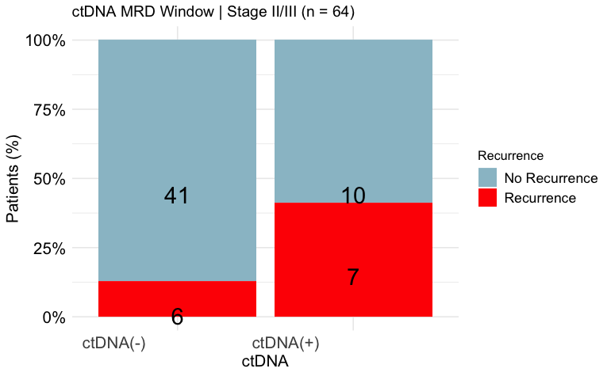

```r
table_df <- as.data.frame(contingency_table)
table_df$Total <- ave(table_df$Freq, table_df$Var1, FUN = sum)
table_df$Percentage <- table_df$Freq / table_df$Total
table_df$MiddlePercentage <- table_df$Percentage / 2
ggplot(table_df, aes(x = Var1, y = Percentage, fill = Var2)) +
  geom_bar(stat = "identity") +
  geom_text(aes(y = MiddlePercentage, label = Freq), position = "stack", color = "black", vjust = 1.5, size = 7) +
  theme_minimal() +
  labs(title = "ctDNA MRD Window | Stage II/III (n = 64)", x = "ctDNA", y = "Patients (%)", fill = "Recurrence") +
  scale_y_continuous(labels = scales::percent_format()) +
  scale_fill_manual(values = c("No Recurrence" = "lightblue3", "Recurrence" = "red")) + # define custom colors
  theme(axis.text.x = element_text(angle = 0, hjust = 1.5, size = 14), # increase x-axis text size
        axis.text.y = element_text(size = 14, color = "black"), # increase y-axis text size
        axis.title.x = element_text(size = 14, color = "black"), # increase x-axis label size
        axis.title.y = element_text(size = 14, color = "black"), # increase y-axis label size
        legend.text = element_text(size = 12, color = "black"))  # increase Recurrence label size
```

#ctDNA Dynamics from preRC to MRD Window

```r
rm(list=ls())
setwd("~/Downloads")
circ_data <- read.csv("RWE_MIBC Combined.csv")
circ_data <- circ_data[circ_data$ctDNA.Available=="TRUE",]
circ_data$RFS_months=circ_data$RFS_months-3
circ_data <- circ_data[circ_data$RFS_months>=0,]
circ_data <- circ_data[circ_data$FU_months>=3,]

survfit(Surv(time = circ_data$RFS_months, event = circ_data$RecStatus)~ctDNA.Dynamics, data = circ_data)
```

```
Call: survfit(formula = Surv(time = circ_data$RFS_months, event = circ_data$RecStatus) ~
    ctDNA.Dynamics, data = circ_data)

   123 observations deleted due to missingness
                  n events median 0.95LCL 0.95UCL
ctDNA.Dynamics=1 17      3  13.79      NA      NA
ctDNA.Dynamics=2 13      1     NA      NA      NA
ctDNA.Dynamics=3  5      2   7.94    2.65      NA
ctDNA.Dynamics=4  2      1   2.98      NA      NA
```

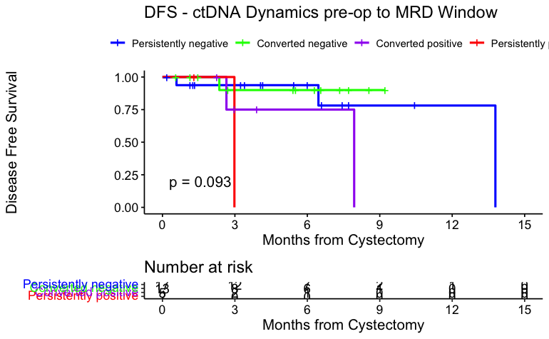

```r
surv_object <-Surv(time = circ_data$RFS_months, event = circ_data$RecStatus)
KM_curve <- survfit(surv_object ~ ctDNA.Dynamics, data = circ_data,conf.int=0.95,conf.type="log-log")
ggsurvplot(KM_curve, data = circ_data, pval = TRUE, conf.int = FALSE, risk.table = TRUE, break.time.by=3, palette=c("blue","green","purple", "red"), title="DFS - ctDNA Dynamics pre-op to MRD Window", ylab= "Disease Free Survival", xlab="Months from Cystectomy", legend.labs=c("Persistently negative", "Converted negative","Converted positive", "Persistently positive"), legend.title="")
```

```r
summary(KM_curve, times= c(0, 12))
```

```
Call: survfit(formula = surv_object ~ ctDNA.Dynamics, data = circ_data,
    conf.int = 0.95, conf.type = "log-log")

123 observations deleted due to missingness
                ctDNA.Dynamics=1
 time n.risk n.event survival std.err lower 95% CI upper 95% CI
    0     17       0    1.000   0.000        1.000        1.000
   12      1       2    0.781   0.151        0.317        0.948

                ctDNA.Dynamics=2
        time       n.risk      n.event     survival      std.err lower 95% CI upper 95% CI
           0           13            0            1            0            1            1

                ctDNA.Dynamics=3
        time       n.risk      n.event     survival      std.err lower 95% CI upper 95% CI
           0            5            0            1            0            1            1

                ctDNA.Dynamics=4
        time       n.risk      n.event     survival      std.err lower 95% CI upper 95% CI
           0            2            0            1            0            1            1
```

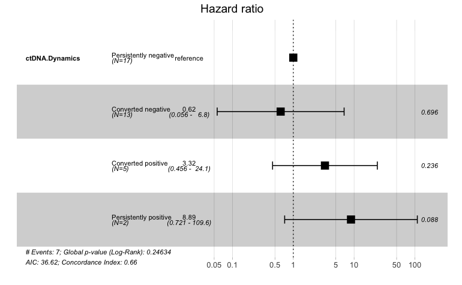

```r
circ_data$ctDNA.Dynamics <- factor(circ_data$ctDNA.Dynamics, levels=c("1","2","3","4"), labels = c("Persistently negative", "Converted negative","Converted positive", "Persistently positive"))
cox_fit <- coxph(surv_object ~ ctDNA.Dynamics, data=circ_data)
ggforest(cox_fit,data = circ_data)
```

```r
summary(cox_fit)
```

```
Call:
coxph(formula = surv_object ~ ctDNA.Dynamics, data = circ_data)

  n= 37, number of events= 7
   (123 observations deleted due to missingness)

                                       coef exp(coef) se(coef)      z Pr(>|z|)
ctDNA.DynamicsConverted negative    -0.4783    0.6198   1.2258 -0.390   0.6964
ctDNA.DynamicsConverted positive     1.1986    3.3153   1.0118  1.185   0.2362
ctDNA.DynamicsPersistently positive  2.1848    8.8889   1.2815  1.705   0.0882 .
---
Signif. codes:  0 ‘***’ 0.001 ‘**’ 0.01 ‘*’ 0.05 ‘.’ 0.1 ‘ ’ 1

                                    exp(coef) exp(-coef) lower .95 upper .95
ctDNA.DynamicsConverted negative       0.6198     1.6134   0.05608      6.85
ctDNA.DynamicsConverted positive       3.3153     0.3016   0.45634     24.09
ctDNA.DynamicsPersistently positive    8.8889     0.1125   0.72117    109.56

Concordance= 0.659  (se = 0.124 )
Likelihood ratio test= 4.14  on 3 df,   p=0.2
Wald test            = 4.69  on 3 df,   p=0.2
Score (logrank) test = 6.43  on 3 df,   p=0.09
```

#DFS by ctDNA and ACT combination in upfront surgery pts - four groups

```r
rm(list=ls())
setwd("~/Downloads")
circ_data <- read.csv("RWE_MIBC Combined.csv")
circ_data <- circ_data[circ_data$ctDNA.Available=="TRUE",]
circ_data <- circ_data[circ_data$NAC=="0",]
circ_data <- circ_data[circ_data$FU_months>=3,]
circ_data$RFS_months=circ_data$RFS_months-3
circ_data <- circ_data[circ_data$RFS_months>=0,]

circ_data$ctDNA.MRD.ACT <- NA #first we create the variable for the ctDNA & NAC combination, and we assign values
circ_data <- circ_data %>%
  mutate(ctDNA.MRD.ACT = case_when(
    postRC.FU == 2 & MRD_postSx.MRD.Window == 0 ~ 1,
    postRC.FU == 2 & MRD_postSx.MRD.Window == 1 ~ 2,
    postRC.FU == 1 & MRD_postSx.MRD.Window == 0 ~ 3,
    postRC.FU == 1 & MRD_postSx.MRD.Window == 1 ~ 4
  ))

circ_data <- subset(circ_data, !is.na(ctDNA.MRD.ACT))
survfit(Surv(time = circ_data$RFS_months, event = circ_data$RecStatus)~ctDNA.MRD.ACT, data = circ_data)
```

```
Call: survfit(formula = Surv(time = circ_data$RFS_months, event = circ_data$RecStatus) ~
    ctDNA.MRD.ACT, data = circ_data)

                 n events median 0.95LCL 0.95UCL
ctDNA.MRD.ACT=1 12      1     NA      NA      NA
ctDNA.MRD.ACT=2 10      6   7.94    4.36      NA
ctDNA.MRD.ACT=3 28      0     NA      NA      NA
ctDNA.MRD.ACT=4  3      1   2.98      NA      NA
```

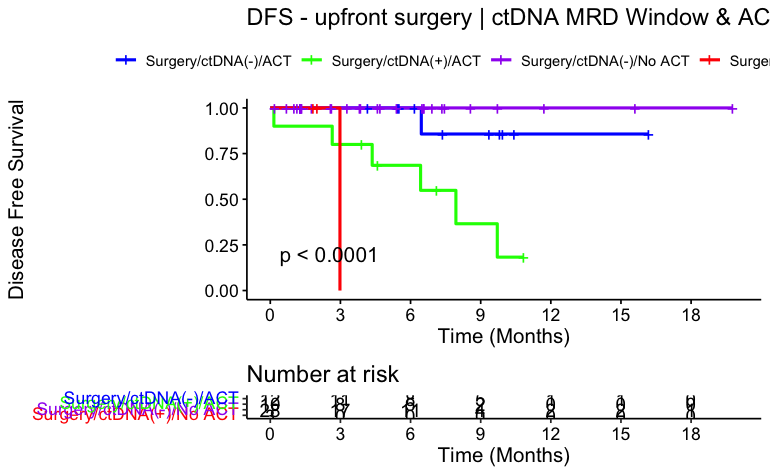

```r
surv_object <-Surv(time = circ_data$RFS_months, event = circ_data$RecStatus)
KM_curve <- survfit(surv_object ~ ctDNA.MRD.ACT, data = circ_data,conf.int=0.95,conf.type="log-log")
ggsurvplot(KM_curve, data = circ_data, pval = TRUE, conf.int = FALSE, risk.table = TRUE, break.time.by=3, palette=c("blue","green","purple", "red"), title="DFS - upfront surgery | ctDNA MRD Window & ACT", ylab= "Disease Free Survival", xlab="Time (Months)", legend.labs=c("Surgery/ctDNA(-)/ACT", "Surgery/ctDNA(+)/ACT","Surgery/ctDNA(-)/No ACT", "Surgery/ctDNA(+)/No ACT"), legend.title="")
```

```r
summary(KM_curve, times= c(0, 12))
```

```
Call: survfit(formula = surv_object ~ ctDNA.MRD.ACT, data = circ_data,
    conf.int = 0.95, conf.type = "log-log")

                ctDNA.MRD.ACT=1
 time n.risk n.event survival std.err lower 95% CI upper 95% CI
    0     12       0    1.000   0.000        1.000        1.000
   12      1       1    0.857   0.132        0.334        0.979

                ctDNA.MRD.ACT=2
        time       n.risk      n.event     survival      std.err lower 95% CI upper 95% CI
           0           10            0            1            0            1            1

                ctDNA.MRD.ACT=3
 time n.risk n.event survival std.err lower 95% CI upper 95% CI
    0     28       0        1       0            1            1
   12      2       0        1       0           NA           NA

                ctDNA.MRD.ACT=4
        time       n.risk      n.event     survival      std.err lower 95% CI upper 95% CI
           0            3            0            1            0            1            1
```

```r
circ_data$ctDNA.MRD.ACT <- factor(circ_data$ctDNA.MRD.ACT, levels=c("1","2", "3", "4"), labels = c("Surgery/ctDNA(-)/ACT", "Surgery/ctDNA(+)/ACT","Surgery/ctDNA(-)/No ACT", "Surgery/ctDNA(+)/No ACT"))
cox_fit <- coxphf(surv_object ~ ctDNA.MRD.ACT, data=circ_data)
summary(cox_fit)
```

```
coxphf(formula = surv_object ~ ctDNA.MRD.ACT, data = circ_data)

Model fitted by Penalized ML
Confidence intervals and p-values by Profile Likelihood

                                          coef se(coef)  exp(coef)  lower 0.95 upper 0.95     Chisq          p
ctDNA.MRD.ACTSurgery/ctDNA(+)/ACT     1.896486 1.003791  6.6624403 1.395919626  64.092884 5.8419789 0.01564822
ctDNA.MRD.ACTSurgery/ctDNA(-)/No ACT -1.432413 1.808206  0.2387322 0.001632785   4.497459 0.9089234 0.34040024
ctDNA.MRD.ACTSurgery/ctDNA(+)/No ACT  3.315251 1.502156 27.5293126 1.799221064 455.381731 5.3580435 0.02062690

Likelihood ratio test=17.19688 on 3 df, p=0.0006438114, n=53
Wald test = 9.365 on 3 df, p = 0.02481177

Covariance-Matrix:
                                     ctDNA.MRD.ACTSurgery/ctDNA(+)/ACT ctDNA.MRD.ACTSurgery/ctDNA(-)/No ACT ctDNA.MRD.ACTSurgery/ctDNA(+)/No ACT
ctDNA.MRD.ACTSurgery/ctDNA(+)/ACT                            1.0075967                            0.8197838                            0.8454142
ctDNA.MRD.ACTSurgery/ctDNA(-)/No ACT                         0.8197838                            3.2696083                            0.8571825
ctDNA.MRD.ACTSurgery/ctDNA(+)/No ACT                         0.8454142                            0.8571825                            2.2564729
```

```r
rm(list=ls())
setwd("~/Downloads")
circ_data <- read.csv("RWE_MIBC Combined.csv")
circ_data <- circ_data[circ_data$ctDNA.Available=="TRUE",]
circ_data <- circ_data[circ_data$NAC=="0",]
circ_data <- circ_data[circ_data$FU_months>=3,]
circ_data$RFS_months=circ_data$RFS_months-3
circ_data <- circ_data[circ_data$RFS_months>=0,]

circ_data$ctDNA.MRD.ACT <- NA #first we create the variable for the ctDNA & NAC combination, and we assign values
circ_data <- circ_data %>%
  mutate(ctDNA.MRD.ACT = case_when(
    postRC.FU == 2 & MRD_postSx.MRD.Window == 0 ~ 1,
    postRC.FU == 2 & MRD_postSx.MRD.Window == 1 ~ 2,
    postRC.FU == 1 & MRD_postSx.MRD.Window == 0 ~ 3,
    postRC.FU == 1 & MRD_postSx.MRD.Window == 1 ~ 4
  ))

circ_data <- subset(circ_data, !is.na(ctDNA.MRD.ACT))
survfit(Surv(time = circ_data$RFS_months, event = circ_data$RecStatus)~ctDNA.MRD.ACT, data = circ_data)
```

```
Call: survfit(formula = Surv(time = circ_data$RFS_months, event = circ_data$RecStatus) ~
    ctDNA.MRD.ACT, data = circ_data)

                 n events median 0.95LCL 0.95UCL
ctDNA.MRD.ACT=1 12      1     NA      NA      NA
ctDNA.MRD.ACT=2 10      6   7.94    4.36      NA
ctDNA.MRD.ACT=3 28      0     NA      NA      NA
ctDNA.MRD.ACT=4  3      1   2.98      NA      NA
```

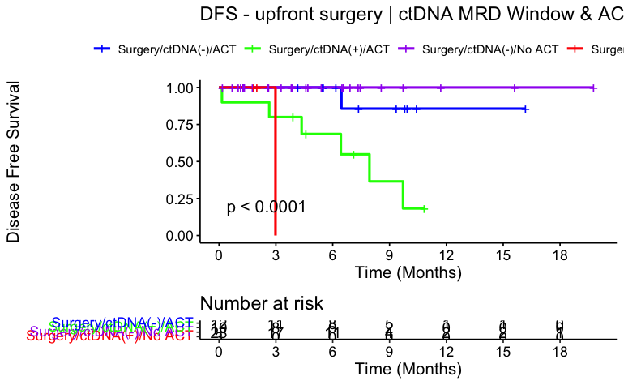

```r
surv_object <-Surv(time = circ_data$RFS_months, event = circ_data$RecStatus)
KM_curve <- survfit(surv_object ~ ctDNA.MRD.ACT, data = circ_data,conf.int=0.95,conf.type="log-log")
ggsurvplot(KM_curve, data = circ_data, pval = TRUE, conf.int = FALSE, risk.table = TRUE, break.time.by=3, palette=c("blue","green","purple", "red"), title="DFS - upfront surgery | ctDNA MRD Window & ACT", ylab= "Disease Free Survival", xlab="Time (Months)", legend.labs=c("Surgery/ctDNA(-)/ACT", "Surgery/ctDNA(+)/ACT","Surgery/ctDNA(-)/No ACT", "Surgery/ctDNA(+)/No ACT"), legend.title="")
```

```r
summary(KM_curve, times= c(0, 12))
```

```
Call: survfit(formula = surv_object ~ ctDNA.MRD.ACT, data = circ_data,
    conf.int = 0.95, conf.type = "log-log")

                ctDNA.MRD.ACT=1
 time n.risk n.event survival std.err lower 95% CI upper 95% CI
    0     12       0    1.000   0.000        1.000        1.000
   12      1       1    0.857   0.132        0.334        0.979

                ctDNA.MRD.ACT=2
        time       n.risk      n.event     survival      std.err lower 95% CI upper 95% CI
           0           10            0            1            0            1            1

                ctDNA.MRD.ACT=3
 time n.risk n.event survival std.err lower 95% CI upper 95% CI
    0     28       0        1       0            1            1
   12      2       0        1       0           NA           NA

                ctDNA.MRD.ACT=4
        time       n.risk      n.event     survival      std.err lower 95% CI upper 95% CI
           0            3            0            1            0            1            1
```

```r
circ_data$ctDNA.MRD.ACT <- factor(circ_data$ctDNA.MRD.ACT, levels=c("3","1","2","4"), labels = c("Surgery/ctDNA(-)/No ACT", "Surgery/ctDNA(-)/ACT", "Surgery/ctDNA(+)/ACT","Surgery/ctDNA(+)/No ACT"))
cox_fit <- coxphf(surv_object ~ ctDNA.MRD.ACT, data=circ_data)
summary(cox_fit)
```

```
coxphf(formula = surv_object ~ ctDNA.MRD.ACT, data = circ_data)

Model fitted by Penalized ML
Confidence intervals and p-values by Profile Likelihood

                                         coef se(coef)  exp(coef) lower 0.95 upper 0.95     Chisq            p
ctDNA.MRD.ACTSurgery/ctDNA(-)/ACT    1.432413 1.808206   4.188794  0.2223477   612.4505        NA           NA
ctDNA.MRD.ACTSurgery/ctDNA(+)/ACT    3.328899 1.624080  27.907593  3.2877062  3642.8277 11.618317 0.0006530547
ctDNA.MRD.ACTSurgery/ctDNA(+)/No ACT 4.747665 1.952362 115.314659  5.2126757 18351.1060  8.247302 0.0040812617

Likelihood ratio test=17.19688 on 3 df, p=0.0006438114, n=53
Wald test = 9.365 on 3 df, p = 0.02481176

Covariance-Matrix:
                                     ctDNA.MRD.ACTSurgery/ctDNA(-)/ACT ctDNA.MRD.ACTSurgery/ctDNA(+)/ACT ctDNA.MRD.ACTSurgery/ctDNA(+)/No ACT
ctDNA.MRD.ACTSurgery/ctDNA(-)/ACT                             3.269608                          2.449825                             2.412426
ctDNA.MRD.ACTSurgery/ctDNA(+)/ACT                             2.449825                          2.637637                             2.438056
ctDNA.MRD.ACTSurgery/ctDNA(+)/No ACT                          2.412426                          2.438056                             3.811716
```

#Prognostic role of ctDNA at the Surveillance Window (>12 weeks post-RC or anytime after AT)

```r
rm(list=ls())
setwd("~/Downloads")
circ_data <- read.csv("RWE_MIBC Combined.csv")
circ_data <- circ_data[circ_data$ctDNA.Available=="TRUE",]
circ_data <- circ_data[circ_data$FU_months>=3,]

survfit(Surv(time = circ_data$RFS_months, event = circ_data$RecStatus)~MRD.Surveillance.Window, data = circ_data)
```

```
Call: survfit(formula = Surv(time = circ_data$RFS_months, event = circ_data$RecStatus) ~
    MRD.Surveillance.Window, data = circ_data)

   50 observations deleted due to missingness
                           n events median 0.95LCL 0.95UCL
MRD.Surveillance.Window=0 65      2     NA      NA      NA
MRD.Surveillance.Window=1 52     33   14.1    10.1    18.5
```

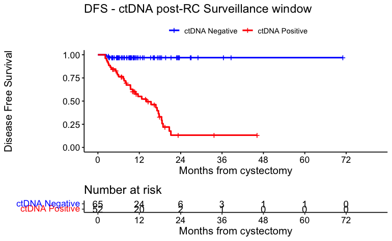

```r
surv_object <-Surv(time = circ_data$RFS_months, event = circ_data$RecStatus)
KM_curve <- survfit(surv_object ~ MRD.Surveillance.Window, data = circ_data,conf.int=0.95,conf.type="log-log")
ggsurvplot(KM_curve, data = circ_data, pval = FALSE, conf.int = FALSE, risk.table = TRUE, break.time.by=12, palette=c("blue","red"), title="DFS - ctDNA post-RC Surveillance window", ylab= "Disease Free Survival", xlab="Months from cystectomy", legend.labs=c("ctDNA Negative", "ctDNA Positive"), legend.title="")
```

```r
summary(KM_curve, times= c(12, 24))
```

```
Call: survfit(formula = surv_object ~ MRD.Surveillance.Window, data = circ_data,
    conf.int = 0.95, conf.type = "log-log")

50 observations deleted due to missingness
                MRD.Surveillance.Window=0
 time n.risk n.event survival std.err lower 95% CI upper 95% CI
   12     24       2    0.969  0.0216        0.882        0.992
   24      6       0    0.969  0.0216        0.882        0.992

                MRD.Surveillance.Window=1
 time n.risk n.event survival std.err lower 95% CI upper 95% CI
   12     20      21    0.550  0.0747        0.393        0.682
   24      2      12    0.132  0.0656        0.038        0.286
```

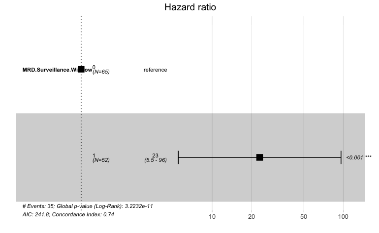

```r
circ_data$MRD.Surveillance.Window <- factor(circ_data$MRD.Surveillance.Window, levels=c("0","1"))
cox_fit <- coxph(surv_object ~ MRD.Surveillance.Window, data=circ_data)
ggforest(cox_fit,data = circ_data)
```

```r
summary(cox_fit)
```

```
Call:
coxph(formula = surv_object ~ MRD.Surveillance.Window, data = circ_data)

  n= 117, number of events= 35
   (50 observations deleted due to missingness)

                            coef exp(coef) se(coef)   z Pr(>|z|)
MRD.Surveillance.Window1  3.1366   23.0244   0.7294 4.3  1.7e-05 ***
---
Signif. codes:  0 ‘***’ 0.001 ‘**’ 0.01 ‘*’ 0.05 ‘.’ 0.1 ‘ ’ 1

                         exp(coef) exp(-coef) lower .95 upper .95
MRD.Surveillance.Window1     23.02    0.04343     5.513     96.17

Concordance= 0.741  (se = 0.038 )
Likelihood ratio test= 44.04  on 1 df,   p=3e-11
Wald test            = 18.49  on 1 df,   p=2e-05
Score (logrank) test = 39.08  on 1 df,   p=4e-10
```

```r
cox_fit_summary <- summary(cox_fit)

# Extract values for HR, 95% CI, and p-value
HR <- cox_fit_summary$coefficients[2]
lower_CI <- cox_fit_summary$conf.int[3]
upper_CI <- cox_fit_summary$conf.int[4]
p_value <- cox_fit_summary$coefficients[5]
label_text <- paste0("HR = ", round(HR, 2), " (", round(lower_CI, 2), "-", round(upper_CI, 2), "); p = ", round(p_value, 3))
print(label_text)
```

```
[1] "HR = 23.02 (5.51-96.17); p = 0"
```

```r
# Fisher plot for ctDNA at the Surveillance window - >12 weeks & anytime postACT and Rec Status
circ_data$MRD.Surveillance.Window <- factor(circ_data$MRD.Surveillance.Window, levels = c("0", "1"), labels = c("ctDNA(-)", "ctDNA(+)"))
circ_data$RecStatus <- factor(circ_data$RecStatus, levels = c("0", "1"), labels = c("No Recurrence", "Recurrence"))
contingency_table <- table(circ_data$MRD.Surveillance.Window, circ_data$RecStatus)
chi_square_test <- chisq.test(contingency_table)
print(chi_square_test)
```

```
    Pearson's Chi-squared test with Yates' continuity correction

data:  contingency_table
X-squared = 47.404, df = 1, p-value = 5.777e-12
```

```r
fisher_exact_test <- fisher.test(contingency_table)
print(fisher_exact_test)
```

```
    Fisher's Exact Test for Count Data

data:  contingency_table
p-value = 2e-13
alternative hypothesis: true odds ratio is not equal to 1
95 percent confidence interval:
  11.69937 490.58744
sample estimates:
odds ratio
  52.45581
```

```r
print(contingency_table)
```

```
           No Recurrence Recurrence
  ctDNA(-)            63          2
  ctDNA(+)            19         33
```

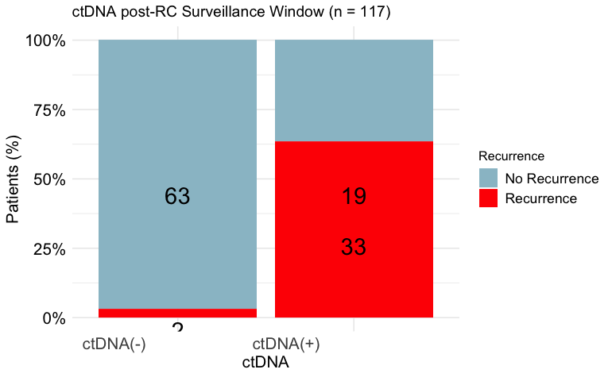

```r
table_df <- as.data.frame(contingency_table)
table_df$Total <- ave(table_df$Freq, table_df$Var1, FUN = sum)
table_df$Percentage <- table_df$Freq / table_df$Total
table_df$MiddlePercentage <- table_df$Percentage / 2
ggplot(table_df, aes(x = Var1, y = Percentage, fill = Var2)) +
  geom_bar(stat = "identity") +
  geom_text(aes(y = MiddlePercentage, label = Freq), position = "stack", color = "black", vjust = 1.5, size = 7) +
  theme_minimal() +
  labs(title = "ctDNA post-RC Surveillance Window (n = 117)", x = "ctDNA", y = "Patients (%)", fill = "Recurrence") +
  scale_y_continuous(labels = scales::percent_format()) +
  scale_fill_manual(values = c("No Recurrence" = "lightblue3", "Recurrence" = "red")) + # define custom colors
  theme(axis.text.x = element_text(angle = 0, hjust = 1.5, size = 14), # increase x-axis text size
        axis.text.y = element_text(size = 14, color = "black"), # increase y-axis text size
        axis.title.x = element_text(size = 14, color = "black"), # increase x-axis label size
        axis.title.y = element_text(size = 14, color = "black"), # increase y-axis label size
        legend.text = element_text(size = 12, color = "black"))  # increase Recurrence label size
```

#Multivariate regression model for DFS at the Surveillance Window

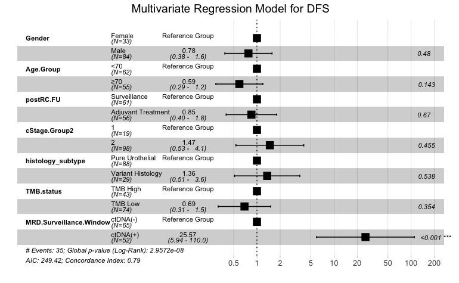

```r
rm(list=ls())
setwd("~/Downloads")
circ_data <- read.csv("RWE_MIBC Combined.csv")
circ_datadf <- as.data.frame(circ_data)
circ_data <- circ_data[circ_data$ctDNA.Available=="TRUE",]
circ_data <- circ_data[circ_data$FU_months>=3,]
circ_data <- subset(circ_data, !is.na(MRD.Surveillance.Window))
circ_datadf <- as.data.frame(circ_data)

circ_datadf$Gender <- factor(circ_datadf$Gender, levels = c("Female", "Male"), labels = c("Female", "Male"))
circ_datadf$Age.Group <- factor(circ_datadf$Age.Group, levels = c("0", "1"), labels = c("<70", "≥70"))
circ_datadf$postRC.FU <- factor(circ_datadf$postRC.FU, levels = c("1", "2"), labels = c("Surveillance", "Adjuvant Treatment"))
circ_datadf$NAC <- factor(circ_datadf$NAC, levels = c("1", "0"), labels = c("NAT", "Upfront Surgery"))
circ_datadf$cStage.Group2 <- factor(circ_datadf$cStage.Group2, levels = c("1", "2"))
circ_datadf$histology_subtype <- factor(circ_datadf$histology_subtype, levels = c("Pure", "VH"), labels = c("Pure Urothelial", "Variant Histology"))
circ_datadf$TMB.status <- factor(circ_datadf$TMB.status, levels = c("TMB-High", "TMB-Low"), labels = c("TMB High", "TMB Low"))
circ_datadf$MRD.Surveillance.Window <- factor(circ_datadf$MRD.Surveillance.Window, levels = c("0", "1"), labels = c("ctDNA(-)", "ctDNA(+)"))
surv_object<-Surv(time = circ_datadf$RFS_months, event = circ_datadf$RecStatus)
cox_fit <- coxph(surv_object ~ Gender + Age.Group + postRC.FU + cStage.Group2 + histology_subtype + TMB.status + MRD.Surveillance.Window, data=circ_datadf)
ggforest(cox_fit, data = circ_datadf, main = "Multivariate Regression Model for DFS", refLabel = "Reference Group")
```

```r
test.ph <- cox.zph(cox_fit)
```

#Univariate regression models for DFS for the factors used in the MVA

```r
rm(list=ls())
setwd("~/Downloads")
circ_data <- read.csv("RWE_MIBC Combined.csv")
circ_data <- circ_data[circ_data$ctDNA.Available=="TRUE",]
circ_data <- circ_data[circ_data$FU_months>=3,]
circ_data <- subset(circ_data, !is.na(MRD.Surveillance.Window))
circ_datadf <- as.data.frame(circ_data)
surv_object <-Surv(time = circ_data$RFS_months, event = circ_data$RecStatus)
circ_datadf$Gender <- factor(circ_datadf$Gender, levels = c("Female", "Male"), labels = c("Female", "Male")) #univariate for gender
cox_fit <- coxph(surv_object ~ Gender, data=circ_data)
summary(cox_fit)
```

```
Call:
coxph(formula = surv_object ~ Gender, data = circ_data)

  n= 117, number of events= 35

              coef exp(coef) se(coef)      z Pr(>|z|)
GenderMale -0.7200    0.4868   0.3402 -2.116   0.0343 *
---
Signif. codes:  0 ‘***’ 0.001 ‘**’ 0.01 ‘*’ 0.05 ‘.’ 0.1 ‘ ’ 1

           exp(coef) exp(-coef) lower .95 upper .95
GenderMale    0.4868      2.054    0.2499    0.9482

Concordance= 0.56  (se = 0.045 )
Likelihood ratio test= 4.3  on 1 df,   p=0.04
Wald test            = 4.48  on 1 df,   p=0.03
Score (logrank) test = 4.67  on 1 df,   p=0.03
```

```r
cox_fit_summary <- summary(cox_fit)
HR <- cox_fit_summary$coefficients[2]
lower_CI <- cox_fit_summary$conf.int[3]
upper_CI <- cox_fit_summary$conf.int[4]
p_value <- cox_fit_summary$coefficients[5]
label_text <- paste0("HR = ", round(HR, 2), " (", round(lower_CI, 2), "-", round(upper_CI, 2), "); p = ", round(p_value, 3))
print(label_text)
```

```
[1] "HR = 0.49 (0.25-0.95); p = 0.034"
```

```r
rm(list=ls())
setwd("~/Downloads")
circ_data <- read.csv("RWE_MIBC Combined.csv")
circ_data <- circ_data[circ_data$ctDNA.Available=="TRUE",]
circ_data <- circ_data[circ_data$FU_months>=3,]
circ_data <- subset(circ_data, !is.na(MRD.Surveillance.Window))
circ_datadf <- as.data.frame(circ_data)
surv_object <-Surv(time = circ_data$RFS_months, event = circ_data$RecStatus)
circ_datadf$Age.Group <- factor(circ_datadf$Age.Group, levels = c("0", "1"), labels = c("<70", "≥70")) #univariate for age group
cox_fit <- coxph(surv_object ~ Age.Group, data=circ_data)
summary(cox_fit)
```

```
Call:
coxph(formula = surv_object ~ Age.Group, data = circ_data)

  n= 117, number of events= 35

             coef exp(coef) se(coef)     z Pr(>|z|)
Age.Group -0.2112    0.8096   0.3406 -0.62    0.535

          exp(coef) exp(-coef) lower .95 upper .95
Age.Group    0.8096      1.235    0.4153     1.578

Concordance= 0.544  (se = 0.047 )
Likelihood ratio test= 0.39  on 1 df,   p=0.5
Wald test            = 0.38  on 1 df,   p=0.5
Score (logrank) test = 0.39  on 1 df,   p=0.5
```

```r
cox_fit_summary <- summary(cox_fit)
HR <- cox_fit_summary$coefficients[2]
lower_CI <- cox_fit_summary$conf.int[3]
upper_CI <- cox_fit_summary$conf.int[4]
p_value <- cox_fit_summary$coefficients[5]
label_text <- paste0("HR = ", round(HR, 2), " (", round(lower_CI, 2), "-", round(upper_CI, 2), "); p = ", round(p_value, 3))
print(label_text)
```

```
[1] "HR = 0.81 (0.42-1.58); p = 0.535"
```

```r
rm(list=ls())
setwd("~/Downloads")
circ_data <- read.csv("RWE_MIBC Combined.csv")
circ_data <- circ_data[circ_data$ctDNA.Available=="TRUE",]
circ_data <- circ_data[circ_data$FU_months>=3,]
circ_data <- subset(circ_data, !is.na(MRD.Surveillance.Window))
circ_datadf <- as.data.frame(circ_data)
surv_object <-Surv(time = circ_data$RFS_months, event = circ_data$RecStatus)
circ_datadf$NAC <- factor(circ_datadf$NAC, levels = c("1", "2"), labels = c("Surveillance", "Adjuvant Treatment")) #univariate for NAC
cox_fit <- coxph(surv_object ~ NAC, data=circ_data)
summary(cox_fit)
```

```
Call:
coxph(formula = surv_object ~ NAC, data = circ_data)

  n= 117, number of events= 35

      coef exp(coef) se(coef)     z Pr(>|z|)
NAC 0.3512    1.4208   0.3425 1.026    0.305

    exp(coef) exp(-coef) lower .95 upper .95
NAC     1.421     0.7038    0.7261      2.78

Concordance= 0.566  (se = 0.048 )
Likelihood ratio test= 1.03  on 1 df,   p=0.3
Wald test            = 1.05  on 1 df,   p=0.3
Score (logrank) test = 1.06  on 1 df,   p=0.3
```

```r
cox_fit_summary <- summary(cox_fit)
HR <- cox_fit_summary$coefficients[2]
lower_CI <- cox_fit_summary$conf.int[3]
upper_CI <- cox_fit_summary$conf.int[4]
p_value <- cox_fit_summary$coefficients[5]
label_text <- paste0("HR = ", round(HR, 2), " (", round(lower_CI, 2), "-", round(upper_CI, 2), "); p = ", round(p_value, 3))
print(label_text)
```

```
[1] "HR = 1.42 (0.73-2.78); p = 0.305"
```

```r
rm(list=ls())
setwd("~/Downloads")
circ_data <- read.csv("RWE_MIBC Combined.csv")
circ_data <- circ_data[circ_data$ctDNA.Available=="TRUE",]
circ_data <- circ_data[circ_data$FU_months>=3,]
circ_data <- subset(circ_data, !is.na(MRD.Surveillance.Window))
circ_datadf <- as.data.frame(circ_data)
surv_object <-Surv(time = circ_data$RFS_months, event = circ_data$RecStatus)
circ_datadf$postRC.FU <- factor(circ_datadf$postRC.FU, levels = c("1", "2"), labels = c("Surveillance", "Adjuvant Treatment")) #univariate for AT
cox_fit <- coxph(surv_object ~ postRC.FU, data=circ_data)
summary(cox_fit)
```

```
Call:
coxph(formula = surv_object ~ postRC.FU, data = circ_data)

  n= 117, number of events= 35

            coef exp(coef) se(coef)     z Pr(>|z|)
postRC.FU 0.1977    1.2186   0.3431 0.576    0.565

          exp(coef) exp(-coef) lower .95 upper .95
postRC.FU     1.219     0.8206     0.622     2.387

Concordance= 0.547  (se = 0.047 )
Likelihood ratio test= 0.33  on 1 df,   p=0.6
Wald test            = 0.33  on 1 df,   p=0.6
Score (logrank) test = 0.33  on 1 df,   p=0.6
```

```r
cox_fit_summary <- summary(cox_fit)
HR <- cox_fit_summary$coefficients[2]
lower_CI <- cox_fit_summary$conf.int[3]
upper_CI <- cox_fit_summary$conf.int[4]
p_value <- cox_fit_summary$coefficients[5]
label_text <- paste0("HR = ", round(HR, 2), " (", round(lower_CI, 2), "-", round(upper_CI, 2), "); p = ", round(p_value, 3))
print(label_text)
```

```
[1] "HR = 1.22 (0.62-2.39); p = 0.565"
```

```r
rm(list=ls())
setwd("~/Downloads")
circ_data <- read.csv("RWE_MIBC Combined.csv")
circ_data <- circ_data[circ_data$ctDNA.Available=="TRUE",]
circ_data <- circ_data[circ_data$FU_months>=3,]
circ_data <- subset(circ_data, !is.na(MRD.Surveillance.Window))
circ_datadf <- as.data.frame(circ_data)
surv_object <-Surv(time = circ_data$RFS_months, event = circ_data$RecStatus)
circ_datadf$cStage.Group2 <- factor(circ_datadf$cStage.Group2, levels = c("1", "2")) #univariate for clinical stage
cox_fit <- coxph(surv_object ~ cStage.Group2, data=circ_data)
summary(cox_fit)
```

```
Call:
coxph(formula = surv_object ~ cStage.Group2, data = circ_data)

  n= 117, number of events= 35

                coef exp(coef) se(coef)    z Pr(>|z|)
cStage.Group2 0.2855    1.3304   0.4836 0.59    0.555

              exp(coef) exp(-coef) lower .95 upper .95
cStage.Group2      1.33     0.7517    0.5156     3.433

Concordance= 0.548  (se = 0.024 )
Likelihood ratio test= 0.37  on 1 df,   p=0.5
Wald test            = 0.35  on 1 df,   p=0.6
Score (logrank) test = 0.35  on 1 df,   p=0.6
```

```r
cox_fit_summary <- summary(cox_fit)
HR <- cox_fit_summary$coefficients[2]
lower_CI <- cox_fit_summary$conf.int[3]
upper_CI <- cox_fit_summary$conf.int[4]
p_value <- cox_fit_summary$coefficients[5]
label_text <- paste0("HR = ", round(HR, 2), " (", round(lower_CI, 2), "-", round(upper_CI, 2), "); p = ", round(p_value, 3))
print(label_text)
```

```
[1] "HR = 1.33 (0.52-3.43); p = 0.555"
```

```r
rm(list=ls())
setwd("~/Downloads")
circ_data <- read.csv("RWE_MIBC Combined.csv")
circ_data <- circ_data[circ_data$ctDNA.Available=="TRUE",]
circ_data <- circ_data[circ_data$FU_months>=3,]
circ_data <- subset(circ_data, !is.na(MRD.Surveillance.Window))
circ_datadf <- as.data.frame(circ_data)
surv_object <-Surv(time = circ_data$RFS_months, event = circ_data$RecStatus)
circ_datadf$histology_subtype <- factor(circ_datadf$histology_subtype, levels = c("Pure", "VH"), labels = c("Pure Urothelial", "Variant Histology")) #univariate for histology subtype
cox_fit <- coxph(surv_object ~ histology_subtype, data=circ_data)
summary(cox_fit)
```

```
Call:
coxph(formula = surv_object ~ histology_subtype, data = circ_data)

  n= 117, number of events= 35

                       coef exp(coef) se(coef)     z Pr(>|z|)
histology_subtypeVH 0.08762   1.09157  0.38727 0.226    0.821

                    exp(coef) exp(-coef) lower .95 upper .95
histology_subtypeVH     1.092     0.9161     0.511     2.332

Concordance= 0.53  (se = 0.044 )
Likelihood ratio test= 0.05  on 1 df,   p=0.8
Wald test            = 0.05  on 1 df,   p=0.8
Score (logrank) test = 0.05  on 1 df,   p=0.8
```

```r
cox_fit_summary <- summary(cox_fit)
HR <- cox_fit_summary$coefficients[2]
lower_CI <- cox_fit_summary$conf.int[3]
upper_CI <- cox_fit_summary$conf.int[4]
p_value <- cox_fit_summary$coefficients[5]
label_text <- paste0("HR = ", round(HR, 2), " (", round(lower_CI, 2), "-", round(upper_CI, 2), "); p = ", round(p_value, 3))
print(label_text)
```

```
[1] "HR = 1.09 (0.51-2.33); p = 0.821"
```

```r
rm(list=ls())
setwd("~/Downloads")
circ_data <- read.csv("RWE_MIBC Combined.csv")
circ_data <- circ_data[circ_data$ctDNA.Available=="TRUE",]
circ_data <- circ_data[circ_data$FU_months>=3,]
circ_data <- subset(circ_data, !is.na(MRD.Surveillance.Window))
circ_datadf <- as.data.frame(circ_data)
surv_object <-Surv(time = circ_data$RFS_months, event = circ_data$RecStatus)
circ_datadf$TMB.status <- factor(circ_datadf$TMB.status, levels = c("TMB-High", "TMB-Low"), labels = c("TMB High", "TMB Low")) #univariate for TMB
cox_fit <- coxph(surv_object ~ TMB.status, data=circ_data)
summary(cox_fit)
```

```
Call:
coxph(formula = surv_object ~ TMB.status, data = circ_data)

  n= 117, number of events= 35

                      coef exp(coef) se(coef)      z Pr(>|z|)
TMB.statusTMB-Low -0.01323   0.98686  0.35096 -0.038     0.97

                  exp(coef) exp(-coef) lower .95 upper .95
TMB.statusTMB-Low    0.9869      1.013     0.496     1.963

Concordance= 0.515  (se = 0.047 )
Likelihood ratio test= 0  on 1 df,   p=1
Wald test            = 0  on 1 df,   p=1
Score (logrank) test = 0  on 1 df,   p=1
```

```r
cox_fit_summary <- summary(cox_fit)
HR <- cox_fit_summary$coefficients[2]
lower_CI <- cox_fit_summary$conf.int[3]
upper_CI <- cox_fit_summary$conf.int[4]
p_value <- cox_fit_summary$coefficients[5]
label_text <- paste0("HR = ", round(HR, 2), " (", round(lower_CI, 2), "-", round(upper_CI, 2), "); p = ", round(p_value, 3))
print(label_text)
```

```
[1] "HR = 0.99 (0.5-1.96); p = 0.97"
```

```r
rm(list=ls())
setwd("~/Downloads")
circ_data <- read.csv("RWE_MIBC Combined.csv")
circ_data <- circ_data[circ_data$ctDNA.Available=="TRUE",]
circ_data <- circ_data[circ_data$FU_months>=3,]
circ_data <- subset(circ_data, !is.na(MRD.Surveillance.Window))
circ_datadf <- as.data.frame(circ_data)
surv_object <-Surv(time = circ_data$RFS_months, event = circ_data$RecStatus)
circ_data$MRD.Surveillance.Window <- factor(circ_data$MRD.Surveillance.Window, levels=c("0","1")) #univariate for ctDNA surveillance window
cox_fit <- coxph(surv_object ~ MRD.Surveillance.Window, data=circ_data)
summary(cox_fit)
```

```
Call:
coxph(formula = surv_object ~ MRD.Surveillance.Window, data = circ_data)

  n= 117, number of events= 35

                            coef exp(coef) se(coef)   z Pr(>|z|)
MRD.Surveillance.Window1  3.1366   23.0244   0.7294 4.3  1.7e-05 ***
---
Signif. codes:  0 ‘***’ 0.001 ‘**’ 0.01 ‘*’ 0.05 ‘.’ 0.1 ‘ ’ 1

                         exp(coef) exp(-coef) lower .95 upper .95
MRD.Surveillance.Window1     23.02    0.04343     5.513     96.17

Concordance= 0.741  (se = 0.038 )
Likelihood ratio test= 44.04  on 1 df,   p=3e-11
Wald test            = 18.49  on 1 df,   p=2e-05
Score (logrank) test = 39.08  on 1 df,   p=4e-10
```

```r
cox_fit_summary <- summary(cox_fit)
HR <- cox_fit_summary$coefficients[2]
lower_CI <- cox_fit_summary$conf.int[3]
upper_CI <- cox_fit_summary$conf.int[4]
p_value <- cox_fit_summary$coefficients[5]
label_text <- paste0("HR = ", round(HR, 2), " (", round(lower_CI, 2), "-", round(upper_CI, 2), "); p = ", round(p_value, 3))
print(label_text)
```

```
[1] "HR = 23.02 (5.51-96.17); p = 0"
```

#Time-dependent cox regression analysis for surveillance window

```r
rm(list=ls())
setwd("~/Downloads")
dt <- read_xlsx("RWE_MIBC Time Dependent Data.xlsx") |>
  clean_names() |>
  mutate(window_start_date = surveillance_1_date) |>
  mutate(across(.cols = c(window_start_date,dfs_date,
                surveillance_1_date:surveillance_12_date),
                .fns = ~ as_date(as.Date(.x, format = "%Y-%m-%d"))))

dt_biomarker <- dt |>
  select(pts_id, ct_dna_surveillance_available,
         window_start_date,
         surveillance_1_status:surveillance_12_date) |>
  filter(ct_dna_surveillance_available) |>
  pivot_longer(cols = surveillance_1_status:surveillance_12_date,
               names_to = c("visit_number", ".value"),
               names_pattern = "surveillance_(.)_(.*)") |>
  mutate(biomarker_time = day(days(date - window_start_date))) |>
  select(pts_id, biomarker_time, biomarker_status = status) |>
  filter(!is.na(biomarker_time))

glimpse(dt_biomarker)
```

```
Rows: 351
Columns: 3
$ pts_id           <dbl> 1, 1, 3, 3, 3, 3, 3, 3, 3, 3, 3, 4, 4, 4, 4, 6, 6, 6, 6, 6, 6, 6, 6, 6, 13, 19, 23, 24, 24, 26, 26, 26, 27, 27, 27, 27, 27, 27, …
$ biomarker_time   <dbl> 0, 133, 0, 41, 78, 118, 161, 201, 238, 266, 304, 0, 90, 167, 235, 0, 36, 78, 119, 160, 202, 251, 295, 325, 0, 0, 0, 0, 69, 0, 51…
$ biomarker_status <chr> "NEGATIVE", "NEGATIVE", "POSITIVE", "POSITIVE", "POSITIVE", "POSITIVE", "POSITIVE", "POSITIVE", "POSITIVE", "POSITIVE", "POSITIV…
```

```r
dt_survival <- dt |>
  select(pts_id, ct_dna_surveillance_available,
         window_start_date:dfs_date) |>
  filter(ct_dna_surveillance_available) |>
  mutate(dfs_time = (dfs_date - window_start_date),
         dfs_time = day(days(dfs_time)),
         dfs_event = as.numeric(dfs_event)) |>
  select(pts_id, dfs_time, dfs_event)

glimpse(dt_survival)
```

```
Rows: 134
Columns: 3
$ pts_id    <dbl> 1, 3, 4, 6, 13, 19, 23, 24, 26, 27, 30, 31, 32, 35, 36, 38, 39, 40, 41, 43, 44, 45, 47, 48, 50, 51, 53, 54, 55, 59, 60, 65, 66, 67, 71,…
$ dfs_time  <dbl> 132, 0, 149, 415, 168, 10, -92, 0, 204, 395, 125, 522, 30, 473, -41, 441, 417, 155, 95, 268, 175, -20, 367, 273, 214, 89, -287, 168, 42…
$ dfs_event <dbl> 0, 1, 0, 1, 0, 0, 0, 1, 0, 0, 0, 1, 0, 0, 1, 0, 0, 1, 1, 0, 0, 1, 0, 0, 0, 0, 1, 0, 0, 0, 0, 0, 0, 0, 1, 0, 0, 1, 0, 1, 0, 0, 0, 1, 0, …
```

```r
aux <- dt_survival %>%
  filter(dfs_time <= 0)

tab <- left_join(aux, dt) |>
  select(pts_id, window_start_date, dfs_time, dfs_date,
         surveillance_1_date:surveillance_12_date) |>
  mutate(across(.cols = dfs_date:surveillance_12_date,
                .fns = ~ as_date(.x))) |>
  select(pts_id, window_start_date, dfs_date, dfs_time)
datatable(tab, filter = "top")
```

|  | pts_id | window_start_date | dfs_date | dfs_time |
| --- | --- | --- | --- | --- |
| 1 | 3 | 2021-11-19 | 2021-11-19 | 0 |
| 2 | 23 | 2022-09-22 | 2022-06-22 | -92 |
| 3 | 24 | 2022-09-28 | 2022-09-28 | 0 |
| 4 | 36 | 2022-03-28 | 2022-02-15 | -41 |
| 5 | 45 | 2021-12-07 | 2021-11-17 | -20 |
| 6 | 53 | 2022-02-04 | 2021-04-23 | -287 |
| 7 | 67 | 2023-01-12 | 2023-01-12 | 0 |
| 8 | 76 | 2023-01-11 | 2022-03-30 | -287 |
| 9 | 81 | 2023-01-05 | 2023-01-05 | 0 |
| 10 | 82 | 2022-10-03 | 2022-09-14 | -19 |

[output cut: 17 more lines]

```r
dt_survival <- dt_survival |>
  filter(dfs_time > 0)

aux <- dt |>
  select(pts_id, ct_dna_surveillance_available,
         window_start_date, dfs_date,
         surveillance_1_date:surveillance_12_date) |>
  mutate(across(.cols = surveillance_1_date:surveillance_12_date,
                .fns = ~ .x - window_start_date)) |>
  mutate(across(.cols = surveillance_1_date:surveillance_12_date,
                .fns = ~ .x < 0)) |>
  rowwise() |>
   mutate(sum_neg =
           sum(c_across(surveillance_1_date:surveillance_12_date),
               na.rm = TRUE))  |>
  select(pts_id, sum_neg)

tab <- left_join(aux, dt) |>
  filter(sum_neg > 0) |>
  select(pts_id, sum_neg, window_start_date,
         surveillance_1_date:surveillance_12_date) |>
  mutate(across(.cols = window_start_date:surveillance_12_date,
                .fns = ~ as_date(.x)))
datatable(tab, filter = "top")
```

|  | pts_id | sum_neg | window_start_date | surveillance_1_date | surveillance_2_date | surveillance_3_date | surveillance_4_date | surveillance_5_date | surveillance_6_date | surveillance_7_date | surveillance_8_date | surveillance_9_date | surveillance_10_date | surveillance_11_date | surveillance_12_date |
| --- | --- | --- | --- | --- | --- | --- | --- | --- | --- | --- | --- | --- | --- | --- | --- |

```r
aux <- dt |>
  select(pts_id, ct_dna_surveillance_available,
         window_start_date, dfs_date,
         surveillance_1_date:surveillance_12_date) |>
  mutate(across(.cols = dfs_date:surveillance_12_date,
                .fns = ~ .x - window_start_date)) |>
  mutate(across(.cols = surveillance_2_date:surveillance_12_date,
                .fns = ~ dfs_date < .x)) |>
  rowwise() |>
  mutate(n_biomarker_after_event = sum(c_across(surveillance_2_date:
                              surveillance_12_date),
                   na.rm = TRUE)) |>
  mutate(across(.cols = surveillance_1_date:surveillance_12_date,
                .fns = ~ !is.na(.x))) |>
  mutate(total_biomarker = sum(c_across(surveillance_2_date:
                              surveillance_12_date),
                   na.rm = TRUE)) |>
  select(pts_id, n_biomarker_after_event, total_biomarker)

temp <- aux |>
  select(-pts_id) |>
  group_by(n_biomarker_after_event, total_biomarker) |>
  dplyr::summarize(freq = n())
tab <- left_join(aux, dt) |>
  select(pts_id, n_biomarker_after_event, total_biomarker,
         dfs_date,
         surveillance_2_date:surveillance_12_date) |>
  mutate(across(.cols = dfs_date:surveillance_12_date,
                .fns = ~ as_date(.x))) |>
  filter(n_biomarker_after_event > 0)
datatable(tab, filter = "top")
```

|  | pts_id | n_biomarker_after_event | total_biomarker | dfs_date | surveillance_2_date | surveillance_3_date | surveillance_4_date | surveillance_5_date | surveillance_6_date | surveillance_7_date | surveillance_8_date | surveillance_9_date | surveillance_10_date | surveillance_11_date | surveillance_12_date |
| --- | --- | --- | --- | --- | --- | --- | --- | --- | --- | --- | --- | --- | --- | --- | --- |
| 1 | 1 | 1 | 1 | 2022-10-12 | 2022-10-13 |  |  |  |  |  |  |  |  |  |  |
| 2 | 3 | 11 | 11 | 2021-11-19 | 2021-12-30 | 2022-02-05 | 2022-03-17 | 2022-04-29 | 2022-06-08 | 2022-07-15 | 2022-08-12 | 2022-09-19 | 2022-10-28 | 2022-12-05 | 2023-01-13 |
| 3 | 4 | 2 | 3 | 2022-09-23 | 2022-07-26 | 2022-10-11 | 2022-12-18 |  |  |  |  |  |  |  |  |
| 4 | 24 | 1 | 1 | 2022-09-28 | 2022-12-06 |  |  |  |  |  |  |  |  |  |  |
| 5 | 36 | 3 | 3 | 2022-02-15 | 2022-04-23 | 2022-06-04 | 2022-07-23 |  |  |  |  |  |  |  |  |
| 6 | 53 | 1 | 1 | 2021-04-23 | 2022-04-01 |  |  |  |  |  |  |  |  |  |  |
| 7 | 82 | 1 | 1 | 2022-09-14 | 2022-11-06 |  |  |  |  |  |  |  |  |  |  |
| 8 | 88 | 1 | 1 | 2022-08-02 | 2022-08-09 |  |  |  |  |  |  |  |  |  |  |
| 9 | 91 | 2 | 2 | 2022-09-15 | 2022-09-21 | 2023-01-18 |  |  |  |  |  |  |  |  |  |
| 10 | 95 | 1 | 1 | 2022-07-14 | 2022-10-20 |  |  |  |  |  |  |  |  |  |  |

[output cut: 12 more lines]

```r
aux <- tmerge(data1 = dt_survival,
              data2 = dt_survival,
              id = pts_id,
              dfs_event = event(dfs_time, dfs_event))
dt_final <- tmerge(data1 = aux,
                   data2 = dt_biomarker,
                   id = pts_id,
                   biomarker_status =
                     tdc(biomarker_time, biomarker_status))

datatable(dt_final, filter = "top")
```

|  | pts_id | dfs_time | dfs_event | tstart | tstop | biomarker_status |
| --- | --- | --- | --- | --- | --- | --- |
| 1 | 1 | 132 | 0 | 0 | 132 | NEGATIVE |
| 2 | 4 | 149 | 0 | 0 | 90 | NEGATIVE |
| 3 | 4 | 149 | 0 | 90 | 149 | NEGATIVE |
| 4 | 6 | 415 | 0 | 0 | 36 | POSITIVE |
| 5 | 6 | 415 | 0 | 36 | 78 | POSITIVE |
| 6 | 6 | 415 | 0 | 78 | 119 | NEGATIVE |
| 7 | 6 | 415 | 0 | 119 | 160 | NEGATIVE |
| 8 | 6 | 415 | 0 | 160 | 202 | NEGATIVE |
| 9 | 6 | 415 | 0 | 202 | 251 | POSITIVE |
| 10 | 6 | 415 | 0 | 251 | 295 | POSITIVE |

[output cut: 243 more lines]

```r
# Syntax if there is not time-dependent covariate
# fit <- coxph(Surv(dfs_time, dfs_event) ~ biomarker_status,
#              data = dt_final)
# summary(fit)

fit <- coxph(Surv(tstart, tstop, dfs_event) ~ biomarker_status,
             data = dt_final)
summary(fit)
```

```
Call:
coxph(formula = Surv(tstart, tstop, dfs_event) ~ biomarker_status,
    data = dt_final)

  n= 253, number of events= 19

                           coef exp(coef) se(coef)     z Pr(>|z|)
biomarker_statusPOSITIVE 2.2028    9.0506   0.5729 3.845  0.00012 ***
---
Signif. codes:  0 ‘***’ 0.001 ‘**’ 0.01 ‘*’ 0.05 ‘.’ 0.1 ‘ ’ 1

                         exp(coef) exp(-coef) lower .95 upper .95
biomarker_statusPOSITIVE     9.051     0.1105     2.945     27.82

Concordance= 0.718  (se = 0.066 )
Likelihood ratio test= 18.42  on 1 df,   p=2e-05
Wald test            = 14.79  on 1 df,   p=1e-04
Score (logrank) test = 21.7  on 1 df,   p=3e-06
```

#Prognostic role of ctDNA at the Surveillance Window - AT treated cohort

```r
rm(list=ls())
setwd("~/Downloads")
circ_data <- read.csv("RWE_MIBC Combined.csv")
circ_data <- circ_data[circ_data$ctDNA.Available=="TRUE",]
circ_data <- circ_data[circ_data$postRC.FU==2,]
circ_data <- circ_data[circ_data$FU_months>=3,]

circ_data$RFS_months=circ_data$RFS_months-3
circ_data <- circ_data[circ_data$RFS_months>=0,]
survfit(Surv(time = circ_data$RFS_months, event = circ_data$RecStatus)~MRD.Surveillance.Window, data = circ_data)
```

```
Call: survfit(formula = Surv(time = circ_data$RFS_months, event = circ_data$RecStatus) ~
    MRD.Surveillance.Window, data = circ_data)

   10 observations deleted due to missingness
                           n events median 0.95LCL 0.95UCL
MRD.Surveillance.Window=0 25      1     NA      NA      NA
MRD.Surveillance.Window=1 27     15   14.1    7.94      NA
```

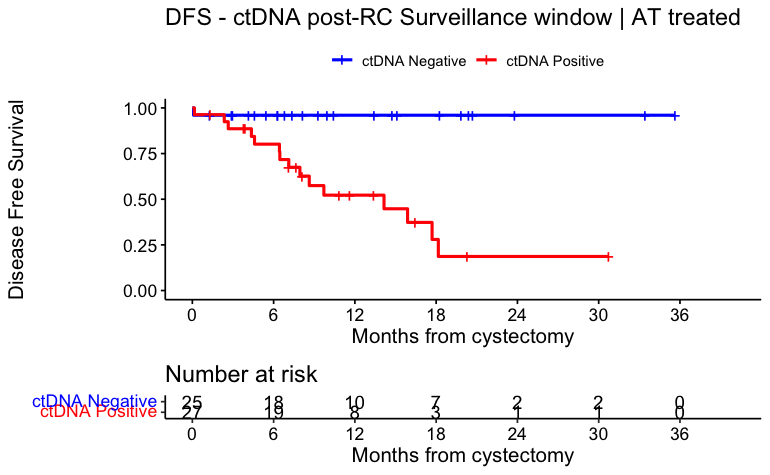

```r
surv_object <-Surv(time = circ_data$RFS_months, event = circ_data$RecStatus)
KM_curve <- survfit(surv_object ~ MRD.Surveillance.Window, data = circ_data,conf.int=0.95,conf.type="log-log")
ggsurvplot(KM_curve, data = circ_data, pval = FALSE, conf.int = FALSE, risk.table = TRUE, break.time.by=6, palette=c("blue","red"), title="DFS - ctDNA post-RC Surveillance window | AT treated", ylab= "Disease Free Survival", xlab="Months from cystectomy", legend.labs=c("ctDNA Negative", "ctDNA Positive"), legend.title="")
```

```r
summary(KM_curve, times= c(12, 24))
```

```
Call: survfit(formula = surv_object ~ MRD.Surveillance.Window, data = circ_data,
    conf.int = 0.95, conf.type = "log-log")

10 observations deleted due to missingness
                MRD.Surveillance.Window=0
 time n.risk n.event survival std.err lower 95% CI upper 95% CI
   12     10       1     0.96  0.0392        0.748        0.994
   24      2       0     0.96  0.0392        0.748        0.994

                MRD.Surveillance.Window=1
 time n.risk n.event survival std.err lower 95% CI upper 95% CI
   12      8      11    0.522   0.107       0.2997        0.705
   24      1       4    0.187   0.110       0.0352        0.431
```

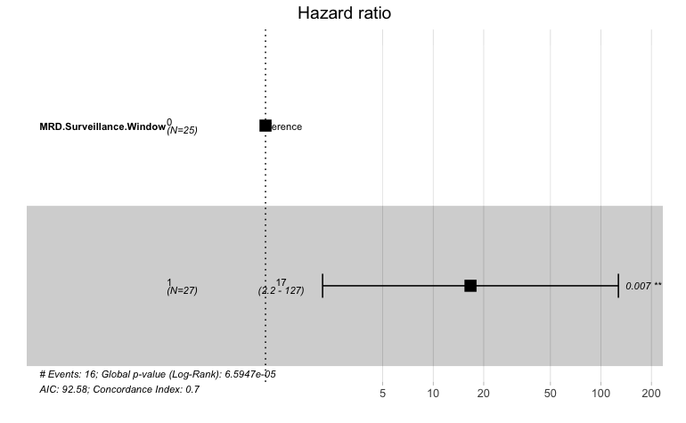

```r
circ_data$MRD.Surveillance.Window <- factor(circ_data$MRD.Surveillance.Window, levels=c("0","1"))
cox_fit <- coxph(surv_object ~ MRD.Surveillance.Window, data=circ_data)
ggforest(cox_fit,data = circ_data)
```

```r
summary(cox_fit)
```

```
Call:
coxph(formula = surv_object ~ MRD.Surveillance.Window, data = circ_data)

  n= 52, number of events= 16
   (10 observations deleted due to missingness)

                           coef exp(coef) se(coef)     z Pr(>|z|)
MRD.Surveillance.Window1  2.814    16.682    1.036 2.716   0.0066 **
---
Signif. codes:  0 ‘***’ 0.001 ‘**’ 0.01 ‘*’ 0.05 ‘.’ 0.1 ‘ ’ 1

                         exp(coef) exp(-coef) lower .95 upper .95
MRD.Surveillance.Window1     16.68    0.05994      2.19     127.1

Concordance= 0.702  (se = 0.061 )
Likelihood ratio test= 15.92  on 1 df,   p=7e-05
Wald test            = 7.38  on 1 df,   p=0.007
Score (logrank) test = 13.45  on 1 df,   p=2e-04
```

```r
cox_fit_summary <- summary(cox_fit)

# Extract values for HR, 95% CI, and p-value
HR <- cox_fit_summary$coefficients[2]
lower_CI <- cox_fit_summary$conf.int[3]
upper_CI <- cox_fit_summary$conf.int[4]
p_value <- cox_fit_summary$coefficients[5]
label_text <- paste0("HR = ", round(HR, 2), " (", round(lower_CI, 2), "-", round(upper_CI, 2), "); p = ", round(p_value, 3))
print(label_text)
```

```
[1] "HR = 16.68 (2.19-127.1); p = 0.007"
```

```r
# Fisher plot for ctDNA at the Surveillance window - >12 weeks & anytime postACT and Rec Status
circ_data$MRD.Surveillance.Window <- factor(circ_data$MRD.Surveillance.Window, levels = c("0", "1"), labels = c("ctDNA(-)", "ctDNA(+)"))
circ_data$RecStatus <- factor(circ_data$RecStatus, levels = c("0", "1"), labels = c("No Recurrence", "Recurrence"))
contingency_table <- table(circ_data$MRD.Surveillance.Window, circ_data$RecStatus)
chi_square_test <- chisq.test(contingency_table)
print(chi_square_test)
```

```
    Pearson's Chi-squared test with Yates' continuity correction

data:  contingency_table
X-squared = 13.867, df = 1, p-value = 0.0001962
```

```r
fisher_exact_test <- fisher.test(contingency_table)
print(fisher_exact_test)
```

```
    Fisher's Exact Test for Count Data

data:  contingency_table
p-value = 5.191e-05
alternative hypothesis: true odds ratio is not equal to 1
95 percent confidence interval:
    3.554035 1303.894421
sample estimates:
odds ratio
  28.08383
```

```r
print(contingency_table)
```

```
           No Recurrence Recurrence
  ctDNA(-)            24          1
  ctDNA(+)            12         15
```

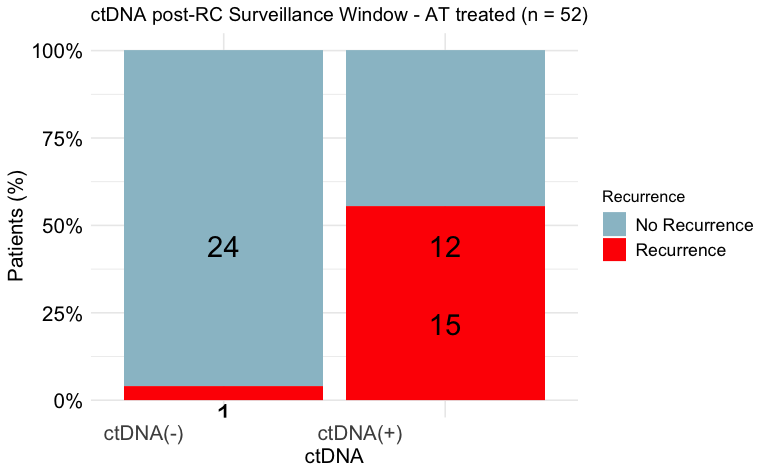

```r
table_df <- as.data.frame(contingency_table)
table_df$Total <- ave(table_df$Freq, table_df$Var1, FUN = sum)
table_df$Percentage <- table_df$Freq / table_df$Total
table_df$MiddlePercentage <- table_df$Percentage / 2
ggplot(table_df, aes(x = Var1, y = Percentage, fill = Var2)) +
  geom_bar(stat = "identity") +
  geom_text(aes(y = MiddlePercentage, label = Freq), position = "stack", color = "black", vjust = 1.5, size = 7) +
  theme_minimal() +
  labs(title = "ctDNA post-RC Surveillance Window - AT treated (n = 52)", x = "ctDNA", y = "Patients (%)", fill = "Recurrence") +
  scale_y_continuous(labels = scales::percent_format()) +
  scale_fill_manual(values = c("No Recurrence" = "lightblue3", "Recurrence" = "red")) + # define custom colors
  theme(axis.text.x = element_text(angle = 0, hjust = 1.5, size = 14), # increase x-axis text size
        axis.text.y = element_text(size = 14, color = "black"), # increase y-axis text size
        axis.title.x = element_text(size = 14, color = "black"), # increase x-axis label size
        axis.title.y = element_text(size = 14, color = "black"), # increase y-axis label size
        legend.text = element_text(size = 12, color = "black"))  # increase Recurrence label size
```

#Time-dependent cox regression analysis for surveillance window - AT treated

```r
rm(list=ls())
setwd("~/Downloads")
dt <- read_xlsx("RWE_MIBC Time Dependent Data.xlsx") |>
  clean_names() |>
  mutate(window_start_date = surveillance_1_date) |>
  mutate(across(.cols = c(window_start_date, dfs_date,
                          surveillance_1_date:surveillance_12_date),
                .fns = ~ as_date(as.Date(.x, format = "%Y-%m-%d")))) |>
  filter(at == TRUE)

dt_biomarker <- dt |>
  select(pts_id, ct_dna_surveillance_available,
         window_start_date,
         surveillance_1_status:surveillance_12_date) |>
  filter(ct_dna_surveillance_available) |>
  pivot_longer(cols = surveillance_1_status:surveillance_12_date,
               names_to = c("visit_number", ".value"),
               names_pattern = "surveillance_(.)_(.*)") |>
  mutate(biomarker_time = day(days(date - window_start_date))) |>
  select(pts_id, biomarker_time, biomarker_status = status) |>
  filter(!is.na(biomarker_time))

glimpse(dt_biomarker)
```

```
Rows: 111
Columns: 3
$ pts_id           <dbl> 13, 19, 26, 26, 26, 30, 30, 30, 30, 31, 31, 31, 31, 31, 31, 31, 31, 31, 32, 39, 39, 40, 40, 41, 41, 41, 44, 44, 44, 44, 44, 48, …
$ biomarker_time   <dbl> 0, 0, 0, 51, 77, 0, 35, 62, 77, 0, 45, 81, 126, 159, 206, 272, 315, 346, 0, 0, 28, 0, 113, 0, 60, 78, 0, 48, 84, 133, 175, 0, 0,…
$ biomarker_status <chr> "NEGATIVE", "POSITIVE", "POSITIVE", "POSITIVE", "POSITIVE", "POSITIVE", "POSITIVE", "POSITIVE", "POSITIVE", "POSITIVE", "POSITIV…
```

```r
dt_survival <- dt |>
  select(pts_id, ct_dna_surveillance_available,
         window_start_date:dfs_date) |>
  filter(ct_dna_surveillance_available) |>
  mutate(dfs_time = (dfs_date - window_start_date),
         dfs_time = day(days(dfs_time)),
         dfs_event = as.numeric(dfs_event)) |>
  select(pts_id, dfs_time, dfs_event)

glimpse(dt_survival)
```

```
Rows: 45
Columns: 3
$ pts_id    <dbl> 13, 19, 26, 30, 31, 32, 39, 40, 41, 44, 48, 65, 78, 84, 86, 88, 92, 93, 119, 125, 128, 135, 136, 137, 145, 150, 155, 156, 157, 158, 162…
$ dfs_time  <dbl> 168, 10, 204, 125, 522, 30, 417, 155, 95, 175, 273, 16, 165, 115, 44, 77, 24, 182, 109, 254, -67, 248, -14, 42, 39, 57, 249, 204, 218, …
$ dfs_event <dbl> 0, 0, 0, 0, 1, 0, 0, 1, 1, 0, 0, 0, 0, 0, 0, 1, 0, 0, 1, 0, 1, 1, 1, 0, 0, 0, 0, 1, 0, 0, 0, 0, 1, 0, 0, 0, 1, 0, 1, 0, 1, 1, 0, 0, 0
```

```r
aux <- dt_survival %>%
  filter(dfs_time <= 0)

tab <- left_join(aux, dt) |>
  select(pts_id, window_start_date, dfs_time, dfs_date,
         surveillance_1_date:surveillance_12_date) |>
  mutate(across(.cols = dfs_date:surveillance_12_date,
                .fns = ~ as_date(.x))) |>
  select(pts_id, window_start_date, dfs_date, dfs_time)
datatable(tab, filter = "top")
```

|  | pts_id | window_start_date | dfs_date | dfs_time |
| --- | --- | --- | --- | --- |
| 1 | 128 | 2022-07-26 | 2022-05-20 | -67 |
| 2 | 136 | 2022-12-27 | 2022-12-13 | -14 |

```r
dt_survival <- dt_survival |>
  filter(dfs_time > 0)

aux <- dt |>
  select(pts_id, ct_dna_surveillance_available,
         window_start_date, dfs_date,
         surveillance_1_date:surveillance_12_date) |>
  mutate(across(.cols = surveillance_1_date:surveillance_12_date,
                .fns = ~ .x - window_start_date)) |>
  mutate(across(.cols = surveillance_1_date:surveillance_12_date,
                .fns = ~ .x < 0)) |>
  rowwise() |>
   mutate(sum_neg =
           sum(c_across(surveillance_1_date:surveillance_12_date),
               na.rm = TRUE))  |>
  select(pts_id, sum_neg)

tab <- left_join(aux, dt) |>
  filter(sum_neg > 0) |>
  select(pts_id, sum_neg, window_start_date,
         surveillance_1_date:surveillance_12_date) |>
  mutate(across(.cols = window_start_date:surveillance_12_date,
                .fns = ~ as_date(.x)))
datatable(tab, filter = "top")
```

|  | pts_id | sum_neg | window_start_date | surveillance_1_date | surveillance_2_date | surveillance_3_date | surveillance_4_date | surveillance_5_date | surveillance_6_date | surveillance_7_date | surveillance_8_date | surveillance_9_date | surveillance_10_date | surveillance_11_date | surveillance_12_date |
| --- | --- | --- | --- | --- | --- | --- | --- | --- | --- | --- | --- | --- | --- | --- | --- |

```r
aux <- dt |>
  select(pts_id, ct_dna_surveillance_available,
         window_start_date, dfs_date,
         surveillance_1_date:surveillance_12_date) |>
  mutate(across(.cols = dfs_date:surveillance_12_date,
                .fns = ~ .x - window_start_date)) |>
  mutate(across(.cols = surveillance_2_date:surveillance_12_date,
                .fns = ~ dfs_date < .x)) |>
  rowwise() |>
  mutate(n_biomarker_after_event = sum(c_across(surveillance_2_date:
                              surveillance_12_date),
                   na.rm = TRUE)) |>
  mutate(across(.cols = surveillance_1_date:surveillance_12_date,
                .fns = ~ !is.na(.x))) |>
  mutate(total_biomarker = sum(c_across(surveillance_2_date:
                              surveillance_12_date),
                   na.rm = TRUE)) |>
  select(pts_id, n_biomarker_after_event, total_biomarker)

temp <- aux |>
  select(-pts_id) |>
  group_by(n_biomarker_after_event, total_biomarker) |>
  dplyr::summarize(freq = n())
tab <- left_join(aux, dt) |>
  select(pts_id, n_biomarker_after_event, total_biomarker,
         dfs_date,
         surveillance_2_date:surveillance_12_date) |>
  mutate(across(.cols = dfs_date:surveillance_12_date,
                .fns = ~ as_date(.x))) |>
  filter(n_biomarker_after_event > 0)
datatable(tab, filter = "top")
```

|  | pts_id | n_biomarker_after_event | total_biomarker | dfs_date | surveillance_2_date | surveillance_3_date | surveillance_4_date | surveillance_5_date | surveillance_6_date | surveillance_7_date | surveillance_8_date | surveillance_9_date | surveillance_10_date | surveillance_11_date | surveillance_12_date |
| --- | --- | --- | --- | --- | --- | --- | --- | --- | --- | --- | --- | --- | --- | --- | --- |
| 1 | 88 | 1 | 1 | 2022-08-02 | 2022-08-09 |  |  |  |  |  |  |  |  |  |  |
| 2 | 135 | 1 | 5 | 2023-01-06 | 2022-06-09 | 2022-09-15 | 2022-10-14 | 2022-12-15 | 2023-02-24 |  |  |  |  |  |  |
| 3 | 156 | 1 | 3 | 2023-02-01 | 2022-10-08 | 2022-11-29 | 2023-02-07 |  |  |  |  |  |  |  |  |
| 4 | 168 | 2 | 2 | 2022-08-02 | 2022-08-09 | 2022-11-10 |  |  |  |  |  |  |  |  |  |
| 5 | 188 | 1 | 2 | 2022-07-12 | 2022-04-18 | 2022-07-19 |  |  |  |  |  |  |  |  |  |
| 6 | 189 | 1 | 3 | 2022-12-01 | 2022-07-28 | 2022-10-27 | 2023-02-09 |  |  |  |  |  |  |  |  |

```r
aux <- tmerge(data1 = dt_survival,
              data2 = dt_survival,
              id = pts_id,
              dfs_event = event(dfs_time, dfs_event))
dt_final <- tmerge(data1 = aux,
                   data2 = dt_biomarker,
                   id = pts_id,
                   biomarker_status =
                     tdc(biomarker_time, biomarker_status))

datatable(dt_final, filter = "top")
```

|  | pts_id | dfs_time | dfs_event | tstart | tstop | biomarker_status |
| --- | --- | --- | --- | --- | --- | --- |
| 1 | 13 | 168 | 0 | 0 | 168 | NEGATIVE |
| 2 | 19 | 10 | 0 | 0 | 10 | POSITIVE |
| 3 | 26 | 204 | 0 | 0 | 51 | POSITIVE |
| 4 | 26 | 204 | 0 | 51 | 77 | POSITIVE |
| 5 | 26 | 204 | 0 | 77 | 204 | POSITIVE |
| 6 | 30 | 125 | 0 | 0 | 35 | POSITIVE |
| 7 | 30 | 125 | 0 | 35 | 62 | POSITIVE |
| 8 | 30 | 125 | 0 | 62 | 77 | POSITIVE |
| 9 | 30 | 125 | 0 | 77 | 125 | POSITIVE |
| 10 | 31 | 522 | 0 | 0 | 45 | POSITIVE |

[output cut: 85 more lines]

```r
# Syntax if there is not time-dependent covariate
# fit <- coxph(Surv(dfs_time, dfs_event) ~ biomarker_status,
#              data = dt_final)
# summary(fit)

fit <- coxph(Surv(tstart, tstop, dfs_event) ~ biomarker_status,
             data = dt_final)
summary(fit)
```

```
Call:
coxph(formula = Surv(tstart, tstop, dfs_event) ~ biomarker_status,
    data = dt_final)

  n= 95, number of events= 12

                           coef exp(coef) se(coef)     z Pr(>|z|)
biomarker_statusPOSITIVE 1.5278    4.6079   0.6831 2.236   0.0253 *
---
Signif. codes:  0 ‘***’ 0.001 ‘**’ 0.01 ‘*’ 0.05 ‘.’ 0.1 ‘ ’ 1

                         exp(coef) exp(-coef) lower .95 upper .95
biomarker_statusPOSITIVE     4.608      0.217     1.208     17.58

Concordance= 0.658  (se = 0.081 )
Likelihood ratio test= 5.79  on 1 df,   p=0.02
Wald test            = 5  on 1 df,   p=0.03
Score (logrank) test = 5.99  on 1 df,   p=0.01
```

#Heatmap with clinical and genomic factors - VH Cohort

```r
rm(list=ls())
setwd("~/Downloads")
circ_data <- read.csv("RWE_MIBC Combined.csv")
circ_data <- circ_data[circ_data$ctDNA.Available=="TRUE",]
circ_data <- circ_data[circ_data$histology_subtype=="VH",]
circ_data <- circ_data[circ_data$FU_months>=3,]
circ_data <- circ_data %>% arrange(cStage.Group)
circ_datadf <- as.data.frame(circ_data)

ha <- HeatmapAnnotation(
  cStage.Group = circ_data$cStage.Group,
  Gender = circ_data$Gender,
  Age.Group = circ_data$Age.Group,
  NAC = circ_data$NAC,
  NAC.Details = circ_data$NAC.Details,
  pStage.Group = circ_data$pStage.Group,
  TNM.Detailed = circ_data$TNM.Detailed,
  pN.Group = circ_data$pN.Group,
  ACT.Details = circ_data$ACT.Details,
  MSI.status = circ_data$MSI.status,
  TMB.status = circ_data$TMB.status,
  Urothelial = circ_data$Urothelial,
  Squamous = circ_data$Squamous,
  Adenocarcinoma = circ_data$Adenocarcinoma,
  Lipoid = circ_data$Lipoid,
  Sarcomatoid = circ_data$Sarcomatoid,
  GiantCell = circ_data$GiantCell,
  Nested = circ_data$Nested,
  Micropapillary = circ_data$Micropapillary,
  Neuroendocrine = circ_data$Neuroendocrine,
  Plasmacytoid = circ_data$Plasmacytoid,
  Mucinous = circ_data$Mucinous,
  Microcystic = circ_data$Microcystic,
  Glandular = circ_data$Glandular,
  ClearCell = circ_data$ClearCell,
  TP53 = circ_data$TP53,
  ARID1A = circ_data$ARID1A,
  KDM6A = circ_data$KDM6A,
  ERBB2 = circ_data$ERBB2,
  PIK3CA = circ_data$PIK3CA,
  RB1 = circ_data$RB1,
  RYR2 = circ_data$RYR2,
  ANK2 = circ_data$ANK2,
  ERCC2 = circ_data$ERCC2,
  AKAP9 = circ_data$AKAP9,
  CREBBP = circ_data$CREBBP,
  MUC4 = circ_data$MUC4,
  KIAA2026 = circ_data$KIAA2026,
  NSD1 = circ_data$NSD1,
  ZNF469 = circ_data$ZNF469,
  APC2 = circ_data$APC2,
  COL6A5 = circ_data$COL6A5,
  DMD = circ_data$DMD,
  DNAH14 = circ_data$DNAH14,
  EP300 = circ_data$EP300,
  FSIP2 = circ_data$FSIP2,
  MYCBP2 = circ_data$MYCBP2,
  SPTAN1 = circ_data$SPTAN1,
  DYNC1H1 = circ_data$DYNC1H1,
  ZFHX4 = circ_data$ZFHX4,
  MRD_anytimepreSx = circ_data$MRD_anytimepreSx,
  MRD_postSx.MRD.Window = circ_data$MRD_postSx.MRD.Window,
  MRD.Surveillance.Window = circ_data$MRD.Surveillance.Window,
  MRD_anytimeSx = circ_data$MRD_anytimeSx,
  RecStatus = circ_data$RecStatus,
  VitalStatus = circ_data$VitalStatus,

  col = list(cStage.Group = c("1" = "seagreen1", "2" = "khaki", "3" = "orange", "4" = "purple"),
             Gender = c("Female" = "goldenrod" , "Male" = "blue4"),
             Age.Group = c("1" = "#C1211A", "0" ="#008BCE"),
             NAC = c("1" = "darkmagenta", "0" = "gray"),
             NAC.Details = c("ChemoRT" = "coral", "Chemo" ="darkgreen", "ChemoIO" = "yellow3"),
             pStage.Group = c("1" = "seagreen2", "2" = "cornflowerblue", "3" ="darkmagenta"),
             TNM.Detailed = c("Tis/T1N0M0" = "lightblue", "T2-T4N0M0" ="orange", "TxN1/N2M0/M1" = "brown" ),
             pN.Group = c("0" = "yellow", "1" ="brown"),
             ACT.Details = c("Surveillance" = "lightblue", "Chemo" = "orange2", "IO" ="khaki", "ChemoIO" = "brown2"),
             MSI.status = c("MSS" = "grey", "MSI-Hi" ="black"),
             TMB.status = c("TMB-Low" = "darkgreen", "TMB-High" ="darkmagenta"),
             Urothelial = c("FALSE" = "grey", "TRUE" ="black"),
             Squamous = c("FALSE" = "grey", "TRUE" ="black"),
             Adenocarcinoma = c("FALSE" = "grey", "TRUE" ="black"),
             Lipoid = c("FALSE" = "grey", "TRUE" ="black"),
             Sarcomatoid = c("FALSE" = "grey", "TRUE" ="black"),
             GiantCell = c("FALSE" = "grey", "TRUE" ="black"),
             Nested = c("FALSE" = "grey", "TRUE" ="black"),
             Micropapillary = c("FALSE" = "grey", "TRUE" ="black"),
             Neuroendocrine = c("FALSE" = "grey", "TRUE" ="black"),
             Plasmacytoid = c("FALSE" = "grey", "TRUE" ="black"),
             Mucinous = c("FALSE" = "grey", "TRUE" ="black"),
             Microcystic = c("FALSE" = "grey", "TRUE" ="black"),
             Glandular = c("FALSE" = "grey", "TRUE" ="black"),
             ClearCell = c("FALSE" = "grey", "TRUE" ="black"),
             TP53 = c("WT" = "grey", "Mut" ="black"),
             ARID1A = c("WT" = "grey", "Mut" ="black"),
             KDM6A = c("WT" = "grey", "Mut" ="black"),
             ERBB2 = c("WT" = "grey", "Mut" ="black"),
             PIK3CA = c("WT" = "grey", "Mut" ="black"),
             RB1 = c("WT" = "grey", "Mut" ="black"),
             RYR2 = c("WT" = "grey", "Mut" ="black"),
             ANK2 = c("WT" = "grey", "Mut" ="black"),
             ERCC2 = c("WT" = "grey", "Mut" ="black"),
             AKAP9 = c("WT" = "grey", "Mut" ="black"),
             CREBBP = c("WT" = "grey", "Mut" ="black"),
             MUC4 = c("WT" = "grey", "Mut" ="black"),
             KIAA2026 = c("WT" = "grey", "Mut" ="black"),
             NSD1 = c("WT" = "grey", "Mut" ="black"),
             ZNF469 = c("WT" = "grey", "Mut" ="black"),
             APC2 = c("WT" = "grey", "Mut" ="black"),
             COL6A5 = c("WT" = "grey", "Mut" ="black"),
             DMD = c("WT" = "grey", "Mut" ="black"),
             DNAH14 = c("WT" = "grey", "Mut" ="black"),
             EP300 = c("WT" = "grey", "Mut" ="black"),
             FSIP2 = c("WT" = "grey", "Mut" ="black"),
             MYCBP2 = c("WT" = "grey", "Mut" ="black"),
             SPTAN1 = c("WT" = "grey", "Mut" ="black"),
             DYNC1H1 = c("WT" = "grey", "Mut" ="black"),
             ZFHX4 = c("WT" = "grey", "Mut" ="black"),
             MRD_anytimepreSx = c("1" = "red3", "0" ="blue"),
             MRD_postSx.MRD.Window = c("1" = "red3", "0" ="blue"),
             MRD.Surveillance.Window = c("1" = "red3", "0" ="blue"),
             MRD_anytimeSx = c("1" = "red3", "0" ="blue"),
             RecStatus = c("1" = "red3", "0" ="blue"),
             VitalStatus = c("1" = "black", "0" ="grey")
  )
)
ht <- Heatmap(matrix(nrow = 0, ncol = length(circ_data$Gender)),show_row_names = FALSE,cluster_rows = F,cluster_columns = FALSE, top_annotation = ha)
pdf("heatmap.pdf",width = 7, height = 7)
draw(ht, annotation_legend_side = "bottom")
dev.off()
```

#DFS by ctDNA at the MRD window - VH Cohort

```r
rm(list=ls())
setwd("~/Downloads")
circ_data <- read.csv("RWE_MIBC Combined.csv")
circ_data <- circ_data[circ_data$ctDNA.Available=="TRUE",]
circ_data <- circ_data[circ_data$histology_subtype=="VH",]
circ_data <- circ_data[circ_data$FU_months>=3,]
circ_datadf <- as.data.frame(circ_data)

survfit(Surv(time = circ_data$RFS_months, event = circ_data$RecStatus)~MRD_postSx.MRD.Window, data = circ_data)
```

```
Call: survfit(formula = Surv(time = circ_data$RFS_months, event = circ_data$RecStatus) ~
    MRD_postSx.MRD.Window, data = circ_data)

   17 observations deleted due to missingness
                         n events median 0.95LCL 0.95UCL
MRD_postSx.MRD.Window=0 20      3     NA   10.12      NA
MRD_postSx.MRD.Window=1  9      5   10.9    3.15      NA
```

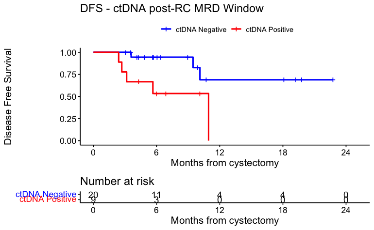

```r
surv_object <-Surv(time = circ_data$RFS_months, event = circ_data$RecStatus)
KM_curve <- survfit(surv_object ~ MRD_postSx.MRD.Window, data = circ_data,conf.int=0.95,conf.type="log-log")
ggsurvplot(KM_curve, data = circ_data, pval = FALSE, conf.int = FALSE, risk.table = TRUE, break.time.by=6, palette=c("blue","red"), title="DFS - ctDNA post-RC MRD Window", ylab= "Disease Free Survival", xlab="Months from cystectomy", legend.labs=c("ctDNA Negative", "ctDNA Positive"), legend.title="")
```

```r
summary(KM_curve, times= c(0, 12))
```

```
Call: survfit(formula = surv_object ~ MRD_postSx.MRD.Window, data = circ_data,
    conf.int = 0.95, conf.type = "log-log")

17 observations deleted due to missingness
                MRD_postSx.MRD.Window=0
 time n.risk n.event survival std.err lower 95% CI upper 95% CI
    0     20       0    1.000   0.000         1.00        1.000
   12      4       3    0.689   0.161         0.28        0.896

                MRD_postSx.MRD.Window=1
        time       n.risk      n.event     survival      std.err lower 95% CI upper 95% CI
           0            9            0            1            0            1            1
```

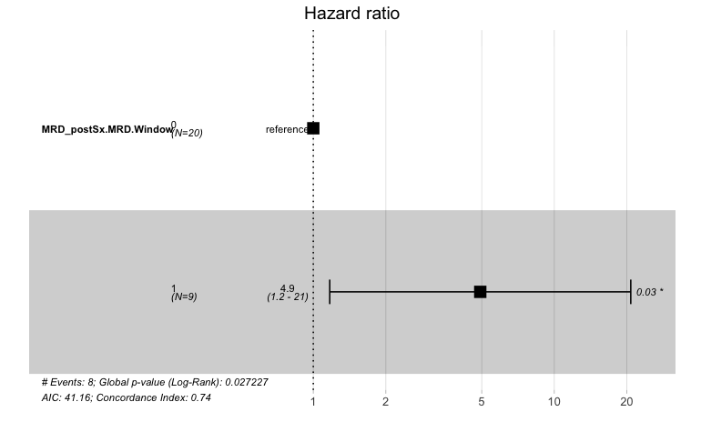

```r
circ_data$MRD_postSx.MRD.Window <- factor(circ_data$MRD_postSx.MRD.Window, levels=c("0","1"))
cox_fit <- coxph(surv_object ~ MRD_postSx.MRD.Window, data=circ_data)
ggforest(cox_fit,data = circ_data)
```

```r
summary(cox_fit)
```

```
Call:
coxph(formula = surv_object ~ MRD_postSx.MRD.Window, data = circ_data)

  n= 29, number of events= 8
   (17 observations deleted due to missingness)

                         coef exp(coef) se(coef)     z Pr(>|z|)
MRD_postSx.MRD.Window1 1.5953    4.9300   0.7337 2.174   0.0297 *
---
Signif. codes:  0 ‘***’ 0.001 ‘**’ 0.01 ‘*’ 0.05 ‘.’ 0.1 ‘ ’ 1

                       exp(coef) exp(-coef) lower .95 upper .95
MRD_postSx.MRD.Window1      4.93     0.2028      1.17     20.77

Concordance= 0.736  (se = 0.082 )
Likelihood ratio test= 4.88  on 1 df,   p=0.03
Wald test            = 4.73  on 1 df,   p=0.03
Score (logrank) test = 5.79  on 1 df,   p=0.02
```

```r
cox_fit_summary <- summary(cox_fit)

# Extract values for HR, 95% CI, and p-value
HR <- cox_fit_summary$coefficients[2]
lower_CI <- cox_fit_summary$conf.int[3]
upper_CI <- cox_fit_summary$conf.int[4]
p_value <- cox_fit_summary$coefficients[5]
label_text <- paste0("HR = ", round(HR, 2), " (", round(lower_CI, 2), "-", round(upper_CI, 2), "); p = ", round(p_value, 3))
print(label_text)
```

```
[1] "HR = 4.93 (1.17-20.77); p = 0.03"
```

```r
# Fisher plot for ctDNA at the MRD Window (1-12 weeks post-RC) and Rec Status
circ_data$MRD_postSx.MRD.Window <- factor(circ_data$MRD_postSx.MRD.Window, levels = c("0", "1"), labels = c("ctDNA(-)", "ctDNA(+)"))
circ_data$RecStatus <- factor(circ_data$RecStatus, levels = c("0", "1"), labels = c("No Recurrence", "Recurrence"))
contingency_table <- table(circ_data$MRD_postSx.MRD.Window, circ_data$RecStatus)
chi_square_test <- chisq.test(contingency_table)
print(chi_square_test)
```

```
    Pearson's Chi-squared test with Yates' continuity correction

data:  contingency_table
X-squared = 3.2819, df = 1, p-value = 0.07005
```

```r
fisher_exact_test <- fisher.test(contingency_table)
print(fisher_exact_test)
```

```
    Fisher's Exact Test for Count Data

data:  contingency_table
p-value = 0.0667
alternative hypothesis: true odds ratio is not equal to 1
95 percent confidence interval:
  0.8624077 62.5051555
sample estimates:
odds ratio
  6.505452
```

```r
print(contingency_table)
```

```
           No Recurrence Recurrence
  ctDNA(-)            17          3
  ctDNA(+)             4          5
```

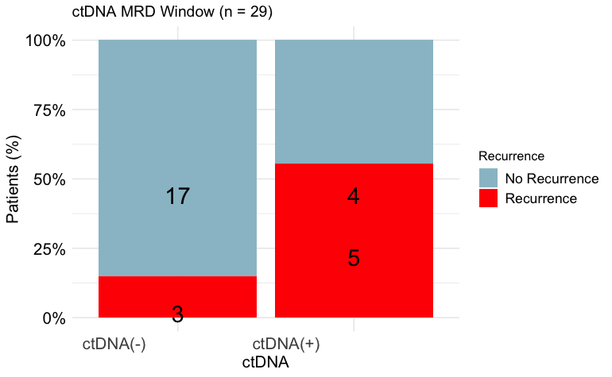

```r
table_df <- as.data.frame(contingency_table)
table_df$Total <- ave(table_df$Freq, table_df$Var1, FUN = sum)
table_df$Percentage <- table_df$Freq / table_df$Total
table_df$MiddlePercentage <- table_df$Percentage / 2
ggplot(table_df, aes(x = Var1, y = Percentage, fill = Var2)) +
  geom_bar(stat = "identity") +
  geom_text(aes(y = MiddlePercentage, label = Freq), position = "stack", color = "black", vjust = 1.5, size = 7) +
  theme_minimal() +
  labs(title = "ctDNA MRD Window (n = 29)", x = "ctDNA", y = "Patients (%)", fill = "Recurrence") +
  scale_y_continuous(labels = scales::percent_format()) +
  scale_fill_manual(values = c("No Recurrence" = "lightblue3", "Recurrence" = "red")) + # define custom colors
  theme(axis.text.x = element_text(angle = 0, hjust = 1.5, size = 14), # increase x-axis text size
        axis.text.y = element_text(size = 14, color = "black"), # increase y-axis text size
        axis.title.x = element_text(size = 14, color = "black"), # increase x-axis label size
        axis.title.y = element_text(size = 14, color = "black"), # increase y-axis label size
        legend.text = element_text(size = 12, color = "black"))  # increase Recurrence label size
```

#DFS by ctDNA at the Surveillance window - VH Cohort

```r
rm(list=ls())
setwd("~/Downloads")
circ_data <- read.csv("RWE_MIBC Combined.csv")
circ_data <- circ_data[circ_data$ctDNA.Available=="TRUE",]
circ_data <- circ_data[circ_data$histology_subtype=="VH",]
circ_data <- subset(circ_data, !is.na(MRD.Surveillance.Window))
circ_data <- circ_data[circ_data$FU_months>=3,]
circ_datadf <- as.data.frame(circ_data)

survfit(Surv(time = circ_data$RFS_months, event = circ_data$RecStatus)~MRD.Surveillance.Window, data = circ_data)
```

```
Call: survfit(formula = Surv(time = circ_data$RFS_months, event = circ_data$RecStatus) ~
    MRD.Surveillance.Window, data = circ_data)

                           n events median 0.95LCL 0.95UCL
MRD.Surveillance.Window=0 15      0     NA      NA      NA
MRD.Surveillance.Window=1 14      9   10.1    5.65      NA
```

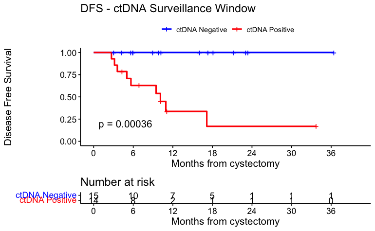

```r
surv_object <-Surv(time = circ_data$RFS_months, event = circ_data$RecStatus)
KM_curve <- survfit(surv_object ~ MRD.Surveillance.Window, data = circ_data,conf.int=0.95,conf.type="log-log")
ggsurvplot(KM_curve, data = circ_data, pval = TRUE, conf.int = FALSE, risk.table = TRUE, break.time.by=6, palette=c("blue","red"), title="DFS - ctDNA Surveillance Window", ylab= "Disease Free Survival", xlab="Months from cystectomy", legend.labs=c("ctDNA Negative", "ctDNA Positive"), legend.title="")
```

```r
summary(KM_curve, times= c(24))
```

```
Call: survfit(formula = surv_object ~ MRD.Surveillance.Window, data = circ_data,
    conf.int = 0.95, conf.type = "log-log")

                MRD.Surveillance.Window=0
        time       n.risk      n.event     survival      std.err lower 95% CI upper 95% CI
          24            1            0            1            0           NA           NA

                MRD.Surveillance.Window=1
        time       n.risk      n.event     survival      std.err lower 95% CI upper 95% CI
     24.0000       1.0000       9.0000       0.1684       0.1393       0.0119       0.4883
```

```r
circ_data$MRD.Surveillance.Window <- factor(circ_data$MRD.Surveillance.Window, levels=c("0","1"))
cox_fit <- coxphf(surv_object ~ MRD.Surveillance.Window, data=circ_data)
summary(cox_fit)
```

```
coxphf(formula = surv_object ~ MRD.Surveillance.Window, data = circ_data)

Model fitted by Penalized ML
Confidence intervals and p-values by Profile Likelihood

                             coef se(coef) exp(coef) lower 0.95 upper 0.95    Chisq           p
MRD.Surveillance.Window1 3.341255 1.542865  28.25456   3.518522   3659.935 13.42118 0.000248799

Likelihood ratio test=13.42118 on 1 df, p=0.000248799, n=29
Wald test = 4.689897 on 1 df, p = 0.03034047

Covariance-Matrix:
                         MRD.Surveillance.Window1
MRD.Surveillance.Window1                 2.380433
```

```r
# Fisher plot for ctDNA at the MRD Window (1-12 weeks post-RC) and Rec Status
circ_data$MRD.Surveillance.Window <- factor(circ_data$MRD.Surveillance.Window, levels = c("0", "1"), labels = c("ctDNA(-)", "ctDNA(+)"))
circ_data$RecStatus <- factor(circ_data$RecStatus, levels = c("0", "1"), labels = c("No Recurrence", "Recurrence"))
contingency_table <- table(circ_data$MRD.Surveillance.Window, circ_data$RecStatus)
chi_square_test <- chisq.test(contingency_table)
print(chi_square_test)
```

```
    Pearson's Chi-squared test with Yates' continuity correction

data:  contingency_table
X-squared = 11.14, df = 1, p-value = 0.0008449
```

```r
fisher_exact_test <- fisher.test(contingency_table)
print(fisher_exact_test)
```

```
    Fisher's Exact Test for Count Data

data:  contingency_table
p-value = 0.0001999
alternative hypothesis: true odds ratio is not equal to 1
95 percent confidence interval:
 3.821613      Inf
sample estimates:
odds ratio
       Inf
```

```r
print(contingency_table)
```

```
           No Recurrence Recurrence
  ctDNA(-)            15          0
  ctDNA(+)             5          9
```

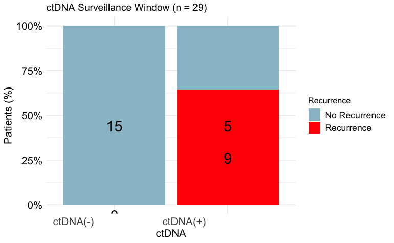

```r
table_df <- as.data.frame(contingency_table)
table_df$Total <- ave(table_df$Freq, table_df$Var1, FUN = sum)
table_df$Percentage <- table_df$Freq / table_df$Total
table_df$MiddlePercentage <- table_df$Percentage / 2
ggplot(table_df, aes(x = Var1, y = Percentage, fill = Var2)) +
  geom_bar(stat = "identity") +
  geom_text(aes(y = MiddlePercentage, label = Freq), position = "stack", color = "black", vjust = 1.5, size = 7) +
  theme_minimal() +
  labs(title = "ctDNA Surveillance Window (n = 29)", x = "ctDNA", y = "Patients (%)", fill = "Recurrence") +
  scale_y_continuous(labels = scales::percent_format()) +
  scale_fill_manual(values = c("No Recurrence" = "lightblue3", "Recurrence" = "red")) + # define custom colors
  theme(axis.text.x = element_text(angle = 0, hjust = 1.5, size = 14), # increase x-axis text size
        axis.text.y = element_text(size = 14, color = "black"), # increase y-axis text size
        axis.title.x = element_text(size = 14, color = "black"), # increase x-axis label size
        axis.title.y = element_text(size = 14, color = "black"), # increase y-axis label size
        legend.text = element_text(size = 12, color = "black"))  # increase Recurrence label size
```